# Statistical Analysis to accompany:

High-density lipoprotein carries markers that track with recovery from stroke

Plubell D.L., et al., Circulation Research 2020

1/12/2020

**Updated June 5, 2020 by DLP**

# Outline

- **Abstract**
- **Demographic information**
  - *Table 1.* Non-stroke v Stroke demographics
- **HDL protein differential abundance testing**
  - Shapiro-Wilk test for normality of each protein
  - *Table 2.* Significant changes
  - *Figure 2.* Significantly changing HDL protein abundance distributions
  - *Figure 3.* Paired significantly changing HDL protein abundances
- **Correlation testing**
  - *Figure 4.* Correlation plot of all patient measures
- **Stroke recovery linear regression analysis**
  - *Table 3.* HDL protein logFC from 24h to 96 h post stroke with significant correlation with stroke recovery
- **Cholesterol efflux capacity analysis**
  - *Table 4.* Cholesterol efflux analysis
  - *Figure 5.* Cholesterol efflux distribution plot
- **Supplemental figures/tables**
  - *Supplemental Figure 1.* Effect of normalization on N15 APOA1 spike-in variance distribution
  - *Supplemental Table 4.* Correlation results matrices
  - *Supplemental Figure 4.* Plots of HDL protein logFC correlation with stroke recovery
  - *Supplemental Table 5.* Linear regression statistics for HDL protein logFC and stroke recovery
  - *Supplemental Figure 5.* Plots of plasma lipid level correlation with stroke recovery
  - *Supplemental Table 6.* Linear regression statistics for plasma lipid levels and stroke recovery
  - *Supplemental Table 7.* Linear regression statistics for plasma lipid levels and HDL protein logFC
  - *Supplemental Figure 6.* CEC distributions of stroke tPA status
  - *Supplemental Table 8.* T-test statistics for plasma lipid levels by stroke tPA status
- **Additional info for reviewers**

# 1. Abstract

### Workspace set-up & Dataframe import

```r
#Packages used in this analysis:
library(ggplot2, quietly = TRUE)
library(RColorBrewer, quietly = TRUE)
library(dplyr, quietly = TRUE)
library(grid, quietly = TRUE)
library(gridExtra, quietly = TRUE)
library(pheatmap, quietly = TRUE)
library(psych, quietly = TRUE)
library(Hmisc, quietly = TRUE)
library(corrplot, quietly = TRUE)
library(mclust, quietly = TRUE)
library(purrr, quietly = TRUE)
library(tidyr, quietly = TRUE)
library(plyr, quietly = TRUE)
library(Gmisc, quietly = TRUE)
library(magrittr, quietly = TRUE)
library(limma, quietly = TRUE)
library(scales, quietly=TRUE)
library(stargazer, quietly = TRUE)
library(knitr, quietly = TRUE)
library(kableExtra, quietly = TRUE)
library(statmod, quietly = TRUE)
library(xlsx, quietly=TRUE)
```

```r
#First read in the 'metadata' stored in supplemental Table 1, sheet 2
#Since the read.xlsx has issues with determining the class of each column they are specified
m <- as.data.frame(read.xlsx2("SupplementalTable_1.xlsx", 2, header=TRUE,
                  colClasses =  c("Sample_no."="numeric", "Sex"="character",
                                        "Age_blood"="numeric","Group"="character",
                                        "Stroke"="numeric", "Pair"="character",
                                        "Pair_ID"="character", "Ischemic_Type"="character",
                                        "tPa"="character", "Thrombectomy"="character",
                                        "TICIB."="character", "Hour"="numeric",
                                        "Cholesterol"="numeric", "Triglycerides"="numeric",
                                        "HDLC"="numeric", "LDLC"="numeric", "Statin"="character",
                                        "NIHSS_baseline"="numeric", "NIHSS_3mo"="numeric",
                                        "mRS"="numeric", "CEC"="numeric")))

#Now read in the protein assay data, stored in supplemental Table 1, sheet 3
p <- read.xlsx2("SupplementalTable_1.xlsx", 3, header=TRUE,
                colClasses = c("numeric", "character", "character", "numeric", "numeric",
                               "numeric", "numeric", "numeric", "numeric", "numeric",
                               "numeric", "numeric", "numeric", "numeric", "numeric",
                               "numeric", "numeric", "numeric", "numeric", "numeric",
                               "numeric", "numeric", "numeric", "numeric", "numeric",
                               "numeric", "numeric", "numeric", "numeric", "numeric",
                               "numeric", "numeric", "numeric", "numeric", "numeric",
                               "numeric", "numeric", "numeric", "numeric", "numeric",
                               "numeric", "numeric", "numeric", "numeric"))

#for data wrangling I choose to combine everything into one large table
all <- as.data.frame(cbind(m, p))

#This removes a redundant column that appeared in both tables
#It also removes a sample that is a 96 hour sample with no paired 24 hour
#The 24 hour sample that corresponds was not analyzed by mass spec due to sample handling issues
all <- all[-1,-22]
#3 proteins analyzed by mass spec assay had to high of variance in system suitability replicates
#For specifics; see supplemental Figure 1.
#Therefore, I also remove these so they don't have a chance of being included in any analysis.
all$HP <- NULL
all$GC <- NULL
all$SAA4 <- NULL
```

# 2. Demographic information

## Table 1: Non-stroke v Stroke sample demographics

Because the some of the demographic statistics are only applicable to certain groups, multiple tables are generated here and then compiled/merged into Table 1 in excel for the final manuscript table (for ease of formatting).

```r
#Creating subsets of the metadata for the
meta_all <- as.data.frame(all[1:23])

#metadata dataframe for the 24h stroke samples
meta24 <- select(filter(meta_all, Group=="S24"), c(Sex, Hour, Age_blood, Group,
                              Cholesterol, Triglycerides, HDLC, LDLC, Statin,
                              NIHSS_baseline, NIHSS_3mo, mRS, CEC, Ischemic_Type,
                              tPa, Thrombectomy, TICI2B))

#metadata dataframe for the non-stroke 'control' samples
metaC <- select(filter(meta_all, Group=="C"), c(Sex, Hour, Age_blood, Group,
                               Cholesterol, Triglycerides, HDLC, LDLC, Statin,
                               NIHSS_baseline, NIHSS_3mo, mRS, CEC, Ischemic_Type,
                               tPa, Thrombectomy, TICI2B))

#metadata dataframe for the 96h stroke samples
meta96 <- select(filter(meta_all, Group=="S96"), c(Sex, Hour, Age_blood, Group,
                              Cholesterol, Triglycerides, HDLC, LDLC, Statin,
                              NIHSS_baseline, NIHSS_3mo, mRS, CEC, Ischemic_Type,
                              tPa, Thrombectomy, TICI2B))

#metadata dataframe for both the 24h and 96h stroke samples
meta_stroke <- rbind(meta24, meta96)

#metadata dataframe for both the 24h and control samples
meta <- rbind(meta24, metaC)
```

### Non-stroke control vs. 24 hr statistics

```r
#Function to write out statistics: number of samples in each category & (percent of total) -or- mean & (sd)
getTable1Stats <- function(x, digits = 2, ...){
  getDescriptionStatsBy(x = x,
                        by = meta$Group,
                        digits = digits,
                        continuous_fn = describeMean,
                        header_count = TRUE,
                        #statistics = TRUE,
                        ...)

}

#generating lists for each category of interest
t1 <- list()

t1[["Sex"]] <- getTable1Stats(meta$Sex)
t1[["Statin"]] <- getTable1Stats(meta$Statin)
t1[["Age"]] <- getTable1Stats(meta$Age_blood)
t1[["Cholesterol"]] <- getTable1Stats(meta$Cholesterol)
t1[["HDLC"]] <- getTable1Stats(meta$HDLC)
t1[["LDLC"]] <- getTable1Stats(meta$LDLC)
t1[["Triglycerides"]] <- getTable1Stats(meta$Triglycerides)

#merging statistics into a output table
mergeDesc(t1,
          htmlTable_args = list(css.rgroup=""))
```

|  | C No. 35 | S24 No. 35 | S96 No. 0 |
| --- | --- | --- | --- |
| Sex |  |  |  |
| FEMALE | 26 (74.29%) | 14 (40.00%) | - |
| MALE | 8 (22.86%) | 21 (60.00%) | - |
| NA | 1 (2.86%) | 0 (0.00%) | - |
| Statin |  |  |  |
| NA | 4 (11.43%) | 0 (0.00%) | - |
| No | 25 (71.43%) | 25 (71.43%) | - |
| Yes | 6 (17.14%) | 10 (28.57%) | - |
| Age |  |  |  |
| Mean (SD) | 63.93 (±3.42) | 68.20 (±10.51) | - |
| Missing | 4 (11.43%) | 0 (0%) | - |
| Cholesterol | 208.34 (±43.98) | 148.83 (±40.54) |  |
| HDLC | 63.86 (±20.92) | 43.09 (±15.99) |  |
| LDLC | 169.26 (±52.22) | 128.43 (±49.47) |  |
| Triglycerides | 123.89 (±86.49) | 113.46 (±80.64) |  |

### Stroke 24 hr vs. 96 hr stroke related statistics

```r
#Function to write out statistics: number of samples in each category & (percent of total) -or- mean & (sd)
#This time for just stroke samples
getTable1Stats <- function(x, digits = 2, ...){
  getDescriptionStatsBy(x = x,
                        by = meta_stroke$Group,
                        digits = digits,
                        continuous_fn = describeMedian,
                        header_count = TRUE,
                        #statistics = TRUE,
                        ...)
}

#generating lists for each category of interest
t2 <- list()

t2[["Ischemic Type"]] <- getTable1Stats(meta_stroke$Ischemic_Type)
t2[["tPA"]] <- getTable1Stats(meta_stroke$tPa)
t2[["Thrombectomy"]] <- getTable1Stats(meta_stroke$Thrombectomy)
t2[["TICI2B"]] <- getTable1Stats(meta_stroke$TICI2B)
t2[["NIHSS-baseline"]] <- getTable1Stats(meta_stroke$NIHSS_baseline)
t2[["NIHSS-3mo"]] <- getTable1Stats(meta_stroke$NIHSS_3mo)
t2[["mRS"]] <- getTable1Stats(meta_stroke$mRS)

#merging statistics into a output table
mergeDesc(t2,
          htmlTable_args = list(css.rgroup=""))
```

|  | C No. 0 | S24 No. 35 | S96 No. 20 |
| --- | --- | --- | --- |
| Ischemic Type |  |  |  |
| CE | - | 8 (22.86%) | 4 (20.00%) |
| LV | - | 22 (62.86%) | 14 (70.00%) |
| NA | - | 0 (0.00%) | 0 (0.00%) |
| SV | - | 5 (14.29%) | 2 (10.00%) |
| tPA |  |  |  |
| NA | - | 0 (0.00%) | 0 (0.00%) |
| No | - | 19 (54.29%) | 11 (55.00%) |
| Yes | - | 16 (45.71%) | 9 (45.00%) |
| Thrombectomy |  |  |  |
| NA | - | 0 (0.00%) | 0 (0.00%) |
| No | - | 20 (57.14%) | 12 (60.00%) |
| Yes | - | 15 (42.86%) | 8 (40.00%) |
| TICI2B |  |  |  |
| NA | - | 20 (57.14%) | 12 (60.00%) |
| No | - | 5 (14.29%) | 5 (25.00%) |
| Yes | - | 10 (28.57%) | 3 (15.00%) |
| NIHSS-baseline |  | 15.00 (9.00 - 20.00) | 17.00 (12.25 - 20.00) |
| NIHSS-3mo |  |  |  |
| Median (IQR) | - | 6.00 (1.00 - 13.00) | ( - ) |
| Missing | - | 2 (5.71%) | 20 (100.00%) |
| mRS |  |  |  |
| Median (IQR) | - | 3.00 (2.00 - 4.00) | ( - ) |
| Missing | - | 0 (0%) | 20 (100.00%) |

### All 3 groups

```r
#Function to write out statistics: number of samples in each category
# & (percent of total) -or- mean & (sd)

#This time for statistics applicable to all 3 groups: specifically for lipid measures
getTable1Stats <- function(x, digits = 2, ...){
  getDescriptionStatsBy(x = x,
                        by = meta_all$Group,
                        digits = digits,
                        continuous_fn = describeMean,
                        header_count = TRUE,
                        #statistics = TRUE,
                        ...)

}

#generating lists for each category of interest
t3 <- list()

t3[["Cholesterol"]] <- getTable1Stats(meta_all$Cholesterol)
t3[["HDLC"]] <- getTable1Stats(meta_all$HDLC)
t3[["LDLC"]] <- getTable1Stats(meta_all$LDLC)
t3[["Triglycerides"]] <- getTable1Stats(meta_all$Triglycerides)

#merging statistics into a output table
mergeDesc(t3,
          htmlTable_args = list(css.rgroup=""))
```

|  | C No. 35 | S24 No. 35 | S96 No. 20 |
| --- | --- | --- | --- |
| Cholesterol | 208.34 (±43.98) | 148.83 (±40.54) | 140.65 (±40.83) |
| HDLC | 63.86 (±20.92) | 43.09 (±15.99) | 38.80 (±9.30) |
| LDLC | 169.26 (±52.22) | 128.43 (±49.47) | 124.84 (±55.22) |
| Triglycerides | 123.89 (±86.49) | 113.46 (±80.64) | 114.95 (±75.76) |

# 3. HDL protein differential abundance testing

```r
#Since there are 3 groups, and 2 of the groups are paired,
#this makes data a bit more complicated to handle, so I just generated
#new dataframes instead of having to wrangle the data with other methods.

## Paired stroke sample dataframe generation
PS24 <- all %>% filter(Pair=="Yes" & Group=="S24") %>% droplevels()
PS24rownames <- PS24[,1]
rownames(PS24) <- PS24rownames

PS96 <- all %>% filter(Pair=="Yes" & Group=="S96") %>% droplevels()
PS96rownames <- PS96[,1]
rownames(PS96) <- PS96rownames

paired <- rbind(PS24, PS96)

#The next 3 sets are all the 24h vs all the 96h measures,
#all the control vs all the 24h measures, and all the control
# vs all the 96 h measures.
C <- all %>% filter(Group=="C") %>% droplevels()
Crownames <- C[,1]
rownames(C) <- Crownames

S24 <- all %>% filter(Group=="S24") %>% droplevels()
S24rownames <- S24[,1]
rownames(S24) <- S24rownames

#dataframes for significance testing
CvS24 <- rbind(C,S24)
CvS96 <- rbind(C,PS96)
all <- rbind(C,S24,PS96)


#log2 transforming the paired stroke dataframe
logP <- as.data.frame(cbind(paired[,1:23], log2(paired[,24:ncol(paired)])))

#log2 transforming the control & stroke dataframe
logAll <- as.data.frame(cbind(all[,1:23], log2(all[,24:ncol(all)])))

#log2 transforming the control & stroke dataframe
logCvS24 <- as.data.frame(cbind(CvS24[,1:23], log2(CvS24[,24:ncol(CvS24)])))

#log2 transforming the control & stroke dataframe
logCvS96 <- as.data.frame(cbind(CvS96[,1:23], log2(CvS96[,24:ncol(CvS96)])))
```

## Shapiro-Wilk test for normality of each protein

A caveat to targeted mass spectrometry measurements is that the data isn’t necessarily normally distributed - in part due to fundamentally how the measurements are made. However, within the proteomics community it is standard to use parametric tests for differential abundance testing. In this assay we observe several cases in which there are outlier low abundance measurments below the otherwise fairly normal distribution. This is due to integrating the same transition ions across all samples, including ones lacking of signal. In that case we are likely integrating background noise. Another cause of these outlier measurements could be due to them falling below the limit of quantification or limit of detection. In that case we are integrating the actual signal, but it is lower than expected for a true linear scale.

**Shapiro Wilk statistics for non-stroke control and 24 h post stroke samples**

```r
#Shapiro-Wilk test
#perform the test for each protein measure
p_swnorm <- lapply(logCvS24[, 24:length(logCvS24)],
                   function(x) shapiro.test(x))
#retrieve the W statistic
results_w <- ldply(p_swnorm, function(x) x$statistic)
#retrieve the p-value
results_p <- ldply(p_swnorm, function(x) x$p.value)

#Report the mean and median p-value, the number and
#percent with p-values greater than 0.05:
mean_pC24 <- format(mean(results_p$V1), digits=3, format="f")
median_pC24 <- format(median(results_p$V1), digits=2, format="f")
count_C24 <- with(results_p, sum(V1>0.05))
count_tC24 <- length(results_p$V1)
pct_normC24 <- format((count_C24/count_tC24*100),
                      digits=3, format="f")

#Making a table of the statistics
results_swnorm <- data.frame(cbind("protein" = results_w$.id,
                                   "W" = results_w$W,
                                   "Pvalue" = results_p$V1))
kable(results_swnorm) %>%
  kable_styling() %>%
  scroll_box(width = "75%", height = "300px")
```

| protein | W | Pvalue |
| --- | --- | --- |
| SERPINA1 | 0.972916707058013 | 0.133213707321529 |
| ALB | 0.850998646299485 | 7.20893480131045e-07 |
| AMBP | 0.935325757522222 | 0.00133132452005188 |
| ANTXR2 | 0.968807268942514 | 0.0780177614688162 |
| APMAP | 0.970876723864567 | 0.102175968800515 |
| LPA | 0.986633591994339 | 0.754438162438065 |
| APOA1 | 0.966861793121548 | 0.0605587049879609 |
| APOA2 | 0.878748650952478 | 6.18471908299661e-06 |
| APOA4 | 0.975551405489702 | 0.187064049284491 |
| APOB | 0.978181468611017 | 0.260674565194396 |
| APOC3 | 0.98108244092458 | 0.370316247905908 |
| APOC4 | 0.983055292095996 | 0.463542070367344 |
| APOD | 0.974707805204013 | 0.167889885291914 |
| APOE | 0.908991700425532 | 8.94663404061348e-05 |
| APOF | 0.980089463682507 | 0.329148277379397 |
| APOL1 | 0.967959550511187 | 0.0698589503975613 |
| APOM | 0.881243067503217 | 7.60003254224941e-06 |
| CAMP | 0.993093618705489 | 0.968573463845914 |
| CLU | 0.989880898377397 | 0.848393987787419 |
| C3 | 0.970298332186325 | 0.0947575551367428 |
| PPBP | 0.953739023140204 | 0.0114355859957422 |
| AHSG | 0.952059647667699 | 0.00930820804575936 |
| FGA | 0.952760309878095 | 0.0108997857304548 |
| HPR | 0.989913504133544 | 0.850036073390094 |
| IHH | 0.95268120820667 | 0.0100427940148696 |
| ITIH4 | 0.917645644716561 | 0.000231324115819709 |
| LCAT | 0.825334655916189 | 1.20397926228046e-07 |
| SELL | 0.883536601747945 | 9.20459626007136e-06 |
| PCYOX1 | 0.899356235480224 | 3.65616811799498e-05 |
| GPLD1 | 0.93379876957411 | 0.00112543571708825 |
| PF4 | 0.978244955701556 | 0.262736950904108 |
| PLTP | 0.974814373525079 | 0.170205061759006 |
| PON1 | 0.99022206835699 | 0.865236511357912 |
| PON3 | 0.694357614558252 | 8.76703025795617e-11 |
| RBP4 | 0.9892816275195 | 0.817122683724782 |
| SAA1 | 0.964670825272416 | 0.053904162082101 |
| SAA2 | 0.981337845022924 | 0.391332926963427 |
| TTR | 0.982366809236247 | 0.429312975758955 |

For the control and 24 h post stroke protein measures **60.5** percent had p-values above 0.05; the mean p-value was **0.231** and median p-value was **0.086**. 4 of the 8 proteins found to be significantly different below are normally distributed.

**Shapiro Wilk statistics for non-stroke control and 96 h post stroke samples**

```r
#Shapiro-Wilk test
p_swnorm <- lapply(logCvS96[, 24:length(logCvS96)],
                   function(x) shapiro.test(x))
results_w <- ldply(p_swnorm, function(x) x$statistic)
results_p <- ldply(p_swnorm, function(x) x$p.value)

#Report the mean and median p-value:
mean_pC96 <-format(mean(results_p$V1), digits=3, format="f")
median_pC96 <-format(median(results_p$V1), digits=2, format="f")
count_C96 <- with(results_p, sum(V1>0.05))
count_tC96 <- length(results_p$V1)
pct_normC96 <- format((count_C96/count_tC96*100),
                      digits=3, format="f")

#Making a table of the statistics
results_swnorm <- data.frame(cbind("protein" = results_w$.id,
                                   "W" = results_w$W,
                                   "Pvalue" = results_p$V1))
kable(results_swnorm) %>%
  kable_styling() %>%
  scroll_box(width = "75%", height = "300px")
```

| protein | W | Pvalue |
| --- | --- | --- |
| SERPINA1 | 0.984569033978003 | 0.700515710229085 |
| ALB | 0.871162761777608 | 2.84499807010518e-05 |
| AMBP | 0.93671351307853 | 0.00619621123103363 |
| ANTXR2 | 0.927106673932437 | 0.00252479404643427 |
| APMAP | 0.972724793226624 | 0.243314936794797 |
| LPA | 0.958085649210766 | 0.0739063838904789 |
| APOA1 | 0.959592435332756 | 0.0619525845983186 |
| APOA2 | 0.86368113016257 | 1.68896163332746e-05 |
| APOA4 | 0.982913932682701 | 0.62072221785666 |
| APOB | 0.981518073624968 | 0.555260493891661 |
| APOC3 | 0.961330687256626 | 0.074329019460728 |
| APOC4 | 0.961942123589978 | 0.0792540877486649 |
| APOD | 0.965623627914927 | 0.116646508331159 |
| APOE | 0.887365349950404 | 9.30858666368004e-05 |
| APOF | 0.984419975519016 | 0.69331456484689 |
| APOL1 | 0.975032829468435 | 0.306406531222257 |
| APOM | 0.823234368960334 | 1.27812028164465e-06 |
| CAMP | 0.986072595420624 | 0.772088716124038 |
| CLU | 0.98459415894536 | 0.701728730219006 |
| C3 | 0.9890985235947 | 0.898150407006441 |
| PPBP | 0.958160040054358 | 0.0533403825228751 |
| AHSG | 0.955062780596469 | 0.0386603198961599 |
| FGA | 0.977701834853351 | 0.40822626697194 |
| HPR | 0.968838333279901 | 0.16320729244716 |
| IHH | 0.914715259525487 | 0.000843152168996652 |
| ITIH4 | 0.960008912913546 | 0.0647131502391475 |
| LCAT | 0.760527327694844 | 4.28442460929897e-08 |
| SELL | 0.852223677580451 | 7.82121161608235e-06 |
| PCYOX1 | 0.880961327104868 | 5.77062895861446e-05 |
| GPLD1 | 0.94776037086204 | 0.0183371995372958 |
| PF4 | 0.984287981376001 | 0.6869328981246 |
| PLTP | 0.964039450481194 | 0.0987791476894501 |
| PON1 | 0.977416291459016 | 0.385568189874355 |
| PON3 | 0.6561175382853 | 4.37289426496688e-10 |
| RBP4 | 0.983148600814531 | 0.631955541742189 |
| SAA1 | 0.965448914989642 | 0.127703761482916 |
| SAA2 | 0.945152322014669 | 0.0153750163536789 |
| TTR | 0.987523323617749 | 0.836862065642754 |

For the control and 96 h post stroke protein measures **63.2** percent had p-values above 0.05; the mean p-value was **0.248** and median p-value was **0.077**. 7 of the 12 proteins found to be significantly different below are normally distributed.

**Shapiro Wilk statistics for paired 24 h and 96 h post stroke samples**

```r
#Shapiro-Wilk test
p_swnorm <- lapply(logP[, 24:length(logP)], function(x) shapiro.test(x))
results_w <- ldply(p_swnorm, function(x) x$statistic)
results_p <- ldply(p_swnorm, function(x) x$p.value)

#Report the mean and median p-value:
mean_pP <- format(mean(results_p$V1), digits=3, format="f")
median_pP <- format(median(results_p$V1), digits=2, format="f")
count_P <- with(results_p, sum(V1>0.05))
count_tP <- length(results_p$V1)
pct_normP <- format((count_P/count_tP*100),
                    digits=3, format="f")

#Making a table of the statistics
results_swnorm <- data.frame(cbind("protein" = results_w$.id,
                                   "W" = results_w$W,
                                   "Pvalue" = results_p$V1))
kable(results_swnorm) %>%
  kable_styling() %>%
  scroll_box(width = "75%", height = "300px")
```

| protein | W | Pvalue |
| --- | --- | --- |
| SERPINA1 | 0.985655513950479 | 0.88376669169845 |
| ALB | 0.949061016965588 | 0.0703965238725716 |
| AMBP | 0.982412442338416 | 0.777891065788042 |
| ANTXR2 | 0.96655309054376 | 0.278409430775947 |
| APMAP | 0.959042522622838 | 0.155320204347786 |
| LPA | 0.940227246166859 | 0.0759866958040728 |
| APOA1 | 0.968803404779125 | 0.329607125325641 |
| APOA2 | 0.976725030224524 | 0.569638934504142 |
| APOA4 | 0.968927408519029 | 0.332646645258803 |
| APOB | 0.976097830529137 | 0.547559021580809 |
| APOC3 | 0.957266586049406 | 0.134968937619974 |
| APOC4 | 0.98079990785719 | 0.719205168560376 |
| APOD | 0.984753422457826 | 0.856715992878622 |
| APOE | 0.976028923939916 | 0.545158543686624 |
| APOF | 0.981214248622732 | 0.734471449922815 |
| APOL1 | 0.97123883036428 | 0.39360169618946 |
| APOM | 0.975304793085344 | 0.520260704319982 |
| CAMP | 0.97374234269091 | 0.468796289112221 |
| CLU | 0.978875404955038 | 0.647826880807906 |
| C3 | 0.985385394309606 | 0.875907501723648 |
| PPBP | 0.885772968681251 | 0.000756180407918371 |
| AHSG | 0.974321924173145 | 0.487505257011207 |
| FGA | 0.96743073088793 | 0.297496085411599 |
| HPR | 0.975527191264103 | 0.527841772832523 |
| IHH | 0.929742693542839 | 0.0157975660341636 |
| ITIH4 | 0.97324920002216 | 0.469560997793684 |
| LCAT | 0.957805133731255 | 0.140848283987468 |
| SELL | 0.970892131760639 | 0.383935845603567 |
| PCYOX1 | 0.972378698303703 | 0.426676164534604 |
| GPLD1 | 0.812850330118147 | 1.26950046085226e-05 |
| PF4 | 0.921514171825052 | 0.00859613598806194 |
| PLTP | 0.97124661299873 | 0.393820792204484 |
| PON1 | 0.978280053178659 | 0.625883973267704 |
| PON3 | 0.978203202747782 | 0.623064232675991 |
| RBP4 | 0.966044304244947 | 0.267844802456448 |
| SAA1 | 0.874501048733442 | 0.00062049961633631 |
| SAA2 | 0.93071060539253 | 0.0169902946526589 |
| TTR | 0.974311722550804 | 0.487171947719173 |

## Table 2. Significant HDL protein abundance changes

### Paired t test for 24h - 96 h paired samples

```r
#Since a paired t.test will not accomodate missing values, several proteins will be removed from this analysis
non_missing <- as.data.frame(select(logP, -"LPA", -"ITIH4", -"SAA1"))

p_t.test <- lapply(non_missing[, 24:length(non_missing)],
                   function(x) t.test(x ~ non_missing$Group, paired = TRUE))
results_p_t.test <- ldply(p_t.test, function(x) x$p.value)

results_p_t.test$adj.P.Val <- p.adjust(results_p_t.test$V1,
                                       method="BH")
results_p_t.test <-rename(results_p_t.test, c(".id"= "Protein",
                                              "V1"="P.Value"))

count_pair <- with(results_p_t.test, sum(adj.P.Val<0.05))

#write.csv(results_p_t.test, file="paired_ttest.csv")

kable(results_p_t.test,
      caption="Paired t-test statistics for 24 h and 96 h post stroke samples") %>%
  kable_styling() %>%
  scroll_box(width = "75%", height = "300px")
```

Paired t-test statistics for 24 h and 96 h post stroke samples

| Protein | P.Value | adj.P.Val |
| --- | --- | --- |
| SERPINA1 | 0.0232465 | 0.1627257 |
| ALB | 0.3853037 | 0.6714833 |
| AMBP | 0.2534772 | 0.5849641 |
| ANTXR2 | 0.0005329 | 0.0149537 |
| APMAP | 0.5340493 | 0.7499932 |
| APOA1 | 0.9566294 | 0.9626844 |
| APOA2 | 0.3369339 | 0.6551493 |
| APOA4 | 0.6299003 | 0.8479427 |
| APOB | 0.8505786 | 0.9540000 |
| APOC3 | 0.4837164 | 0.7370082 |
| APOC4 | 0.4843197 | 0.7370082 |
| APOD | 0.3341036 | 0.6551493 |
| APOE | 0.5357094 | 0.7499932 |
| APOF | 0.0008545 | 0.0149537 |
| APOL1 | 0.1962744 | 0.5569666 |
| APOM | 0.9626844 | 0.9626844 |
| CAMP | 0.1863001 | 0.5569666 |
| CLU | 0.8722285 | 0.9540000 |
| C3 | 0.0296958 | 0.1732254 |
| PPBP | 0.0221582 | 0.1627257 |
| AHSG | 0.8170512 | 0.9540000 |
| FGA | 0.2674122 | 0.5849641 |
| HPR | 0.8613524 | 0.9540000 |
| IHH | 0.1788193 | 0.5569666 |
| LCAT | 0.0625167 | 0.2735107 |
| SELL | 0.6616746 | 0.8577263 |
| PCYOX1 | 0.2563235 | 0.5849641 |
| GPLD1 | 0.9499223 | 0.9626844 |
| PF4 | 0.0771167 | 0.2998981 |
| PLTP | 0.2068733 | 0.5569666 |
| PON1 | 0.0348365 | 0.1741825 |
| PON3 | 0.3667914 | 0.6714833 |
| RBP4 | 0.4028900 | 0.6714833 |
| SAA2 | 0.0027379 | 0.0319420 |
| TTR | 0.7591141 | 0.9488926 |

From paired t.test analysis 3 proteins are significantly different between the two time points.

### Extra: Paired Wilcoxon ranked sum test for 24h - 96 h paired samples

At least one of the significantly changing proteins (SAA2) is non-normally distributed by the Shapiro-Wilk test, so the paired measurements are also assessed by wilcoxon signed rank test.

```r
wilcox <- lapply(non_missing[, 24:length(non_missing)],
                   function(x) pairwise.wilcox.test(x, non_missing$Group,
                                          p.adjust ="BH", paired = TRUE))

results_wilcox <- ldply(wilcox, function(x) x$p.value)
results_wilcox$adj.P.Val <- p.adjust(results_wilcox$S24, method="BH")
names(results_wilcox)[1] <- "protein"
names(results_wilcox)[2] <- "p.value"

count_pair <- with(results_wilcox, sum(adj.P.Val<0.05))

kable(results_wilcox,
      caption="Wilcox Paired t-test statistics for 24 h and 96 h post stroke samples") %>%
  kable_styling() %>%
  scroll_box(width = "75%", height = "300px")
```

Wilcox Paired t-test statistics for 24 h and 96 h post stroke samples

| protein | p.value | adj.P.Val |
| --- | --- | --- |
| SERPINA1 | 0.0362339 | 0.1585233 |
| ALB | 0.6215134 | 0.8853039 |
| AMBP | 0.2773552 | 0.5710254 |
| ANTXR2 | 0.0007076 | 0.0211620 |
| APMAP | 0.7561665 | 0.8853039 |
| APOA1 | 0.9854355 | 0.9854355 |
| APOA2 | 0.2773552 | 0.5710254 |
| APOA4 | 0.6742229 | 0.8853039 |
| APOB | 0.6476555 | 0.8853039 |
| APOC3 | 0.2454872 | 0.5710254 |
| APOC4 | 0.7561665 | 0.8853039 |
| APOD | 0.1230927 | 0.3590202 |
| APOE | 0.3117943 | 0.5743579 |
| APOF | 0.0012093 | 0.0211620 |
| APOL1 | 0.2610989 | 0.5710254 |
| APOM | 0.8694878 | 0.9221840 |
| CAMP | 0.2942524 | 0.5721574 |
| CLU | 0.7841263 | 0.8853039 |
| C3 | 0.0327682 | 0.1585233 |
| PPBP | 0.0214844 | 0.1585233 |
| AHSG | 0.8123550 | 0.8885133 |
| FGA | 0.4523754 | 0.7196882 |
| HPR | 0.7285061 | 0.8853039 |
| IHH | 0.0758514 | 0.2654800 |
| LCAT | 0.0582581 | 0.2265591 |
| SELL | 0.7841263 | 0.8853039 |
| PCYOX1 | 0.2305126 | 0.5710254 |
| GPLD1 | 0.9563293 | 0.9844567 |
| PF4 | 0.0362339 | 0.1585233 |
| PLTP | 0.1230927 | 0.3590202 |
| PON1 | 0.0239506 | 0.1585233 |
| PON3 | 0.4523754 | 0.7196882 |
| RBP4 | 0.4090977 | 0.7159209 |
| SAA2 | 0.0031528 | 0.0367832 |
| TTR | 0.7561665 | 0.8853039 |

Again, we find the same 3 proteins to be significantly different (adj. p-value <0.05) by paired Wilcoxon.

### Linear model for each protein

#### Model: ~0 + Group + Sex + HDLC

**Linear model statistics for 24h vs non-stroke control protein differences**

```r
all1 <- all
rownames(all1) <- all1$ID

#Removing sample that has NA indicated for sex
all1 <- all1[-9,]
all_mat <- as.matrix(log2(all1[, 24:length(all1)]))
rownames(all_mat) <- all1$ID
tmat <- t(all_mat)

meta <- as.data.frame(all1[, 1:23])
rownames(meta) <- all1$ID

#Model for finding differences due to group with sex and HDLC covariates
design <- model.matrix(~0 + Group + Sex + HDLC, data = meta)
fit <- lmFit(tmat, design = design)

#GroupS24 - GroupS96 contrast not made by linear model due to their paired nature.
contrasts <- makeContrasts(GroupS24 - GroupC, GroupS96 - GroupC,
                           levels = design)
fit1 <- contrasts.fit(fit, contrasts)
fit1 <- eBayes(fit1,robust = TRUE,trend = TRUE)
out1 <- lapply(1:ncol(contrasts), function(x) topTable(fit1, coef = x,
                                                       n= Inf,
                                                       adjust = "BH",
                                                       sort.by = "p")[,-c(3,6)])

#Number of significant differences
num <- sapply(out1,function(x) sum(x$adj.P<0.05))

# C vs S24 results
S24vC <- out1[[1]]
count_24vC <- with(S24vC, sum(adj.P.Val<0.05))
#write.csv(S24vC, file="S24vC.csv")

# C vs S96 results
S96vC <- out1[[2]]
count_96vC <- with(S96vC, sum(adj.P.Val<0.05))
#write.csv(S96vC, file="S96vC.csv")

#Table of the C v 24 h post stroke results
kable(S24vC, caption="Model: ~0 + Group + Sex + HDLC") %>%
  kable_styling() %>%
  scroll_box(width = "100%", height = "300px")
```

Model: ~0 + Group + Sex + HDLC

|  | logFC | AveExpr | P.Value | adj.P.Val |
| --- | --- | --- | --- | --- |
| APMAP | 1.6105734 | 21.52132 | 0.0000000 | 0.0000000 |
| GPLD1 | 1.4695627 | 20.78969 | 0.0000000 | 0.0000001 |
| APOE | 0.7574868 | 28.56741 | 0.0000277 | 0.0003511 |
| IHH | -0.5885446 | 23.13573 | 0.0001068 | 0.0010148 |
| ITIH4 | -1.1210225 | 19.79977 | 0.0003313 | 0.0025176 |
| SAA2 | 2.4818640 | 22.92835 | 0.0015677 | 0.0099288 |
| APOA4 | -0.5554768 | 23.61617 | 0.0051057 | 0.0277169 |
| CLU | 0.3581448 | 24.67599 | 0.0087013 | 0.0413312 |
| SELL | 0.6404597 | 20.50256 | 0.0122721 | 0.0518156 |
| APOA2 | 0.3195771 | 26.52012 | 0.0408526 | 0.1552399 |
| PLTP | 0.2862072 | 24.35341 | 0.0560477 | 0.1936194 |
| FGA | 0.4327166 | 21.77589 | 0.0712996 | 0.2257821 |
| SAA1 | 1.5999117 | 25.05205 | 0.0887907 | 0.2532865 |
| APOL1 | -0.2924746 | 26.82370 | 0.0959379 | 0.2532865 |
| PON1 | 0.1537845 | 29.39118 | 0.1053507 | 0.2532865 |
| ANTXR2 | -0.2501451 | 21.78068 | 0.1066470 | 0.2532865 |
| LCAT | -0.2130811 | 23.30947 | 0.1724332 | 0.3854390 |
| PF4 | -0.5020297 | 22.70342 | 0.1910258 | 0.3898493 |
| AHSG | -0.3235295 | 21.36931 | 0.1949247 | 0.3898493 |
| APOA1 | 0.0891988 | 31.85634 | 0.2235050 | 0.4246595 |
| C3 | -0.1656677 | 22.88818 | 0.2610687 | 0.4724100 |
| SERPINA1 | 0.2132191 | 24.90489 | 0.2743829 | 0.4739341 |
| PON3 | 0.2081944 | 24.87372 | 0.3498308 | 0.5779813 |
| APOD | 0.0965410 | 27.91060 | 0.3750950 | 0.5899769 |
| APOC4 | 0.1811179 | 23.87678 | 0.3881427 | 0.5899769 |
| PPBP | -0.2360763 | 23.03815 | 0.5486301 | 0.7649104 |
| CAMP | 0.1068963 | 23.03265 | 0.5698335 | 0.7649104 |
| TTR | -0.0824796 | 21.96019 | 0.5841704 | 0.7649104 |
| RBP4 | -0.0705512 | 23.00858 | 0.6014076 | 0.7649104 |
| APOB | 0.1128546 | 25.43956 | 0.6062686 | 0.7649104 |
| APOF | -0.0615707 | 25.95109 | 0.6240059 | 0.7649104 |
| APOC3 | 0.0584719 | 30.92011 | 0.7000791 | 0.8313440 |
| APOM | 0.0149509 | 29.08623 | 0.9152979 | 0.9692513 |
| PCYOX1 | -0.0105296 | 23.82664 | 0.9346263 | 0.9692513 |
| AMBP | 0.0092695 | 22.86559 | 0.9440157 | 0.9692513 |
| HPR | -0.0159686 | 22.17590 | 0.9557054 | 0.9692513 |
| ALB | 0.0105744 | 26.74184 | 0.9610081 | 0.9692513 |
| LPA | 0.0327929 | 21.34046 | 0.9692513 | 0.9692513 |

For this comparison 8 proteins are significantly different with adjusted P-values<0.05

**Linear model statistics for 96h vs non-stroke control protein differences**

```r
#Table of the C v 96 h post stroke results
kable(S96vC, caption="Model: ~0 + Group + Sex + HDLC") %>%
  kable_styling() %>%
  scroll_box(width = "100%", height = "300px")
```

Model: ~0 + Group + Sex + HDLC

|  | logFC | AveExpr | P.Value | adj.P.Val |
| --- | --- | --- | --- | --- |
| APMAP | 1.8441569 | 21.52132 | 0.0000000 | 0.0000001 |
| GPLD1 | 1.4722726 | 20.78969 | 0.0000002 | 0.0000039 |
| SAA2 | 4.1546373 | 22.92835 | 0.0000111 | 0.0001406 |
| ANTXR2 | -0.8133407 | 21.78068 | 0.0000187 | 0.0001772 |
| IHH | -0.6795287 | 23.13573 | 0.0001296 | 0.0009847 |
| APOE | 0.7305689 | 28.56741 | 0.0004495 | 0.0028470 |
| SERPINA1 | 0.7023154 | 24.90489 | 0.0026366 | 0.0126489 |
| APOA4 | -0.6997240 | 23.61617 | 0.0026629 | 0.0126489 |
| ITIH4 | -1.0304440 | 19.79977 | 0.0042404 | 0.0179038 |
| APOF | 0.4022956 | 25.95109 | 0.0073113 | 0.0277830 |
| CLU | 0.4211697 | 24.67599 | 0.0083838 | 0.0289622 |
| PON1 | 0.2835779 | 29.39118 | 0.0115905 | 0.0367032 |
| SELL | 0.7108245 | 20.50256 | 0.0173352 | 0.0506722 |
| SAA1 | 2.5882092 | 25.05205 | 0.0195461 | 0.0530538 |
| APOD | 0.1870728 | 27.91060 | 0.1434371 | 0.3523334 |
| APOC4 | 0.3563333 | 23.87678 | 0.1483509 | 0.3523334 |
| APOA1 | 0.1165764 | 31.85634 | 0.1744125 | 0.3898633 |
| PLTP | 0.2156339 | 24.35341 | 0.2157742 | 0.4555233 |
| APOA2 | 0.1985329 | 26.52012 | 0.2734324 | 0.5468648 |
| AHSG | -0.2989347 | 21.36931 | 0.3051884 | 0.5690547 |
| AMBP | 0.1558148 | 22.86559 | 0.3144776 | 0.5690547 |
| APOL1 | -0.1737999 | 26.82370 | 0.3950248 | 0.6348584 |
| FGA | 0.2341405 | 21.77589 | 0.3999422 | 0.6348584 |
| PON3 | 0.2138963 | 24.87372 | 0.4114440 | 0.6348584 |
| PF4 | -0.3629883 | 22.70342 | 0.4176700 | 0.6348584 |
| ALB | 0.1926856 | 26.74184 | 0.4472140 | 0.6536204 |
| RBP4 | 0.1153719 | 23.00858 | 0.4656942 | 0.6554215 |
| CAMP | 0.1532364 | 23.03265 | 0.4864937 | 0.6602414 |
| PCYOX1 | -0.0885091 | 23.82664 | 0.5560835 | 0.7286611 |
| LPA | 0.5439231 | 21.34046 | 0.5852301 | 0.7412914 |
| APOB | 0.1190615 | 25.43956 | 0.6420964 | 0.7870860 |
| C3 | 0.0535073 | 22.88818 | 0.7555999 | 0.8972749 |
| APOM | -0.0306988 | 29.08623 | 0.8519550 | 0.9810391 |
| TTR | -0.0201577 | 21.96019 | 0.9089146 | 0.9917259 |
| LCAT | 0.0083315 | 23.30947 | 0.9634383 | 0.9917259 |
| PPBP | -0.0083650 | 23.03815 | 0.9854931 | 0.9917259 |
| HPR | -0.0054109 | 22.17590 | 0.9871668 | 0.9917259 |
| APOC3 | 0.0018411 | 30.92011 | 0.9917259 | 0.9917259 |

For this comparison 12 proteins are significantly different with adjusted P-values<0.05

## Figure 2. Significantly changing HDL protein abundance distributions

The log2 relative intensity is plotted by group for the 8 proteins found to be significantly changing both between the 24 h and 96 h post stroke and non-stroke control.

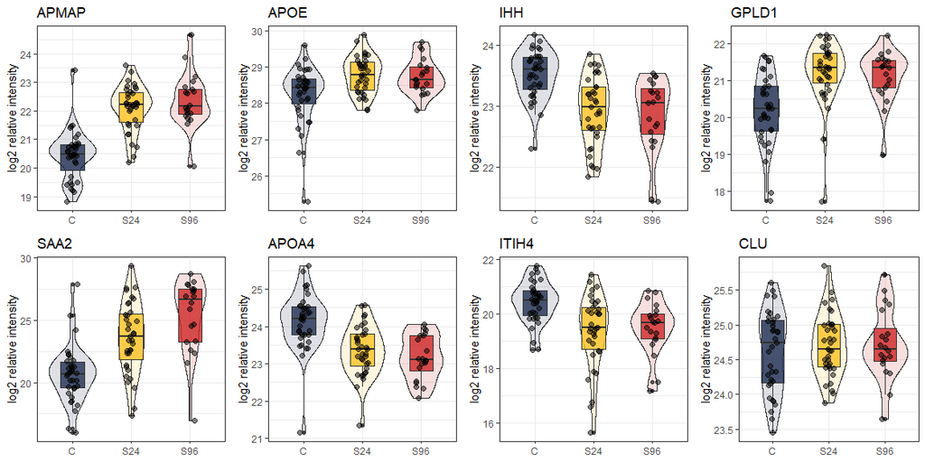

```r
allViolinplot <- function(a, b){
  cols <- c("C"="#202f52", "S24" = "goldenrod1", "S96" = "firebrick3")
  ggplot(a, aes(x = factor(Group), y = b, fill = Group)) +
    geom_violin(alpha=0.15, width=0.8) +
    geom_boxplot(width=0.4, alpha = 0.8) +
    geom_jitter(fill = "black", size = 2, shape = 21,
                position = position_jitter(0.1), alpha=0.5) +
    scale_fill_manual(values=cols) +
    scale_x_discrete(limits=c("C","S24","S96")) +
    labs(y="log2 relative intensity") +
    theme_bw() +
    theme(legend.position = "none", axis.title.x = element_blank())
}

#Violin plots for the 8 significantly changing proteins from non-stroke to 24 h post-stroke
va <- allViolinplot(logAll, logAll$APMAP) +
  ggtitle("APMAP")

vd <- allViolinplot(logAll, logAll$GPLD1) +
  ggtitle("GPLD1")

vb <- allViolinplot(logAll, logAll$APOE) +
  ggtitle("APOE")

vc <- allViolinplot(logAll, logAll$IHH) +
  ggtitle("IHH")

vg <- allViolinplot(logAll, logAll$ITIH4) +
  ggtitle("ITIH4")

ve <- allViolinplot(logAll, logAll$SAA2) +
  ggtitle("SAA2")

vf <- allViolinplot(logAll, logAll$APOA4) +
  ggtitle("APOA4")

vh <- allViolinplot(logAll, logAll$CLU) +
  ggtitle("CLU")


grid.arrange(va,vb,vc,vd,ve,vf,vg,vh, ncol=4)
```

## Figure 3. Paired significantly changing HDL protein abundances

The log2 relative intensity is plotted by group for the proteins found to be significantly changing both between the 24 h and 96 h post stroke paired samples. Black lines connect the paired samples between the two time point measurements.

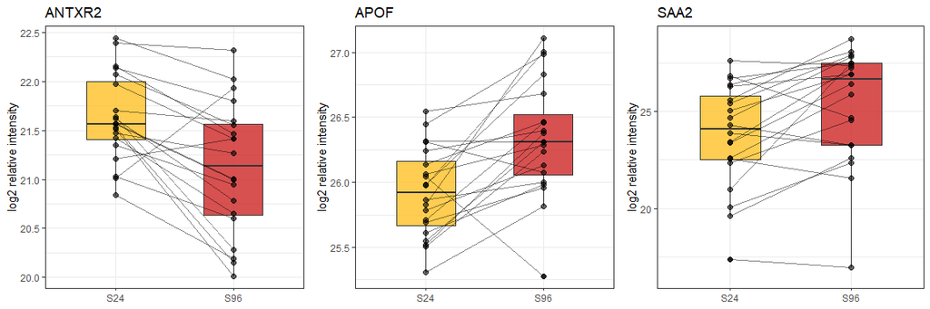

```r
connected_boxplot <- function(a,b,c,d){ggplot(a, aes(x=b, y = c)) +
    geom_boxplot(aes(fill=b, group=b), alpha=0.8,
                 width=0.5, show.legend = FALSE) +
    theme(legend.position = "none", axis.title.x = element_blank()) +
    geom_line(alpha=0.5, size=0.6, aes(group = d)) +
    geom_point(size=2, alpha=0.6, aes(group=b),
               position = position_dodge(width=0.75)) +
    scale_fill_manual(values = c("goldenrod1","firebrick3")) +
    labs(y="log2 relative intensity") +
    theme_bw() +
    theme(axis.title.x = element_blank())
}

a <- connected_boxplot(logP, logP$Group, logP$ANTXR2, logP$Pair_ID) +
  ggtitle("ANTXR2")

b <- connected_boxplot(logP, logP$Group, logP$APOF, logP$Pair_ID) +
  ggtitle("APOF")

c <- connected_boxplot(logP, logP$Group, logP$SAA2, logP$Pair_ID) +
  ggtitle("SAA2") + scale_y_continuous(limits = c(16.5, 28.8))

grid.arrange(a,b,c, ncol=3)
```

# 4. Correlation testing for post stroke changes

**Log2FC values calculated for all protein measures in paired 24 h and 96 h samples**

A new dataframe is created containing the log2FC of proteins for all the paired samples. These will be used for correlation and linear regression analysis.

```r
#Separating out the two time points of paired data
P24 <- logP %>% filter(Group=="S24")
P24rownames <- P24[,1]
rownames(P24) <- P24rownames
#renaming the measures to include which time point they belong to
colnames(P24) <- paste("S24", colnames(P24), sep = "_")

P96 <- logP %>% filter(Group=="S96")
P96rownames <- P96[,1]
rownames(P96) <- P96rownames
colnames(P96) <- paste("S96", colnames(P96), sep = "_")

#combining the renamed subsets
l_paired <- cbind(P24, P96)

#Actually calculating the log2FC of the pairs for each protein
#(there's probably a better/more elegant way to do this,
# but I never went back to figure it out... this works tho lol)
lfc <- data.frame(l_paired$S24_Pair_ID)
lfc$SERPINA1 <- log2(l_paired$S96_SERPINA1/l_paired$S24_SERPINA1)
lfc$ALB <- log2(l_paired$S96_ALB/l_paired$S24_ALB)
lfc$AMBP <- log2(l_paired$S96_AMBP/l_paired$S24_AMBP)
lfc$ANTXR2 <- log2(l_paired$S96_ANTXR2/l_paired$S24_ANTXR2)
lfc$APMAP <- log2(l_paired$S96_APMAP/l_paired$S24_APMAP)
lfc$LPA <- log2(l_paired$S96_LPA/l_paired$S24_LPA)
lfc$APOA1 <- log2(l_paired$S96_APOA1/l_paired$S24_APOA1)
lfc$APOA2 <- log2(l_paired$S96_APOA2/l_paired$S24_APOA2)
lfc$APOA4 <- log2(l_paired$S96_APOA4/l_paired$S24_APOA4)
lfc$APOB <- log2(l_paired$S96_APOB/l_paired$S24_APOB)
lfc$APOC3 <- log2(l_paired$S96_APOC3/l_paired$S24_APOC3)
lfc$APOC4 <- log2(l_paired$S96_APOC4/l_paired$S24_APOC4)
lfc$APOD <- log2(l_paired$S96_APOD/l_paired$S24_APOD)
lfc$APOE <- log2(l_paired$S96_APOE/l_paired$S24_APOE)
lfc$APOF <- log2(l_paired$S96_APOF/l_paired$S24_APOF)
lfc$APOL1 <- log2(l_paired$S96_APOL1/l_paired$S24_APOL1)
lfc$APOM <- log2(l_paired$S96_APOM/l_paired$S24_APOM)
lfc$CAMP <- log2(l_paired$S96_CAMP/l_paired$S24_CAMP)
lfc$CLU <- log2(l_paired$S96_CLU/l_paired$S24_CLU)
lfc$C3 <- log2(l_paired$S96_C3/l_paired$S24_C3)
lfc$PPBP <- log2(l_paired$S96_PPBP/l_paired$S24_PPBP)
lfc$AHSG <- log2(l_paired$S96_AHSG/l_paired$S24_AHSG)
lfc$FGA <- log2(l_paired$S96_FGA/l_paired$S24_FGA)
lfc$HPR <- log2(l_paired$S96_HPR/l_paired$S24_HPR)
lfc$IHH <- log2(l_paired$S96_IHH/l_paired$S24_IHH)
lfc$ITIH4<- log2(l_paired$S96_ITIH4/l_paired$S24_ITIH4)
lfc$LCAT <- log2(l_paired$S96_LCAT/l_paired$S24_LCAT)
lfc$SELL <- log2(l_paired$S96_SELL/l_paired$S24_SELL)
lfc$PCYOX1<- log2(l_paired$S96_PCYOX1/l_paired$S24_PCYOX1)
lfc$GPLD1 <- log2(l_paired$S96_GPLD1/l_paired$S24_GPLD1)
lfc$PF4 <- log2(l_paired$S96_PF4/l_paired$S24_PF4)
lfc$PLTP <- log2(l_paired$S96_PLTP/l_paired$S24_PLTP)
lfc$PON1 <- log2(l_paired$S96_PON1/l_paired$S24_PON1)
lfc$PON3 <- log2(l_paired$S96_PON3/l_paired$S24_PON3)
lfc$RBP4 <- log2(l_paired$S96_RBP4/l_paired$S24_RBP4)
lfc$SAA1 <- log2(l_paired$S96_SAA1/l_paired$S24_SAA1)
lfc$SAA2 <- log2(l_paired$S96_SAA2/l_paired$S24_SAA2)
lfc$TTR <- log2(l_paired$S96_TTR/l_paired$S24_TTR)

meta_p <- logP[1:20,1:23]
lfc_df <- cbind(meta_p, lfc)

#generating a table for manual inspection if so inclined
kable(lfc_df) %>%
  kable_styling() %>%
  scroll_box(width = "100%", height = "300px")
```

|  | Sample_no. | Sex | Age_blood | Group | Stroke | Pair | Pair_ID | Ischemic_Type | tPa | Thrombectomy | TICI2B | Hour | Cholesterol | Triglycerides | HDLC | LDLC | Statin | NIHSS_baseline | NIHSS_3mo | mRS | CEC | MS_RunID | MS_Batch | l_paired.S24_Pair_ID | SERPINA1 | ALB | AMBP | ANTXR2 | APMAP | … |
| --- | --- | --- | --- | --- | --- | --- | --- | --- | --- | --- | --- | --- | --- | --- | --- | --- | --- | --- | --- | --- | --- | --- | --- | --- | --- | --- | --- | --- | --- | --- |
| 36 | 36 | FEMALE | 50 | S24 | 1 | Yes | P1 | SV | Yes | No | NA | 24 | 223 | 507 | 20 | 304.4 | No | 15 | 16 | 4 | 11.520752 | R59 | B5 | P1 | -0.0162519 | -0.0211727 | 0.0164035 | -0.0458165 | 0.0778548 | … |
| 2 | 2 | MALE | 64 | S24 | 1 | Yes | P10 | LV | No | Yes | No | 24 | 183 | 122 | 31 | 176.4 | No | 20 | 6 | 3 | 10.743049 | R8 | B1 | P10 | -0.0165236 | -0.0320940 | -0.0270564 | -0.0298956 | 0.0618072 | … |
| 82 | 82 | MALE | 66 | S24 | 1 | Yes | P11 | LV | No | No | NA | 24 | 166 | 125 | 39 | 152.0 | No | 7 | 9 | 4 | 14.879076 | R72 | B6 | P11 | -0.0175976 | -0.0370019 | -0.0353152 | -0.0274479 | 0.0245790 | … |
| 51 | 51 | MALE | 77 | S24 | 1 | Yes | P12 | LV | No | No | NA | 24 | 97 | 61 | 35 | 74.2 | Yes | 17 | 13 | 4 | 8.785186 | R49 | B4 | P12 | -0.0362716 | -0.0667583 | -0.0661943 | -0.0934201 | -0.0095972 | … |
| 7 | 7 | MALE | 49 | S24 | 1 | Yes | P13 | LV | No | Yes | No | 24 | 169 | 76 | 32 | 152.2 | No | 20 | 12 | 4 | 12.364192 | R68 | B5 | P13 | -0.0167266 | -0.0731250 | -0.0031603 | -0.0953670 | -0.0200160 | … |
| 35 | 35 | MALE | 71 | S24 | 1 | Yes | P14 | CE | Yes | Yes | Yes | 24 | 175 | 79 | 45 | 145.8 | No | 16 | 13 | 4 | 8.794060 | R32 | B3 | P14 | 0.0102192 | -0.0497208 | -0.0306116 | -0.0453621 | -0.0264574 | … |
| 32 | 32 | FEMALE | 69 | S24 | 1 | Yes | P15 | CE | No | No | NA | 24 | 124 | 56 | 45 | 90.2 | No | 14 | 2 | 2 | 7.110238 | R63 | B5 | P15 | 0.0718284 | 0.0784698 | 0.0347289 | -0.0222841 | -0.0537437 | … |
| 80 | 80 | MALE | 80 | S24 | 1 | Yes | P16 | LV | Yes | No | NA | 24 | 206 | 206 | 31 | 216.2 | No | 8 | 0 | 2 | 10.917753 | R82 | B6 | P16 | 0.0441420 | 0.0280163 | 0.0149106 | -0.0069982 | -0.0405769 | … |
| 55 | 55 | FEMALE | 70 | S24 | 1 | Yes | P17 | LV | No | Yes | No | 24 | 90 | 40 | 51 | 47.0 | No | 23 | 37 | 5 | 8.225830 | R95 | B7 | P17 | 0.0758322 | 0.1207182 | 0.0716522 | -0.0274765 | 0.1006750 | … |
| 28 | 28 | MALE | 51 | S24 | 1 | Yes | P18 | LV | No | No | NA | 24 | 104 | 93 | 27 | 95.6 | No | 18 | 1 | 3 | 5.737339 | R35 | B3 | P18 | -0.0309279 | -0.0523985 | -0.0380789 | 0.0139750 | -0.0199593 | … |
| 52 | 52 | MALE | 64 | S24 | 1 | Yes | P19 | LV | Yes | No | NA | 24 | 121 | 120 | 32 | 113.0 | No | 17 | 12 | 4 | 12.166660 | R38 | B3 | P19 | 0.0401062 | -0.0032745 | 0.0195321 | -0.0344011 | 0.0214249 | … |
| 59 | 59 | MALE | 61 | S24 | 1 | Yes | P2 | LV | Yes | Yes | No | 24 | 163 | 98 | 68 | 114.6 | Yes | 20 | NaN | 6 | 13.458247 | R94 | B7 | P2 | 0.0026147 | 0.0215960 | 0.0414324 | 0.0620152 | -0.0189674 | … |
| 71 | 71 | MALE | 82 | S24 | 1 | Yes | P20 | LV | Yes | No | NA | 24 | 133 | 79 | 50 | 98.8 | No | 8 | 1 | 2 | 13.429480 | R44 | B4 | P20 | 0.0000700 | 0.0174107 | 0.0335286 | -0.0046480 | -0.0647983 | … |
| 19 | 19 | FEMALE | 86 | S24 | 1 | Yes | P3 | CE | No | Yes | No | 24 | 177 | 187 | 42 | 172.4 | No | 13 | NaN | 6 | 9.061798 | R71 | B6 | P3 | 0.1105161 | 0.1037401 | 0.0112510 | -0.1043498 | 0.0644335 | … |
| 46 | 46 | MALE | 70 | S24 | 1 | Yes | P4 | LV | Yes | Yes | Yes | 24 | 147 | 198 | 53 | 133.6 | Yes | 18 | 4 | 3 | 11.370783 | R55 | B4 | P4 | 0.0607694 | 0.0259916 | 0.0150697 | -0.0569904 | 0.0224823 | … |
| 25 | 25 | FEMALE | 75 | S24 | 1 | Yes | P5 | LV | Yes | No | NA | 24 | 170 | 62 | 37 | 145.4 | No | 24 | 16 | 5 | 7.108044 | R79 | B6 | P5 | 0.0808519 | 0.0968676 | 0.0584943 | -0.0531321 | -0.0002564 | … |
| 65 | 65 | FEMALE | 54 | S24 | 1 | Yes | P6 | LV | No | No | NA | 24 | 109 | 100 | 43 | 86.0 | No | 25 | 17 | 5 | 6.066922 | R69 | B5 | P6 | 0.0524508 | -0.0086915 | 0.0202029 | -0.0140439 | -0.0023883 | … |
| 53 | 53 | MALE | 58 | S24 | 1 | Yes | P7 | CE | No | No | NA | 24 | 147 | 95 | 40 | 126.0 | No | 10 | 8 | 4 | 10.486528 | R40 | B3 | P7 | 0.0462551 | 0.0013951 | 0.0014867 | -0.0380749 | -0.0183718 | … |
| 41 | 41 | FEMALE | 74 | S24 | 1 | Yes | P8 | LV | Yes | Yes | Yes | 24 | 133 | 100 | 48 | 105.0 | No | 19 | 0 | 1 | 8.736720 | R13 | B1 | P8 | -0.0220618 | 0.0845143 | 0.0243661 | -0.0367829 | 0.0101494 | … |
| 84 | 84 | FEMALE | 78 | S24 | 1 | Yes | P9 | SV | No | No | NA | 24 | 145 | 90 | 43 | 120.0 | Yes | 7 | 7 | 4 | 8.579152 | R58 | B5 | P9 | 0.0464827 | -0.0069118 | 0.0157845 | -0.0383151 | 0.0023770 | … |

### Shapiro-Wilk test for normality of each protein log2FC

```r
#Shapiro-Wilks test
p_swnorm <- lapply(lfc_df[, 25:length(lfc_df)], function(x) shapiro.test(x))
results_w <- ldply(p_swnorm, function(x) x$statistic)
results_p <- ldply(p_swnorm, function(x) x$p.value)

#Report the mean and median p-value, the number and
# percent with p-values greater than 0.05:
mean_FC <- format(mean(results_p$V1), digits=3, format="f")
median_FC <- format(median(results_p$V1), digits=3, format="f")
count_FC <- with(results_p, sum(V1>0.05))
count_tFC <- length(results_p$V1)
pct_normFC <- format((count_FC/count_tFC*100),
                     digits=3, format="f")

#Making a table of the statistics
results_swnorm <- data.frame(cbind("protein" = results_w$.id,
                                   "W" = results_w$W,
                                   "Pvalue" = results_p$V1))
kable(results_swnorm) %>%
  kable_styling() %>%
  scroll_box(width = "75%", height = "300px")
```

| protein | W | Pvalue |
| --- | --- | --- |
| SERPINA1 | 0.928396300106443 | 0.143817832458436 |
| ALB | 0.93877423131274 | 0.22730073133825 |
| AMBP | 0.958254829678667 | 0.50960265060482 |
| ANTXR2 | 0.938767129452875 | 0.22723022772362 |
| APMAP | 0.951629095454959 | 0.392497878998906 |
| LPA | 0.945099083579324 | 0.450813166286681 |
| APOA1 | 0.981399844106021 | 0.950864055017285 |
| APOA2 | 0.946467589718173 | 0.316629077694802 |
| APOA4 | 0.962242480033381 | 0.589558533798349 |
| APOB | 0.944126804552666 | 0.286582328034959 |
| APOC3 | 0.910261889728923 | 0.0644719114954409 |
| APOC4 | 0.936535758808858 | 0.206070146455531 |
| APOD | 0.908131070533888 | 0.0587241491033675 |
| APOE | 0.91496860875723 | 0.0793135153717448 |
| APOF | 0.968196672510003 | 0.716429486954957 |
| APOL1 | 0.910908326189805 | 0.0663280399759093 |
| APOM | 0.928009886040205 | 0.141373420337559 |
| CAMP | 0.834535956233788 | 0.00296729214154869 |
| CLU | 0.958686375989927 | 0.51795221833363 |
| C3 | 0.938355716346468 | 0.223180777634757 |
| PPBP | 0.960558465012244 | 0.555065982303779 |
| AHSG | 0.993708371236164 | 0.999937929809321 |
| FGA | 0.951915723187482 | 0.397109109563531 |
| HPR | 0.980127266919931 | 0.935734248310555 |
| IHH | 0.903394873408244 | 0.0477688733079339 |
| ITIH4 | 0.875564784240334 | 0.0179884328598313 |
| LCAT | 0.976959161440231 | 0.889110646826791 |
| SELL | 0.967742377478776 | 0.706670128272622 |
| PCYOX1 | 0.970090070386053 | 0.756775761142612 |
| GPLD1 | 0.957097240780783 | 0.487614292540579 |
| PF4 | 0.94363352075278 | 0.280582697280262 |
| PLTP | 0.969386245835529 | 0.741861326535586 |
| PON1 | 0.963257770929561 | 0.61077636528134 |
| PON3 | 0.955082912071624 | 0.450848122593373 |
| RBP4 | 0.983302008653532 | 0.969307097573842 |
| SAA1 | 0.944168797465841 | 0.340949637576333 |
| SAA2 | 0.956660007864635 | 0.479469089073726 |
| TTR | 0.978541543780803 | 0.913905113760977 |

### Shapiro-Wilk test for normality of each plasma lipid measure

```r
#Shapiro-Wilks test
plipid <- data.frame("Cholesterol"=lfc_df$Cholesterol,
                     "Triglycerides"=lfc_df$Triglycerides,
                     "HDLC"=lfc_df$HDLC,
                     "LDLC"=lfc_df$LDLC,
                     "CEC"=lfc_df$CEC)
p_swnorm <- lapply(plipid, function(x) shapiro.test(x))
results_w <- ldply(p_swnorm, function(x) x$statistic)
results_p <- ldply(p_swnorm, function(x) x$p.value)

#Making a table of the statistics
results_swnorm <- data.frame(cbind("protein" = results_w$.id,
                                   "W" = results_w$W,
                                   "Pvalue" = results_p$V1))
kable(results_swnorm) %>%
  kable_styling(full_width = FALSE, position = "left")
```

| protein | W | Pvalue |
| --- | --- | --- |
| Cholesterol | 0.976258522663825 | 0.877268941485731 |
| Triglycerides | 0.631648804337249 | 6.37929901629401e-06 |
| HDLC | 0.972986873137154 | 0.816276285560426 |
| LDLC | 0.895439304757207 | 0.0338974795223445 |
| CEC | 0.970696413674107 | 0.769512927970785 |

Both triglycerides and LDLC measures are non-normally distributed.

## Figure 4. Correlation plot of all patient measures

### Figure 4a. Correlation plot of measures

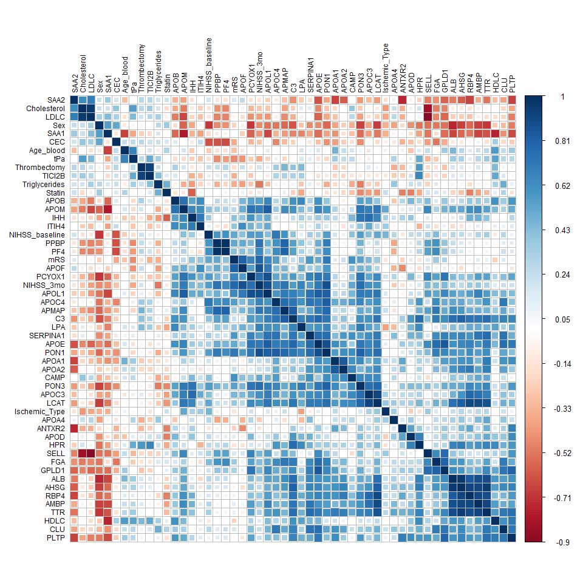

```r
#subset dataframe for clustering
lfc_clus <- lfc_df

#Not all data columns are useful in a correlation or clustering analysis; e.g. identifiers
lfc_clus <- select(lfc_clus, -"Pair", -"Pair_ID",
                   -"Stroke", -"Hour", -"Group",
                   -"l_paired.S24_Pair_ID", -"Sample_no.",
                   -"MS_RunID", -"MS_Batch")

lfc_matrix <- data.matrix(lfc_clus[,1:ncol(lfc_clus)])

# Calculating correlation values
# r-value: Pearson + Benjamini-Hochberg
lFC.pears.BH<-corr.test(lfc_matrix, use = "complete",
                        method="pearson",adjust="BH",alpha=.05)
lFC.pval.BH_pears<-lFC.pears.BH$p
lFC.rval.BH_pears<-lFC.pears.BH$r

#From corrplot package
corrplot(lFC.rval.BH_pears, is.corr=FALSE, order="hclust",
         tl.col = "black",
         method = "square",
         tl.cex = 0.75)
```

### Figure 4b. Hierarchical clustering of measures

Hierarchical clustering with the complete method

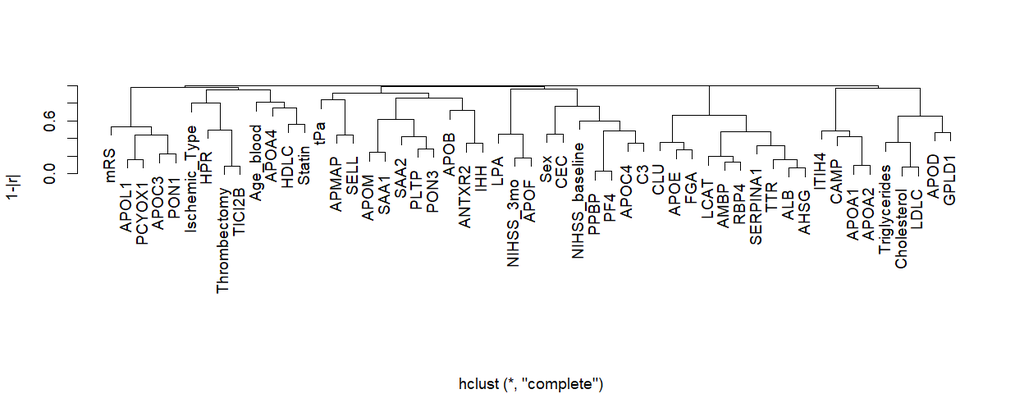

```r
#generate pearson correlation matrix
cor.pear<-rcorr(as.matrix(lfc_matrix), type="pearson")
#hierarchical clustering
hclust.x<-hclust((as.dist(1-abs(cor.pear$r))),method="complete")
par(cex=1.2)
plot(hclust.x,ylab = "1-|r|",xlab="",main="")
```

# 5. Stroke recovery linear regression analysis

In this section we are examining whether any of the protein changes following stroke show a relationship with patient’s stroke recovery - as assessed at 3 mos post stroke with NIHSS score.

## Table 3. HDL protein logFC from 24h to 96 h post stroke with significant correlation with stroke recovery

**Model: NIHSS_3mo ~ NIHSS_baseline + Protein Log2FC** This model includes the baseline NIHSS score assessed on patient presentation with Stroke.

```r
#This function returns all the statistics for the linear models as a dataframe - used for all downstream lm results
lm_out <- function(fit) {
    if (class(fit) != "lm") stop("Not an object of class 'lm' ")
    f <- summary(fit)$fstatistic
    p <- pf(f[1],f[2],f[3],lower.tail=F)
    attributes(p) <- NULL
    i <- summary(fit)$coef[1]
    se <- summary(fit)$coef[1,2]
    r2 <- summary(fit)$adj.r.squared
    f <- summary(fit)$fstatistic[1]
    df <- summary(fit)$fstatistic[3]
    out <- cbind(i, se, r2, p, f, df)
    return(out)
    out_df <- rbind(out_df, df)
}

#Initializing an output dataframe to contain all the linear model results
out_df <- data.frame()

#Loop to apply this model to each protein logFC measure
for (i in lfc_df[,25:ncol(lfc_df)]){
  fit <- lm(NIHSS_3mo ~ NIHSS_baseline + i, data = lfc_df)
  out <- data.frame(lm_out(fit))
  out_df <- data.frame(rbind(out_df, out))
}

#renaming & formatting the results dataframe to save
lm_NIH3_baseline.Prot <- out_df
rn <- data.frame(colnames(lfc_df[,25:ncol(lfc_df)]))
rownames(lm_NIH3_baseline.Prot) <- rn[,1]

#multiple testing correction since we are testing
# the model for all protein log2FC measures
lm_NIH3_baseline.Prot$p.adj <- p.adjust(lm_NIH3_baseline.Prot$p, method = "BH")

count_sig_t4 <- with(lm_NIH3_baseline.Prot, sum(p.adj<0.05))

#Results table
kable(lm_NIH3_baseline.Prot) %>%
  kable_styling() %>%
  scroll_box(width = "100%", height = "300px")
```

|  | i | se | r2 | p | f | df | p.adj |
| --- | --- | --- | --- | --- | --- | --- | --- |
| SERPINA1 | -2.9599877 | 5.582361 | 0.2169573 | 0.0624753 | 3.355091 | 15 | 0.1104737 |
| ALB | -2.2255191 | 5.827706 | 0.1656413 | 0.1005689 | 2.687464 | 15 | 0.1104737 |
| AMBP | -1.9353613 | 5.661177 | 0.2057388 | 0.0695092 | 3.201769 | 15 | 0.1104737 |
| ANTXR2 | -3.6100914 | 5.871157 | 0.1799770 | 0.0883106 | 2.865563 | 15 | 0.1104737 |
| APMAP | 1.8049581 | 5.126595 | 0.4132690 | 0.0071715 | 6.987048 | 15 | 0.0408158 |
| LPA | -8.4015070 | 5.224247 | 0.5989938 | 0.0041672 | 9.962364 | 10 | 0.0408158 |
| APOA1 | -3.9448568 | 6.113375 | 0.1738829 | 0.0933533 | 2.789099 | 15 | 0.1104737 |
| APOA2 | -4.1637643 | 5.999362 | 0.1870780 | 0.0827340 | 2.956108 | 15 | 0.1104737 |
| APOA4 | -2.7798924 | 5.648797 | 0.1966923 | 0.0756714 | 3.081250 | 15 | 0.1104737 |
| APOB | -1.0406449 | 5.689091 | 0.2291305 | 0.0555487 | 3.526509 | 15 | 0.1055426 |
| APOC3 | 2.3249182 | 5.830804 | 0.3171786 | 0.0223677 | 4.948350 | 15 | 0.0708310 |
| APOC4 | 6.1513882 | 5.933812 | 0.4109442 | 0.0073874 | 6.929871 | 15 | 0.0408158 |
| APOD | -2.9330815 | 5.778249 | 0.1672054 | 0.0991635 | 2.706598 | 15 | 0.1104737 |
| APOE | 1.2207997 | 5.228905 | 0.3801257 | 0.0108292 | 6.212459 | 15 | 0.0457231 |
| APOF | -6.5098570 | 3.321309 | 0.7336031 | 0.0000192 | 24.407274 | 15 | 0.0007304 |
| APOL1 | 0.7782944 | 4.075043 | 0.5994117 | 0.0004098 | 13.718795 | 15 | 0.0077859 |
| APOM | -1.3761293 | 4.911646 | 0.3989523 | 0.0085928 | 6.641972 | 15 | 0.0408158 |
| CAMP | -2.6856977 | 5.795587 | 0.1551256 | 0.1104737 | 2.560666 | 15 | 0.1104737 |
| CLU | -2.3614623 | 5.721537 | 0.1797408 | 0.0885015 | 2.862579 | 15 | 0.1104737 |
| C3 | -0.2979278 | 5.579077 | 0.2726919 | 0.0359092 | 4.186932 | 15 | 0.0813626 |
| PPBP | 0.8616384 | 5.272122 | 0.3628831 | 0.0133033 | 5.841351 | 15 | 0.0505527 |
| AHSG | -2.3231699 | 5.918351 | 0.1575165 | 0.1081504 | 2.589218 | 15 | 0.1104737 |
| FGA | -0.5633727 | 6.183559 | 0.1918381 | 0.0791690 | 3.017694 | 15 | 0.1104737 |
| HPR | -2.1079974 | 5.951323 | 0.1614365 | 0.1044329 | 2.636382 | 15 | 0.1104737 |
| IHH | -0.7424064 | 5.676802 | 0.2411964 | 0.0493501 | 3.701845 | 15 | 0.0987002 |
| ITIH4 | -0.5900380 | 7.252770 | 0.2196481 | 0.0691974 | 3.251785 | 14 | 0.1104737 |
| LCAT | -1.8546436 | 5.267034 | 0.3059877 | 0.0252680 | 4.747621 | 15 | 0.0738604 |
| SELL | -1.2058696 | 5.588165 | 0.2430234 | 0.0484658 | 3.728881 | 15 | 0.0987002 |
| PCYOX1 | 1.2628836 | 4.861633 | 0.4518628 | 0.0043051 | 8.007066 | 15 | 0.0408158 |
| GPLD1 | -4.1962602 | 5.375333 | 0.2925652 | 0.0291720 | 4.515242 | 15 | 0.0791810 |
| PF4 | 0.9214570 | 5.769297 | 0.2817232 | 0.0326969 | 4.333878 | 15 | 0.0813626 |
| PLTP | -3.2108399 | 5.814795 | 0.1720637 | 0.0949062 | 2.766490 | 15 | 0.1104737 |
| PON1 | -1.7636244 | 4.891178 | 0.4005318 | 0.0084249 | 6.679233 | 15 | 0.0408158 |
| PON3 | -2.6908737 | 5.071612 | 0.3520499 | 0.0150966 | 5.618295 | 15 | 0.0521519 |
| RBP4 | -2.5099197 | 5.703423 | 0.1815143 | 0.0870765 | 2.885031 | 15 | 0.1104737 |
| SAA1 | -6.1525867 | 7.135180 | 0.3069299 | 0.0363991 | 4.321416 | 13 | 0.0813626 |
| SAA2 | -2.5403770 | 5.626489 | 0.2028285 | 0.0714423 | 3.162700 | 15 | 0.1104737 |
| TTR | -2.5704560 | 5.796046 | 0.1567161 | 0.1089234 | 2.579642 | 15 | 0.1104737 |

```r
#write.csv(lm_NIH3_baseline.Prot, file="lm_3mos_bs_Prot.csv")
```

# 6. Cholesterol efflux capacity analysis

## Table 4: Cholesterol Efflux analysis

Cholesterol efflux capacity (CEC) was measured by J774A.1 macrophage based assay, with results recorded as a percentage. The relationship of stroke status and cholesterol efflux capacity are assessed by linear model, with correction for HDL-cholesterol measures and sex, age, and LDL-cholesterol.

```r
fit1 = lm(CEC~Stroke+HDLC,
          data=CvS24)

fit2 = lm(CEC~Stroke+Sex+Age_blood+HDLC+LDLC,
          data=CvS24)

#html table with both CEC model statistics
stargazer(fit1, fit2,
          title="Linear Regression Results",
          report="vcsp*",ci=TRUE,
          keep.stat=c("n","rsq","adj.rsq","aic","ser","f"),
          single.row = FALSE,type="html")
```

**Linear Regression Results**

|  | *Dependent variable:* |  |
| --- | --- | --- |
|  | CEC |  |
|  | (1) | (2) |
| Stroke | -3.435 | -2.450 |
|  | (-5.330, -1.540) | (-4.344, -0.555) |
|  | p = 0.001*** | p = 0.014** |
| SexMALE |  | 1.709 |
|  |  | (0.015, 3.404) |
|  |  | p = 0.053* |
| SexNA |  | -9.036 |
|  |  | (-15.134, -2.939) |
|  |  | p = 0.006*** |
| Age_blood |  | 0.002 |
|  |  | (-0.092, 0.097) |
|  |  | p = 0.963 |
| HDLC | 0.076 | 0.088 |
|  | (0.031, 0.121) | (0.043, 0.132) |
|  | p = 0.002*** | p = 0.0003*** |
| LDLC |  | 0.030 |
|  |  | (0.015, 0.045) |
|  |  | p = 0.0003*** |
| Constant | 10.717 | 4.185 |
|  | (7.619, 13.815) | (-3.677, 12.047) |
|  | p = 0.000*** | p = 0.302 |
| Observations | 70 | 66 |
| R<sup>2</sup> | 0.409 | 0.556 |
| Adjusted R<sup>2</sup> | 0.391 | 0.511 |
| Residual Std. Error | 3.521 (df = 67) | 3.001 (df = 59) |
| F Statistic | 23.172*** (df = 2; 67) | 12.317*** (df = 6; 59) |
| *Note:* | p<0.1; p<0.05; p<0.01 |  |

## Figure 5. Cholesterol efflux distribution plot

Plotting the percent CEC distributions for each group.

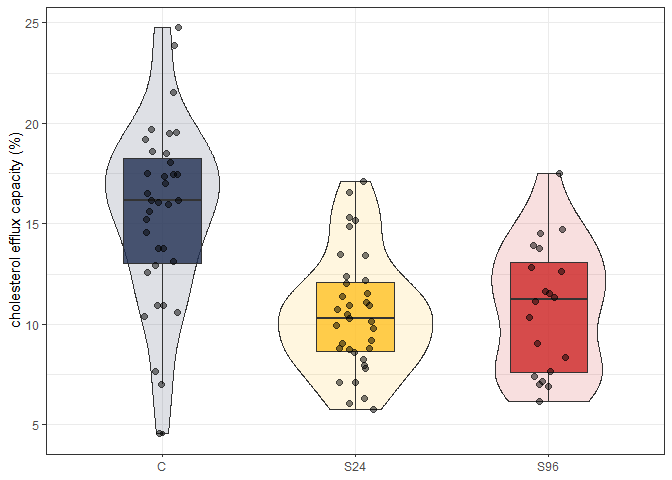

```r
#this plot function is found in section 3 for generation of Figure 2
allViolinplot(all, all$CEC) + labs(y="cholesterol efflux capacity (%)")
```

# 7. Supplemental material

## Supplemental Figure 1. Effect of normalization on N15 APOA1 spike-in variance distribution

For this figure I used a Skyline generated .csv report with peptide integrated areas, background signal, sample total ion current (TIC), TIC mean normalization factors and values, and heavy APOA1 peptide mean normalization factors and values.

In this dataset two different normalization strategies were assessed. Normalization of peptide intensity to total ion current was determined to be a better method for normalization, with it reducing the variance across system suitability replicates. These replicates are also called rotor control samples due to the nature of HDL isolation being limited to rotor batches for density gradient ultra-centrifugation.

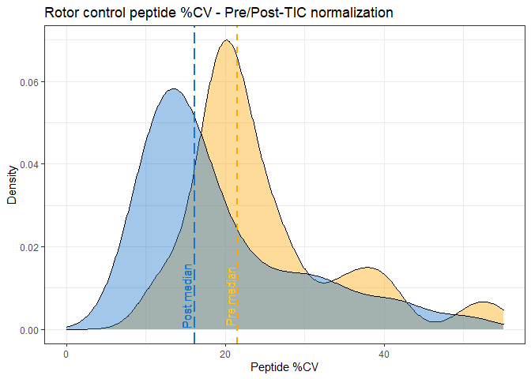

```r
#This is a modified skyline .csv report file.
#These rotor control samples are only analyzed here to demonstrate that the-
#mass spec data normalization improved data quality.
RCdf <- as.data.frame(read.csv("RotorControl_PRM.csv"))

#making a new identifier that incorporates both the peptide sequence and whether it was light or heavy
RCdf$PepID =paste(RCdf$Peptide, RCdf$Isotope, sep="_")

RCdf_CV <- select(RCdf,
                  'PepID', 'Background.subtracted',
                  'TIC_normalized_area',
                  'APOA1_normalized_area')
RCdf_CV <- RCdf_CV %>% group_by(PepID) %>%
                          summarise_each(funs(mean, sd))

#just a simple CV function
CV_fun <- function(mean, sd){
  (sd/mean)*100
}

#Calculating different CVs
RCdf_CV$Background.subtracted_cv <- CV_fun(RCdf_CV$Background.subtracted_mean,
                                           RCdf_CV$Background.subtracted_sd)
RCdf_CV$TIC_normalized_area_cv <- CV_fun(RCdf_CV$TIC_normalized_area_mean,
                                         RCdf_CV$TIC_normalized_area_sd)

#Mean and median CVs across all peptides
Pre_mean = mean(RCdf_CV$Background.subtracted_cv)
Pre_med = median(RCdf_CV$Background.subtracted_cv)
prem <- format(median(RCdf_CV$Background.subtracted_cv), digits=3, format="f")
TIC_mean = mean(RCdf_CV$TIC_normalized_area_cv)
TIC_med = median(RCdf_CV$TIC_normalized_area_cv)
TICm <- format(median(RCdf_CV$TIC_normalized_area_cv), digits=3, format="f")

#density plots for CV distribution
ggplot(RCdf_CV) +
  geom_density(aes(x=Background.subtracted_cv),
               colour='black', fill='orange', alpha=0.4) +
  geom_density(aes(x=TIC_normalized_area_cv),
               colour='black', fill='dodgerblue3', alpha=0.4) +
  geom_vline(xintercept=TIC_med, color='dodgerblue3',
             linetype='longdash', size=1) +
  geom_vline(xintercept=Pre_med, color='orange',
             linetype='dashed', size=1) +
  geom_text(aes(x=TIC_med, label="Post median\n", y=0.008),
            colour="dodgerblue3", angle=90,
            text=element_text(size=10)) +
  geom_text(aes(x=Pre_med, label="Pre median\n", y=0.008),
            colour="goldenrod1", angle=90,
            text=element_text(size=10)) +
  labs(x="Peptide %CV", y="Density") +
  ggtitle("Rotor control peptide %CV - Pre/Post-TIC normalization") +
  theme_bw() +
  scale_x_continuous(limits = c(0,55))
```

The median %CV prior to normalization was 21.5, reduced to 16.1 following total ion current normalization. Typically for targeted peptide assays CVs < 20% are preferred.

## Supplemental Table 4. Correlation results matrices

The p values and r values corresponding to the large correlation plot in Figure 4 are compiled and written to .csv. Both the following tables were combined into a single excel workbook.

```r
#write.csv(lFC.pval.BH_pears, "lFC_pvalBH_pears.csv", row.names=FALSE)
#write.csv(lFC.rval.BH_pears, "lFC_rvalBH_pears.csv", row.names=FALSE)

kable(lFC.pval.BH_pears) %>%
  kable_styling() %>%
  scroll_box(width = "100%", height = "300px")
```

|  | Sex | Age_blood | Ischemic_Type | tPa | Thrombectomy | TICI2B | Cholesterol | Triglycerides | HDLC | LDLC | Statin | NIHSS_baseline | NIHSS_3mo | mRS | CEC | SERPINA1 | ALB | AMBP | ANTXR2 | APMAP | LPA | APOA1 | APOA2 | APOA4 | APOB | APOC3 | APOC4 | APOD | APOE | … |
| --- | --- | --- | --- | --- | --- | --- | --- | --- | --- | --- | --- | --- | --- | --- | --- | --- | --- | --- | --- | --- | --- | --- | --- | --- | --- | --- | --- | --- | --- | --- |
| Sex | 0.0000000 | 0.8376058 | 0.4772483 | 0.9145204 | 0.9145204 | 0.9727465 | 0.6977462 | 0.6212312 | 0.6281754 | 0.5154820 | 0.4772483 | 0.0931793 | 0.3040382 | 0.6914639 | 0.2449623 | 0.3040562 | 0.0679049 | 0.1061220 | 0.7364382 | 0.1955318 | 0.6043755 | 0.4217927 | 0.6591875 | 0.4007046 | 0.7448671 | 0.3995072 | 0.2336319 | 0.3307208 | 0.3058270 | … |
| Age_blood | 0.6843132 | 0.0000000 | 0.8964113 | 0.1219558 | 0.9629801 | 0.7769474 | 0.9894492 | 0.8789393 | 0.2023322 | 0.7865122 | 0.5639717 | 0.6496004 | 0.9875093 | 0.5979156 | 0.6607688 | 0.9070175 | 0.3342780 | 0.6913284 | 0.8924880 | 0.9629801 | 0.7547639 | 0.3135264 | 0.6634940 | 0.9471271 | 0.9894492 | 0.8016883 | 0.9776100 | 0.6043755 | 0.7801209 | … |
| Ischemic_Type | 0.2320438 | 0.7829887 | 0.0000000 | 0.9456724 | 0.9456724 | 0.8016883 | 0.3603448 | 0.9629801 | 0.9544699 | 0.4373454 | 0.6943273 | 0.3234836 | 0.9629801 | 0.8150002 | 0.8941359 | 0.8915819 | 0.6659844 | 0.6252458 | 0.9853451 | 0.6659844 | 0.4104424 | 0.6364345 | 0.9192539 | 0.4873797 | 0.9570606 | 0.5253909 | 0.8950023 | 0.6548282 | 0.8395371 | … |
| tPa | 0.8227557 | 0.0126695 | 0.8889862 | 0.0000000 | 0.6281754 | 0.2743478 | 0.2201507 | 0.5107596 | 0.2418292 | 0.3386730 | 0.9456724 | 0.7576908 | 0.4286568 | 0.3097152 | 0.6253230 | 0.8376058 | 0.4595219 | 0.6008058 | 0.9411736 | 0.7051462 | 0.7848482 | 0.4772483 | 0.6474421 | 0.5665047 | 0.7357528 | 0.8741703 | 0.8941359 | 0.8395371 | 0.7952425 | … |
| Thrombectomy | 0.8227557 | 0.9250160 | 0.8889862 | 0.3784767 | 0.0000000 | 0.0018003 | 0.6144991 | 0.7028201 | 0.3528014 | 0.7357528 | 0.9456724 | 0.7038012 | 0.7400180 | 0.7631012 | 0.6196941 | 0.9544699 | 0.7547639 | 0.7631012 | 0.5342046 | 0.3209503 | 0.3514749 | 0.6252458 | 0.7130048 | 0.4613459 | 0.5243703 | 0.8078867 | 0.4796402 | 0.8376058 | 0.9198142 | … |
| TICI2B | 0.9484984 | 0.5822534 | 0.6269262 | 0.0816021 | 0.0000065 | 0.0000000 | 0.4840927 | 0.3812442 | 0.2578932 | 0.5946005 | 0.8016883 | 0.8676437 | 0.9219944 | 0.4833604 | 0.7038012 | 0.9875093 | 0.7853940 | 0.9192539 | 0.6666071 | 0.5620014 | 0.4978452 | 0.7038012 | 0.7038012 | 0.6496004 | 0.7692291 | 0.8536794 | 0.5618687 | 0.7200398 | 0.7865122 | … |
| Cholesterol | 0.4698901 | 0.9814642 | 0.1363445 | 0.0512695 | 0.3627854 | 0.2406412 | 0.0000000 | 0.7308369 | 0.9897566 | 0.0001508 | 0.7348579 | 0.7994115 | 0.6212312 | 0.9629801 | 0.4185564 | 0.8301618 | 0.8915819 | 0.9151110 | 0.4757301 | 0.4039211 | 0.8376058 | 0.7055080 | 0.9800795 | 0.6841514 | 0.4373688 | 0.9335152 | 0.9450891 | 0.8915819 | 0.3011440 | … |
| Triglycerides | 0.3705748 | 0.7496925 | 0.9255713 | 0.2616856 | 0.4743271 | 0.1501920 | 0.5175660 | 0.0000000 | 0.5291199 | 0.5036602 | 0.2897794 | 0.8520815 | 0.2449623 | 0.4701513 | 0.6903275 | 0.8376058 | 0.9139271 | 0.9112983 | 0.9636034 | 0.9146012 | 0.6140420 | 0.7400494 | 0.8646012 | 0.4312296 | 0.9151110 | 0.6806411 | 0.9121943 | 0.6668826 | 0.8480176 | … |
| HDLC | 0.3790003 | 0.0423289 | 0.9107748 | 0.0617735 | 0.1318525 | 0.0688713 | 0.9840106 | 0.2787671 | 0.0000000 | 0.7588192 | 0.8395371 | 0.8395371 | 0.8066668 | 0.6741025 | 0.4911550 | 0.3307208 | 0.1885416 | 0.2165099 | 0.8061277 | 0.4833604 | 0.2323097 | 0.7066730 | 0.8964113 | 0.9347131 | 0.1692739 | 0.7531198 | 0.5767151 | 0.4143197 | 0.3304656 | … |
| LDLC | 0.2667189 | 0.6010140 | 0.1986780 | 0.1242421 | 0.5290364 | 0.3361348 | 0.0000002 | 0.2565816 | 0.5592689 | 0.0000000 | 0.8941359 | 0.8207976 | 0.3985795 | 0.9314912 | 0.5270490 | 0.9544699 | 0.6573562 | 0.8792609 | 0.4772483 | 0.3078751 | 0.8950023 | 0.5915043 | 0.9544699 | 0.5979156 | 0.2609659 | 0.8016883 | 0.8789393 | 0.9471271 | 0.1898696 | … |
| Statin | 0.2320438 | 0.3098161 | 0.4655722 | 0.8889862 | 0.8889862 | 0.6269262 | 0.5258127 | 0.0897938 | 0.6906961 | 0.7721493 | 0.0000000 | 0.9411736 | 0.8395371 | 0.9348425 | 0.7631012 | 0.8950023 | 0.7055080 | 0.4101880 | 0.2743478 | 0.8588721 | 0.4286568 | 0.8395371 | 0.7183016 | 0.9161951 | 0.8016897 | 0.3979588 | 0.9544699 | 0.2743478 | 0.9798903 | … |
| NIHSS_baseline | 0.0069233 | 0.4063538 | 0.1103319 | 0.5569962 | 0.4793281 | 0.7359541 | 0.6186389 | 0.7124039 | 0.6911869 | 0.6587824 | 0.8803867 | 0.0000000 | 0.2201507 | 0.2643314 | 0.1427922 | 0.4878268 | 0.5979156 | 0.5844535 | 0.8177333 | 0.1755108 | 0.8451777 | 0.7183016 | 0.8948936 | 0.5979156 | 0.9161951 | 0.3842754 | 0.0886043 | 0.6461032 | 0.5476553 | … |
| NIHSS_3mo | 0.0976348 | 0.9776273 | 0.9288234 | 0.1909980 | 0.5332640 | 0.8463882 | 0.3704343 | 0.0632815 | 0.6363185 | 0.1633587 | 0.6942951 | 0.0513727 | 0.0000000 | 0.0474417 | 0.6033733 | 0.2201507 | 0.4933012 | 0.4144646 | 0.7869062 | 0.0858812 | 0.1246680 | 0.6599151 | 0.7028201 | 0.6470452 | 0.2336319 | 0.1683476 | 0.1260899 | 0.8483870 | 0.0931793 | … |
| mRS | 0.4616450 | 0.3404071 | 0.6488064 | 0.1020397 | 0.5653357 | 0.2387610 | 0.9278214 | 0.2224775 | 0.4432053 | 0.8598380 | 0.8649668 | 0.0745959 | 0.0014115 | 0.0000000 | 0.4480027 | 0.1980116 | 0.9727347 | 0.8395371 | 0.6958174 | 0.4856913 | 0.4370291 | 0.8016883 | 0.7066730 | 0.9660226 | 0.7400494 | 0.3307208 | 0.2156370 | 0.8395371 | 0.2715956 | … |
| CEC | 0.0637547 | 0.4244123 | 0.7720437 | 0.3761921 | 0.3687585 | 0.4785434 | 0.1825489 | 0.4593834 | 0.2462904 | 0.2769111 | 0.5649209 | 0.0185485 | 0.3489757 | 0.2065429 | 0.0000000 | 0.8376058 | 0.8423521 | 0.9139271 | 0.4927776 | 0.5432158 | 0.9798903 | 0.4101880 | 0.6596618 | 0.8220028 | 0.8016883 | 0.9544699 | 0.2927537 | 0.5786988 | 0.5773964 | … |
| SERPINA1 | 0.0979688 | 0.7970959 | 0.7661661 | 0.6763713 | 0.9126089 | 0.9781932 | 0.6689338 | 0.6816170 | 0.1163923 | 0.9095487 | 0.7773774 | 0.2439134 | 0.0507778 | 0.0412404 | 0.6825393 | 0.0000000 | 0.1456649 | 0.0843294 | 0.8608818 | 0.2603510 | 0.2023322 | 0.3632971 | 0.1940901 | 0.3603448 | 0.5347501 | 0.1655484 | 0.0843294 | 0.3078751 | 0.0646294 | … |
| ALB | 0.0029982 | 0.1206801 | 0.4315850 | 0.2140878 | 0.5520843 | 0.5990196 | 0.7659889 | 0.8180645 | 0.0357107 | 0.4148639 | 0.4877489 | 0.3407500 | 0.2484405 | 0.9466163 | 0.6986999 | 0.0196616 | 0.0000000 | 0.0065936 | 0.6596618 | 0.1655484 | 0.3820598 | 0.2131754 | 0.1788926 | 0.5359895 | 0.7257756 | 0.3105036 | 0.2609659 | 0.6364345 | 0.1692498 | … |
| AMBP | 0.0093184 | 0.4610528 | 0.3738770 | 0.3449650 | 0.5654037 | 0.8410863 | 0.8307721 | 0.8057431 | 0.0494209 | 0.7510088 | 0.1744341 | 0.3273456 | 0.1783581 | 0.6911644 | 0.8194535 | 0.0049635 | 0.0000868 | 0.0000000 | 0.6428056 | 0.3078751 | 0.2813276 | 0.3315460 | 0.2429087 | 0.3443578 | 0.4334720 | 0.0704253 | 0.3223092 | 0.3998941 | 0.1814699 | … |
| ANTXR2 | 0.5301500 | 0.7681355 | 0.9739043 | 0.8796582 | 0.2829293 | 0.4324722 | 0.2288890 | 0.9326450 | 0.6343886 | 0.2314371 | 0.0816274 | 0.6550982 | 0.6024572 | 0.4675812 | 0.2478192 | 0.7271890 | 0.4212644 | 0.3974386 | 0.0000000 | 0.9231215 | 0.7547639 | 0.2469587 | 0.3660693 | 0.7663131 | 0.6031351 | 0.6304238 | 0.9350584 | 0.2414288 | 0.4614243 | … |
| APMAP | 0.0405488 | 0.9307688 | 0.4315181 | 0.4817009 | 0.1083032 | 0.3078967 | 0.1679585 | 0.8256632 | 0.2397312 | 0.1012100 | 0.7229983 | 0.0298542 | 0.0051728 | 0.2417883 | 0.2913182 | 0.0705307 | 0.0253669 | 0.1009104 | 0.8480927 | 0.0000000 | 0.3279466 | 0.6794488 | 0.6043755 | 0.7869062 | 0.3700763 | 0.3211473 | 0.0646294 | 0.8376058 | 0.0997341 | … |
| LPA | 0.3514214 | 0.5514848 | 0.1748401 | 0.5976020 | 0.1311017 | 0.2518129 | 0.6814788 | 0.3613847 | 0.0576560 | 0.7770668 | 0.1908595 | 0.7034970 | 0.0140229 | 0.1976939 | 0.9617636 | 0.0424340 | 0.1513822 | 0.0861540 | 0.5508743 | 0.1122091 | 0.0000000 | 0.5107596 | 0.5021129 | 0.5476553 | 0.1363127 | 0.2205568 | 0.1814966 | 0.3315460 | 0.1814966 | … |
| APOA1 | 0.1865985 | 0.1046657 | 0.3903164 | 0.2312491 | 0.3737866 | 0.4795460 | 0.4856482 | 0.5340864 | 0.4902608 | 0.3326675 | 0.6934318 | 0.5030196 | 0.4223840 | 0.6231846 | 0.1742243 | 0.1392024 | 0.0466621 | 0.1180220 | 0.0645175 | 0.4486926 | 0.2620516 | 0.0000000 | 0.0184227 | 0.6649028 | 0.9151110 | 0.3223092 | 0.2699089 | 0.8950023 | 0.1655484 | … |
| APOA2 | 0.4200048 | 0.4285266 | 0.8425382 | 0.4040640 | 0.4956884 | 0.4786917 | 0.9630099 | 0.7315857 | 0.7832215 | 0.9129110 | 0.5021932 | 0.7734531 | 0.4742799 | 0.4898110 | 0.4210406 | 0.0395786 | 0.0314166 | 0.0624018 | 0.1410615 | 0.3526246 | 0.2550754 | 0.0003342 | 0.0000000 | 0.6607688 | 0.8950023 | 0.2205568 | 0.2752137 | 0.9777522 | 0.1943267 | … |
| APOA4 | 0.1660394 | 0.8959466 | 0.2433362 | 0.3116187 | 0.2152724 | 0.4063237 | 0.4532876 | 0.1927703 | 0.8641687 | 0.3407496 | 0.8357455 | 0.3414801 | 0.4032959 | 0.9370619 | 0.6611455 | 0.1370299 | 0.2854980 | 0.1274474 | 0.5713807 | 0.6021506 | 0.2956862 | 0.4299190 | 0.4257642 | 0.0000000 | 0.6187062 | 0.7547639 | 0.8376058 | 0.4663638 | 0.9167815 | … |
| APOB | 0.5400016 | 0.9815509 | 0.9160834 | 0.5287623 | 0.2736011 | 0.5755263 | 0.1990060 | 0.8281988 | 0.0278847 | 0.0714244 | 0.6289017 | 0.8346811 | 0.0584928 | 0.5343608 | 0.6237143 | 0.2844230 | 0.5108871 | 0.1944018 | 0.3479626 | 0.1434113 | 0.0168165 | 0.8304268 | 0.7767746 | 0.3677216 | 0.0000000 | 0.2535174 | 0.5905921 | 0.3326865 | 0.1683476 | … |
| APOC3 | 0.1649634 | 0.6271903 | 0.2746369 | 0.7428544 | 0.6378670 | 0.7155182 | 0.8623838 | 0.4504679 | 0.5487172 | 0.6244945 | 0.1613970 | 0.1528178 | 0.0272435 | 0.1157467 | 0.9120882 | 0.0253689 | 0.1028376 | 0.0033804 | 0.3833782 | 0.1086028 | 0.0528945 | 0.1096974 | 0.0528066 | 0.5521060 | 0.0673348 | 0.0000000 | 0.2135610 | 0.6125213 | 0.1427922 | … |
| APOC4 | 0.0581718 | 0.9563268 | 0.7773601 | 0.7714980 | 0.2337279 | 0.3066221 | 0.8847351 | 0.8095890 | 0.3205833 | 0.7500962 | 0.9115853 | 0.0059798 | 0.0144937 | 0.0485105 | 0.0913528 | 0.0043688 | 0.0719645 | 0.1095980 | 0.8658451 | 0.0024551 | 0.0337178 | 0.0777604 | 0.0822690 | 0.6804960 | 0.3317259 | 0.0475785 | 0.0000000 | 0.4480027 | 0.1004852 | … |
| APOD | 0.1161997 | 0.3501741 | 0.4110497 | 0.6951055 | 0.6835708 | 0.5052819 | 0.7662600 | 0.4345469 | 0.1776334 | 0.8956390 | 0.0816177 | 0.4008841 | 0.7080153 | 0.6919169 | 0.3229459 | 0.1011542 | 0.3886925 | 0.1654134 | 0.0614960 | 0.6765504 | 0.1171872 | 0.7791662 | 0.9571754 | 0.2196445 | 0.1192650 | 0.3600452 | 0.2061473 | 0.0000000 | 0.5393244 | … |
| APOE | 0.0987612 | 0.5899027 | 0.6914667 | 0.6140334 | 0.8437193 | 0.6006790 | 0.0959299 | 0.7070916 | 0.1145571 | 0.0372023 | 0.9603161 | 0.2954302 | 0.0069940 | 0.0792950 | 0.3218000 | 0.0024857 | 0.0276351 | 0.0327824 | 0.2156439 | 0.0080778 | 0.0337024 | 0.0251788 | 0.0399089 | 0.8369456 | 0.0271228 | 0.0184426 | 0.0086510 | 0.2884486 | 0.0000000 | … |
| APOF | 0.7667087 | 0.6693104 | 0.9270465 | 0.1249096 | 0.4351387 | 0.9281977 | 0.8113985 | 0.1640442 | 0.9669202 | 0.5956123 | 0.7634454 | 0.1587259 | 0.0001605 | 0.0009042 | 0.9825254 | 0.2653975 | 0.7793682 | 0.7957479 | 0.0977423 | 0.1220225 | 0.0953739 | 0.7776878 | 0.7464517 | 0.2429078 | 0.1091215 | 0.1260033 | 0.1369703 | 0.7969910 | 0.1844543 | … |
| APOL1 | 0.0530345 | 0.6517537 | 0.5945992 | 0.4497950 | 0.7211858 | 0.7287429 | 0.3593516 | 0.3152968 | 0.1346598 | 0.1371965 | 0.8706157 | 0.1496155 | 0.0000734 | 0.0180781 | 0.8681500 | 0.0041668 | 0.0516028 | 0.0138844 | 0.8218312 | 0.0090260 | 0.0299311 | 0.3454996 | 0.3907602 | 0.8895284 | 0.0161083 | 0.0100282 | 0.0348022 | 0.4644586 | 0.0005578 | … |
| APOM | 0.0339683 | 0.5557714 | 0.0695556 | 0.5206781 | 0.5387020 | 0.8747172 | 0.0746189 | 0.2260388 | 0.1288080 | 0.0134680 | 0.6538947 | 0.1623025 | 0.0083755 | 0.3872225 | 0.9494514 | 0.2259998 | 0.0638182 | 0.0188149 | 0.6980201 | 0.0235701 | 0.1333337 | 0.3171095 | 0.7183392 | 0.9037517 | 0.0034242 | 0.0103524 | 0.2067705 | 0.6045755 | 0.0122557 | … |
| CAMP | 0.2172522 | 0.5437496 | 0.9240419 | 0.3903264 | 0.8742944 | 0.6324085 | 0.1809046 | 0.2052155 | 0.9456595 | 0.3638987 | 0.3213784 | 0.1615490 | 0.0734817 | 0.0286660 | 0.5680329 | 0.0281195 | 0.1982171 | 0.0713569 | 0.8122336 | 0.5943812 | 0.0975042 | 0.0334829 | 0.0201244 | 0.3411303 | 0.8706517 | 0.0201684 | 0.0461775 | 0.8186859 | 0.2234754 | … |
| CLU | 0.2752774 | 0.4153787 | 0.4863892 | 0.3405155 | 0.8035884 | 0.5882264 | 0.5011244 | 0.0824842 | 0.0298981 | 0.4754469 | 0.3165080 | 0.3457467 | 0.4383894 | 0.5831174 | 0.5271920 | 0.0046074 | 0.0494925 | 0.0834253 | 0.2725647 | 0.0717840 | 0.2775516 | 0.0333481 | 0.0602219 | 0.1867152 | 0.2364474 | 0.1709506 | 0.0062182 | 0.1937085 | 0.0031241 | … |
| C3 | 0.0212810 | 0.9889108 | 0.9101427 | 0.9998409 | 0.1731679 | 0.2968288 | 0.4258075 | 0.7956044 | 0.0301263 | 0.2384351 | 0.4469264 | 0.1698578 | 0.0435942 | 0.4648984 | 0.4420590 | 0.0059611 | 0.0030308 | 0.0047962 | 0.2504284 | 0.0005580 | 0.0138824 | 0.2673959 | 0.1704776 | 0.8190754 | 0.0282837 | 0.0319594 | 0.0047349 | 0.0386002 | 0.0015975 | … |
| PPBP | 0.1027681 | 0.6099165 | 0.7909334 | 0.1006361 | 0.4164781 | 0.6810747 | 0.1164003 | 0.2369801 | 0.9348276 | 0.0856471 | 0.9694980 | 0.0374958 | 0.0041655 | 0.0734100 | 0.0210011 | 0.4175528 | 0.4163539 | 0.8960122 | 0.8102904 | 0.0012254 | 0.1763370 | 0.8046084 | 0.8494651 | 0.1794559 | 0.3903940 | 0.6432672 | 0.0278584 | 0.6839354 | 0.0851298 | … |
| AHSG | 0.0098348 | 0.3489275 | 0.3451777 | 0.2825090 | 0.6236386 | 0.6922061 | 0.6780016 | 0.8588498 | 0.0462935 | 0.4222197 | 0.3404631 | 0.3906473 | 0.3916520 | 0.8387850 | 0.6951464 | 0.0161675 | 0.0000005 | 0.0000251 | 0.1288539 | 0.0405821 | 0.1726904 | 0.0327910 | 0.0135445 | 0.1885373 | 0.3620007 | 0.0336480 | 0.0710108 | 0.2084213 | 0.0174980 | … |
| FGA | 0.0655140 | 0.8995500 | 0.6136475 | 0.4029134 | 0.6288212 | 0.6353082 | 0.0726584 | 0.6042235 | 0.4866210 | 0.0950031 | 0.5556538 | 0.1405648 | 0.1510948 | 0.2276385 | 0.0594434 | 0.0190907 | 0.0453884 | 0.2034114 | 0.3971937 | 0.0058144 | 0.6569681 | 0.1958927 | 0.1229038 | 0.3812233 | 0.5855562 | 0.3980818 | 0.0223533 | 0.3844695 | 0.0023539 | … |
| HPR | 0.0545723 | 0.6200275 | 0.6185655 | 0.0780015 | 0.0383423 | 0.0153444 | 0.5202712 | 0.4865656 | 0.0202479 | 0.8182540 | 0.2122328 | 0.3752755 | 0.6083593 | 0.6250946 | 0.5690323 | 0.1032293 | 0.0125855 | 0.0306902 | 0.2273580 | 0.1071735 | 0.0208881 | 0.3160191 | 0.3023550 | 0.6848991 | 0.2844498 | 0.3079922 | 0.0362604 | 0.0106902 | 0.2554290 | … |
| IHH | 0.1871999 | 0.3754998 | 0.2842474 | 0.4254902 | 0.6838472 | 0.2389744 | 0.6828410 | 0.1459182 | 0.9614231 | 0.4838598 | 0.0332284 | 0.2309434 | 0.1180242 | 0.1703009 | 0.7435586 | 0.3813780 | 0.6994536 | 0.0908291 | 0.2719253 | 0.8553603 | 0.2548294 | 0.4100186 | 0.7067705 | 0.4834797 | 0.0600685 | 0.0021181 | 0.5717516 | 0.1855377 | 0.2399264 | … |
| ITIH4 | 0.8181650 | 0.9240932 | 0.2372382 | 0.3655945 | 0.7815649 | 0.3409691 | 0.4162819 | 0.4901373 | 0.7174691 | 0.3136507 | 0.8335797 | 0.7244657 | 0.1525589 | 0.1852904 | 0.4199008 | 0.7245207 | 0.4973819 | 0.6862532 | 0.8916896 | 0.9836134 | 0.5211452 | 0.8049824 | 0.6322832 | 0.8688843 | 0.0217169 | 0.0754089 | 0.9028121 | 0.9727981 | 0.2964810 | … |
| LCAT | 0.0081785 | 0.9981915 | 0.2012160 | 0.9863220 | 0.8095127 | 0.6835525 | 0.7018278 | 0.4074884 | 0.3792757 | 0.4403006 | 0.1347240 | 0.0718280 | 0.0306305 | 0.1925719 | 0.5278706 | 0.0067523 | 0.0031809 | 0.0000293 | 0.3078956 | 0.0368569 | 0.0869405 | 0.0450853 | 0.0210356 | 0.2394247 | 0.1798384 | 0.0000120 | 0.0265490 | 0.2604273 | 0.0069622 | … |
| SELL | 0.0515077 | 0.4123562 | 0.2225188 | 0.2734599 | 0.5005644 | 0.4367385 | 0.0002473 | 0.4687149 | 0.3188194 | 0.0000265 | 0.5176319 | 0.3012858 | 0.1157176 | 0.5873951 | 0.1634234 | 0.5594778 | 0.1969628 | 0.5130252 | 0.5096205 | 0.0567595 | 0.8264936 | 0.3758716 | 0.9410731 | 0.9328352 | 0.1375482 | 0.8317623 | 0.4345476 | 0.7366786 | 0.0232946 | … |
| PCYOX1 | 0.0071002 | 0.9409952 | 0.5126330 | 0.3916507 | 0.6517238 | 0.3809028 | 0.2603617 | 0.3556906 | 0.3062493 | 0.1216053 | 0.6549169 | 0.0459886 | 0.0030552 | 0.0149309 | 0.2635114 | 0.0125551 | 0.1288726 | 0.0471832 | 0.8074909 | 0.0757724 | 0.1583412 | 0.3542473 | 0.7155296 | 0.3234984 | 0.0535806 | 0.0634311 | 0.0651569 | 0.1208058 | 0.0047048 | … |
| GPLD1 | 0.0531625 | 0.2276423 | 0.8295014 | 0.9934747 | 0.3438793 | 0.4609782 | 0.0856219 | 0.9940144 | 0.0722156 | 0.0381118 | 0.6860117 | 0.5013844 | 0.1267018 | 0.2909024 | 0.2174784 | 0.0120060 | 0.0256288 | 0.1036538 | 0.2342510 | 0.0806096 | 0.2656116 | 0.0488288 | 0.1629307 | 0.3749954 | 0.1947633 | 0.4351214 | 0.0851067 | 0.2339980 | 0.0002404 | … |
| PF4 | 0.1178798 | 0.5879779 | 0.9769096 | 0.1430429 | 0.3287784 | 0.4948954 | 0.0911093 | 0.4803987 | 0.9710905 | 0.0871344 | 0.8008204 | 0.0276016 | 0.0188230 | 0.1612327 | 0.0145488 | 0.5167118 | 0.4355547 | 0.9896861 | 0.8675262 | 0.0008094 | 0.2933670 | 0.8084769 | 0.8922665 | 0.2209295 | 0.4673313 | 0.7793924 | 0.0222343 | 0.6852374 | 0.1146440 | … |
| PLTP | 0.0738278 | 0.2184494 | 0.7708085 | 0.3534787 | 0.8423484 | 0.8900850 | 0.1843571 | 0.7226379 | 0.0069113 | 0.0757873 | 0.6201531 | 0.7764427 | 0.4861053 | 0.8940001 | 0.4014175 | 0.0839127 | 0.0303174 | 0.0539628 | 0.0095782 | 0.2751066 | 0.1004713 | 0.0251791 | 0.2244389 | 0.4350723 | 0.0354280 | 0.2822244 | 0.1609974 | 0.0233356 | 0.0059644 | … |
| PON1 | 0.0402320 | 0.8985488 | 0.8980177 | 0.4767392 | 0.8666870 | 0.7127354 | 0.3675530 | 0.2264721 | 0.5429312 | 0.1979896 | 0.5848226 | 0.0508294 | 0.0000850 | 0.0057073 | 0.1147013 | 0.0029444 | 0.0361168 | 0.0471377 | 0.6512195 | 0.0019923 | 0.0149703 | 0.0435018 | 0.0262186 | 0.9530192 | 0.1841555 | 0.0096074 | 0.0005545 | 0.4564189 | 0.0001000 | … |
| PON3 | 0.0111633 | 0.8335098 | 0.5719938 | 0.8229356 | 0.9076095 | 0.7026117 | 0.3930946 | 0.0728892 | 0.4795858 | 0.1600978 | 0.0927290 | 0.0470797 | 0.0027043 | 0.0596070 | 0.1056930 | 0.0621267 | 0.0794289 | 0.0310178 | 0.1971386 | 0.0770697 | 0.0086776 | 0.0195598 | 0.1167438 | 0.9036474 | 0.0549757 | 0.0028435 | 0.0149371 | 0.1373461 | 0.0056150 | … |
| RBP4 | 0.0382633 | 0.6347952 | 0.4250435 | 0.6615392 | 0.8351745 | 0.8142314 | 0.6403618 | 0.5194040 | 0.1637730 | 0.3522408 | 0.0760275 | 0.5738482 | 0.2092582 | 0.8413087 | 0.8797371 | 0.0308587 | 0.0004037 | 0.0000206 | 0.0703512 | 0.0949319 | 0.0798987 | 0.0334629 | 0.0077119 | 0.4169298 | 0.1821457 | 0.0016430 | 0.1617653 | 0.2767678 | 0.0136636 | … |
| SAA1 | 0.0489139 | 0.0099016 | 0.2319851 | 0.2001810 | 0.4233516 | 0.5198264 | 0.4772562 | 0.5601898 | 0.0021193 | 0.1389621 | 0.9372802 | 0.5254362 | 0.1231914 | 0.9878754 | 0.6460740 | 0.1776945 | 0.0124987 | 0.0139386 | 0.8516072 | 0.1430912 | 0.0871223 | 0.1184871 | 0.5824287 | 0.8044073 | 0.0382771 | 0.1608633 | 0.2475659 | 0.5980339 | 0.0493070 | … |
| SAA2 | 0.4483558 | 0.3041679 | 0.6110633 | 0.9683173 | 0.3629915 | 0.3516921 | 0.0256432 | 0.5066208 | 0.3138532 | 0.0099562 | 0.5026706 | 0.5226410 | 0.6596317 | 0.5961896 | 0.5194035 | 0.5445843 | 0.0706613 | 0.2053391 | 0.0029275 | 0.3468416 | 0.3810692 | 0.0116612 | 0.0283783 | 0.7592085 | 0.2449115 | 0.2866189 | 0.6939879 | 0.7952283 | 0.0197736 | … |
| TTR | 0.0075112 | 0.3550580 | 0.3650248 | 0.2139143 | 0.8962654 | 0.9269097 | 0.8586984 | 0.8754601 | 0.0451711 | 0.5566780 | 0.2930132 | 0.2681028 | 0.2877986 | 0.7267904 | 0.5694431 | 0.0024575 | 0.0000647 | 0.0000088 | 0.0958931 | 0.1076118 | 0.1029754 | 0.0081189 | 0.0098831 | 0.0672805 | 0.2625799 | 0.0102066 | 0.0320454 | 0.0810760 | 0.0070951 | … |

```r
kable(lFC.rval.BH_pears) %>%
  kable_styling() %>%
  scroll_box(width = "100%", height = "300px")
```

|  | Sex | Age_blood | Ischemic_Type | tPa | Thrombectomy | TICI2B | Cholesterol | Triglycerides | HDLC | LDLC | Statin | NIHSS_baseline | NIHSS_3mo | mRS | CEC | SERPINA1 | ALB | AMBP | ANTXR2 | APMAP | LPA | APOA1 | APOA2 | APOA4 | APOB | APOC3 | APOC4 | APOD | APOE | … |
| --- | --- | --- | --- | --- | --- | --- | --- | --- | --- | --- | --- | --- | --- | --- | --- | --- | --- | --- | --- | --- | --- | --- | --- | --- | --- | --- | --- | --- | --- | --- |
| Sex | 1.0000000 | -0.1249087 | -0.3563483 | -0.0690066 | -0.0690066 | -0.0199205 | 0.2201304 | 0.2709475 | -0.2663847 | 0.3326801 | 0.3563483 | -0.7066620 | -0.4790877 | -0.2241327 | 0.5278085 | -0.4786708 | -0.7524823 | -0.6881281 | -0.1918124 | -0.5732583 | -0.2815303 | -0.3909040 | -0.2448976 | -0.4082899 | -0.1873223 | -0.4092369 | -0.5374950 | -0.4572435 | -0.4776855 | … |
| Age_blood | -0.1249087 | 1.0000000 | 0.0847963 | 0.6675219 | 0.0290227 | 0.1684445 | 0.0071658 | -0.0981643 | 0.5691887 | -0.1602412 | 0.3056611 | -0.2519262 | -0.0086494 | -0.2877577 | 0.2426529 | 0.0791748 | 0.4523301 | 0.2244215 | -0.0907414 | 0.0267910 | 0.1821326 | 0.4705084 | 0.2405681 | -0.0403214 | -0.0071323 | -0.1489583 | 0.0168897 | -0.2822302 | 0.1650874 | … |
| Ischemic_Type | -0.3563483 | 0.0847963 | 1.0000000 | -0.0430331 | -0.0430331 | -0.1490712 | -0.4360514 | 0.0288072 | -0.0345530 | -0.3812499 | 0.2222222 | 0.4638749 | 0.0275456 | -0.1397713 | -0.0891744 | -0.0915318 | 0.2390248 | 0.2691527 | 0.0100892 | 0.2390585 | -0.4006884 | 0.2603396 | 0.0612116 | 0.3484210 | 0.0324905 | 0.3275359 | 0.0870459 | -0.2494951 | 0.1219456 | … |
| tPa | -0.0690066 | 0.6675219 | -0.0430331 | 1.0000000 | 0.2666667 | 0.5003702 | 0.5504302 | 0.3359970 | 0.5311746 | 0.4485102 | 0.0430331 | -0.1796580 | -0.3873435 | -0.4736655 | 0.2678994 | 0.1282102 | 0.3694524 | 0.2851676 | 0.0466718 | -0.2144546 | 0.1617256 | 0.3569149 | 0.2531168 | 0.3045794 | -0.1924477 | -0.1009288 | 0.0893930 | 0.1204422 | -0.1546067 | … |
| Thrombectomy | -0.0690066 | 0.0290227 | -0.0430331 | 0.2666667 | 1.0000000 | 0.9237604 | 0.2752151 | 0.2179904 | 0.4405867 | 0.1923222 | 0.0430331 | 0.2155896 | 0.1903892 | -0.1759329 | 0.2719383 | 0.0338402 | 0.1818629 | 0.1759026 | -0.3222404 | 0.4662228 | 0.4413547 | -0.2692017 | -0.2078159 | -0.3685675 | 0.3282038 | 0.1444066 | 0.3551515 | 0.1252168 | -0.0607473 | … |
| TICI2B | -0.0199205 | 0.1684445 | -0.1490712 | 0.5003702 | 0.9237604 | 1.0000000 | 0.3502924 | 0.4226609 | 0.5194436 | 0.2902029 | 0.1490712 | 0.1037256 | -0.0596986 | -0.3516054 | 0.2159655 | -0.0084306 | 0.1611085 | 0.0617825 | -0.2385781 | 0.3068168 | 0.3426146 | -0.2154853 | -0.2158945 | -0.2519418 | 0.1714115 | -0.1120529 | 0.3075865 | 0.2033120 | -0.1603868 | … |
| Cholesterol | 0.2201304 | 0.0071658 | -0.4360514 | 0.5504302 | 0.2752151 | 0.3502924 | 1.0000000 | 0.1976010 | -0.0061813 | 0.9593977 | -0.1938006 | -0.1526244 | -0.2710240 | -0.0279343 | 0.3942284 | 0.1313135 | -0.0916029 | 0.0658435 | -0.3586046 | -0.4066107 | 0.1260855 | -0.2125722 | 0.0143034 | 0.2282246 | -0.3809930 | -0.0534254 | -0.0446908 | 0.0914941 | -0.4812312 | … |
| Triglycerides | 0.2709475 | -0.0981643 | 0.0288072 | 0.3359970 | 0.2179904 | 0.4226609 | 0.1976010 | 1.0000000 | 0.3248869 | 0.3393993 | 0.4891688 | -0.1133281 | -0.5286057 | -0.3632492 | 0.2252365 | 0.1260281 | -0.0708605 | -0.0757404 | 0.0260635 | -0.0678586 | -0.2759877 | -0.1900140 | -0.1055000 | 0.3859239 | -0.0668582 | -0.2296133 | 0.0742155 | 0.2375354 | -0.1155071 | … |
| HDLC | -0.2663847 | 0.5691887 | -0.0345530 | 0.5311746 | 0.4405867 | 0.5194436 | -0.0061813 | 0.3248869 | 1.0000000 | -0.1786405 | 0.1222643 | -0.1220613 | 0.1450651 | -0.2332098 | 0.3463839 | 0.4570297 | 0.5850148 | 0.5541040 | 0.1458865 | 0.3509271 | 0.5384227 | 0.2103815 | 0.0847033 | 0.0527266 | 0.6067756 | 0.1833791 | 0.2992517 | 0.3983270 | 0.4590767 | … |
| LDLC | 0.3326801 | -0.1602412 | -0.3812499 | 0.4485102 | 0.1923222 | 0.2902029 | 0.9593977 | 0.3393993 | -0.1786405 | 1.0000000 | -0.0891320 | -0.1355682 | -0.4106565 | -0.0544225 | 0.3260744 | 0.0350296 | -0.2475307 | -0.0976329 | -0.3567807 | -0.4746744 | -0.0871632 | -0.2921999 | -0.0337229 | 0.2875625 | -0.5154323 | -0.1501120 | -0.0980013 | 0.0404411 | -0.5812730 | … |
| Statin | 0.3563483 | 0.3056611 | 0.2222222 | 0.0430331 | 0.0430331 | 0.1490712 | -0.1938006 | 0.4891688 | 0.1222643 | -0.0891320 | 1.0000000 | -0.0463875 | -0.1207768 | -0.0524142 | 0.1761176 | -0.0870389 | -0.2115733 | -0.4010337 | -0.5003344 | 0.1089970 | -0.3874548 | -0.1211334 | -0.2047578 | -0.0638842 | -0.1482268 | -0.4124044 | 0.0342380 | -0.5003482 | -0.0153457 | … |
| NIHSS_baseline | -0.7066620 | -0.2519262 | 0.4638749 | -0.1796580 | 0.2155896 | 0.1037256 | -0.1526244 | -0.1133281 | -0.1220613 | -0.1355682 | -0.0463875 | 1.0000000 | 0.5502278 | 0.5105867 | -0.6396876 | 0.3480218 | 0.2875622 | 0.2952877 | -0.1371178 | 0.6009155 | 0.1169844 | 0.2043706 | 0.0886097 | 0.2871463 | 0.0643033 | 0.4202140 | 0.7153340 | 0.2547761 | 0.3144246 | … |
| NIHSS_3mo | -0.4790877 | -0.0086494 | 0.0275456 | -0.3873435 | 0.1903892 | -0.0596986 | -0.2710240 | -0.5286057 | 0.1450651 | -0.4106565 | -0.1207768 | 0.5502278 | 1.0000000 | 0.7869718 | -0.2829038 | 0.5513979 | 0.3449104 | 0.3977183 | -0.1596144 | 0.7236294 | 0.6603669 | 0.2436845 | 0.2180131 | -0.2535170 | 0.5369207 | 0.6087493 | 0.6580000 | 0.1151279 | 0.7060497 | … |
| mRS | -0.2241327 | -0.2877577 | -0.1397713 | -0.4736655 | -0.1759329 | -0.3516054 | -0.0279343 | -0.3632492 | -0.2332098 | -0.0544225 | -0.0524142 | 0.5105867 | 0.7869718 | 1.0000000 | -0.3751604 | 0.5716619 | -0.0206494 | 0.1220707 | -0.2212478 | 0.3494943 | 0.3820224 | 0.1506733 | 0.2105947 | 0.0243512 | 0.1898888 | 0.4577474 | 0.5559495 | 0.1217595 | 0.5036646 | … |
| CEC | 0.5278085 | 0.2426529 | -0.0891744 | 0.2678994 | 0.2719383 | 0.2159655 | 0.3942284 | 0.2252365 | 0.3463839 | 0.3260744 | 0.1761176 | -0.6396876 | -0.2829038 | -0.3751604 | 1.0000000 | -0.1256450 | -0.1189595 | 0.0703113 | -0.3453354 | -0.3169741 | -0.0147856 | -0.4012123 | -0.2443690 | -0.1345758 | 0.1504463 | -0.0340426 | -0.4871177 | -0.2978615 | -0.2985350 | … |
| SERPINA1 | -0.4786708 | 0.0791748 | -0.0915318 | 0.1282102 | 0.0338402 | -0.0084306 | 0.1313135 | 0.1260281 | 0.4570297 | 0.0350296 | -0.0870389 | 0.3480218 | 0.5513979 | 0.5716619 | -0.1256450 | 1.0000000 | 0.6351921 | 0.7259423 | 0.1072889 | 0.5168249 | 0.5689523 | 0.4332171 | 0.5755308 | 0.4353681 | 0.3212961 | 0.6147224 | 0.7329522 | 0.4747425 | 0.7616066 | … |
| ALB | -0.7524823 | 0.4523301 | 0.2390248 | 0.3694524 | 0.1818629 | 0.1611085 | -0.0916029 | -0.0708605 | 0.5850148 | -0.2475307 | -0.2115733 | 0.2875622 | 0.3449104 | -0.0206494 | -0.1189595 | 0.6351921 | 1.0000000 | 0.8758582 | 0.2442549 | 0.6147289 | 0.4215484 | 0.5597743 | 0.5964651 | 0.3206183 | 0.2006985 | 0.4727005 | 0.5145967 | 0.2612014 | 0.6075399 | … |
| AMBP | -0.6881281 | 0.2244215 | 0.2691527 | 0.2851676 | 0.1759026 | 0.0617825 | 0.0658435 | -0.0757404 | 0.5541040 | -0.0976329 | -0.4010337 | 0.2952877 | 0.3977183 | 0.1220707 | 0.0703113 | 0.7259423 | 0.8758582 | 1.0000000 | 0.2565816 | 0.4750401 | 0.4940548 | 0.4552300 | 0.5300990 | 0.4451348 | 0.3846242 | 0.7464376 | 0.4647209 | 0.4088404 | 0.5927055 | … |
| ANTXR2 | -0.1918124 | -0.0907414 | 0.0100892 | 0.0466718 | -0.3222404 | -0.2385781 | -0.3586046 | 0.0260635 | 0.1458865 | -0.3567807 | -0.5003344 | -0.1371178 | -0.1596144 | -0.2212478 | -0.3453354 | 0.1072889 | 0.2442549 | 0.2565816 | 1.0000000 | -0.0590291 | 0.1824074 | 0.5265322 | 0.4313938 | 0.1732468 | 0.2834743 | 0.2640349 | 0.0520705 | 0.5316522 | 0.3682907 | … |
| APMAP | -0.5732583 | 0.0267910 | 0.2390585 | -0.2144546 | 0.4662228 | 0.3068168 | -0.4066107 | -0.0678586 | 0.3509271 | -0.4746744 | 0.1089970 | 0.6009155 | 0.7236294 | 0.3494943 | -0.3169741 | 0.5168249 | 0.6147289 | 0.4750401 | -0.0590291 | 1.0000000 | 0.4617281 | 0.2304898 | 0.2808565 | -0.1597475 | 0.4291118 | 0.4658743 | 0.7621979 | 0.1281356 | 0.6972039 | … |
| LPA | -0.2815303 | 0.1821326 | -0.4006884 | 0.1617256 | 0.4413547 | 0.3426146 | 0.1260855 | -0.2759877 | 0.5384227 | -0.0871632 | -0.3874548 | 0.1169844 | 0.6603669 | 0.3820224 | -0.0147856 | 0.5689523 | 0.4215484 | 0.4940548 | 0.1824074 | 0.4617281 | 1.0000000 | 0.3357546 | 0.3404110 | -0.3142665 | 0.6471009 | 0.5472780 | 0.5901962 | 0.4561498 | 0.5902370 | … |
| APOA1 | -0.3909040 | 0.4705084 | 0.2603396 | 0.3569149 | -0.2692017 | -0.2154853 | -0.2125722 | -0.1900140 | 0.2103815 | -0.2921999 | -0.1211334 | 0.2043706 | 0.2436845 | 0.1506733 | -0.4012123 | 0.4332171 | 0.5597743 | 0.4552300 | 0.5265322 | 0.2304898 | 0.3357546 | 1.0000000 | 0.8392239 | 0.2398648 | 0.0659796 | 0.4646061 | 0.5058931 | 0.0863236 | 0.6153463 | … |
| APOA2 | -0.2448976 | 0.2405681 | 0.0612116 | 0.2531168 | -0.2078159 | -0.2158945 | 0.0143034 | -0.1055000 | 0.0847033 | -0.0337229 | -0.2047578 | 0.0886097 | 0.2180131 | 0.2105947 | -0.2443690 | 0.5755308 | 0.5964651 | 0.5300990 | 0.4313938 | 0.2808565 | 0.3404110 | 0.8392239 | 1.0000000 | 0.2419668 | -0.0872801 | 0.5474467 | 0.4994299 | 0.0165612 | 0.5747526 | … |
| APOA4 | -0.4082899 | -0.0403214 | 0.3484210 | 0.3045794 | -0.3685675 | -0.2519418 | 0.2282246 | 0.3859239 | 0.0527266 | 0.2875625 | -0.0638842 | 0.2871463 | -0.2535170 | 0.0243512 | -0.1345758 | 0.4353681 | 0.3206183 | 0.4451348 | 0.1732468 | -0.1597475 | -0.3142665 | 0.2398648 | 0.2419668 | 1.0000000 | -0.2725051 | 0.1818532 | 0.1264939 | 0.3653275 | 0.0634117 | … |
| APOB | -0.1873223 | -0.0071323 | 0.0324905 | -0.1924477 | 0.3282038 | 0.1714115 | -0.3809930 | -0.0668582 | 0.6067756 | -0.5154323 | -0.1482268 | 0.0643033 | 0.5369207 | 0.1898888 | 0.1504463 | 0.3212961 | 0.2006985 | 0.3846242 | 0.2834743 | 0.4291118 | 0.6471009 | 0.0659796 | -0.0872801 | -0.2725051 | 1.0000000 | 0.5219083 | 0.2927442 | 0.4538686 | 0.6091247 | … |
| APOC3 | -0.4092369 | -0.1489583 | 0.3275359 | -0.1009288 | 0.1444066 | -0.1120529 | -0.0534254 | -0.2296133 | 0.1833791 | -0.1501120 | -0.4124044 | 0.4202140 | 0.6087493 | 0.4577474 | -0.0340426 | 0.6147224 | 0.4727005 | 0.7464376 | 0.2640349 | 0.4658743 | 0.5472780 | 0.4646061 | 0.5474467 | 0.1818532 | 0.5219083 | 1.0000000 | 0.5578647 | 0.2767281 | 0.6401258 | … |
| APOC4 | -0.5374950 | 0.0168897 | 0.0870459 | 0.0893930 | 0.3551515 | 0.3075865 | -0.0446908 | 0.0742155 | 0.2992517 | -0.0980013 | 0.0342380 | 0.7153340 | 0.6580000 | 0.5559495 | -0.4871177 | 0.7329522 | 0.5145967 | 0.4647209 | 0.0520705 | 0.7621979 | 0.5901962 | 0.5058931 | 0.4994299 | 0.1264939 | 0.2927442 | 0.5578647 | 1.0000000 | 0.3754631 | 0.6928877 | … |
| APOD | -0.4572435 | -0.2822302 | -0.2494951 | 0.1204422 | 0.1252168 | 0.2033120 | 0.0914941 | 0.2375354 | 0.3983270 | 0.0404411 | -0.5003482 | 0.2547761 | 0.1151279 | 0.1217595 | -0.2978615 | 0.4747425 | 0.2612014 | 0.4088404 | 0.5316522 | 0.1281356 | 0.4561498 | 0.0863236 | 0.0165612 | 0.3653275 | 0.4538686 | 0.2767281 | 0.3754631 | 1.0000000 | 0.3187656 | … |
| APOE | -0.4776855 | 0.1650874 | 0.1219456 | -0.1546067 | -0.0607473 | -0.1603868 | -0.4812312 | -0.1155071 | 0.4590767 | -0.5812730 | -0.0153457 | 0.3144246 | 0.7060497 | 0.5036646 | -0.2985350 | 0.7616066 | 0.6075399 | 0.5927055 | 0.3682907 | 0.6972039 | 0.5902370 | 0.6153463 | 0.5747526 | 0.0634117 | 0.6091247 | 0.6401258 | 0.6928877 | 0.3187656 | 1.0000000 | … |
| APOF | -0.0913140 | -0.1311561 | -0.0282349 | -0.4478025 | 0.2372384 | -0.0277883 | -0.0734986 | -0.4100490 | -0.0127906 | -0.1625928 | 0.0926246 | 0.4148064 | 0.8603869 | 0.8048582 | -0.0067555 | 0.3335474 | -0.0862428 | 0.0797110 | -0.4789534 | 0.4508817 | 0.4819358 | -0.0869148 | -0.0994736 | -0.3487176 | 0.4652722 | 0.4466485 | 0.4354274 | -0.0792166 | 0.3926584 | … |
| APOL1 | -0.5470097 | 0.1385272 | 0.1630347 | -0.2299454 | 0.1097366 | -0.1066563 | -0.2771120 | -0.3023832 | 0.4377405 | -0.4352023 | -0.0502045 | 0.4232019 | 0.8797579 | 0.6416481 | -0.0511688 | 0.7354998 | 0.5497778 | 0.6610746 | -0.0693717 | 0.6901806 | 0.6006924 | 0.2848650 | 0.2601044 | 0.0428218 | 0.6502975 | 0.6833425 | 0.5873501 | 0.2227632 | 0.8224318 | … |
| APOM | -0.5895328 | 0.1802071 | 0.5183584 | -0.1961637 | 0.1879125 | -0.0486015 | -0.5105520 | -0.3606594 | 0.4437190 | -0.6632347 | -0.1376247 | 0.4115959 | 0.6949345 | 0.2619831 | -0.0195514 | 0.3606876 | 0.5277019 | 0.6385938 | 0.1192397 | 0.6207686 | 0.4390801 | 0.3013061 | 0.1108993 | -0.0372837 | 0.7457794 | 0.6812417 | 0.3749863 | 0.1586953 | 0.6698242 | … |
| CAMP | -0.3670954 | 0.1856233 | 0.0294007 | 0.2603343 | -0.0487667 | -0.1467302 | 0.3955915 | -0.3761779 | -0.0210200 | 0.2746022 | -0.2987831 | 0.4122684 | 0.5122723 | 0.6044156 | -0.1747329 | 0.6060614 | 0.3816114 | 0.5155371 | -0.0731678 | 0.1631298 | 0.4792509 | 0.5908215 | 0.6333788 | 0.2873455 | -0.0501904 | 0.6332077 | 0.5607952 | 0.0706148 | 0.3625210 | … |
| CLU | -0.3271235 | 0.2472663 | 0.2122196 | 0.2876959 | 0.0765954 | 0.1658216 | -0.2052591 | 0.4991277 | 0.6007881 | -0.2174518 | 0.3016631 | 0.2847252 | 0.2356105 | 0.1680644 | -0.1931675 | 0.7300562 | 0.5539599 | 0.4978122 | 0.3288737 | 0.5148754 | 0.3256641 | 0.5911818 | 0.5338646 | 0.3908089 | 0.3532298 | 0.4040170 | 0.7130496 | 0.3851757 | 0.7504284 | … |
| C3 | -0.6289787 | -0.0042868 | 0.0347987 | 0.0000615 | 0.4021136 | 0.3135620 | -0.2419448 | 0.0797681 | 0.6001283 | -0.3518337 | -0.2313635 | 0.4049609 | 0.5663707 | 0.2225495 | -0.2337801 | 0.7155161 | 0.7519443 | 0.7278452 | 0.3435548 | 0.8224194 | 0.6610850 | 0.3322368 | 0.4044251 | 0.0704608 | 0.6055645 | 0.5949567 | 0.7285554 | 0.5778641 | 0.7816907 | … |
| PPBP | -0.4727843 | -0.1563835 | -0.0816276 | -0.4753756 | 0.2467022 | 0.1262534 | -0.4570208 | -0.3528549 | -0.0252173 | -0.4947465 | -0.0117934 | 0.5805498 | 0.7355172 | 0.5123814 | -0.6300267 | 0.2461515 | 0.2467659 | 0.0402958 | -0.0739376 | 0.7928389 | 0.3994200 | 0.0761906 | 0.0584903 | -0.3967991 | 0.2602985 | 0.1421149 | 0.6068560 | 0.1250655 | 0.4954554 | … |
| AHSG | -0.6846201 | 0.2829309 | 0.2850472 | 0.3225066 | 0.1504787 | 0.1216399 | -0.1275314 | 0.0548097 | 0.5605500 | -0.2437681 | -0.2877258 | 0.2601642 | 0.2596322 | -0.0626878 | -0.1204253 | 0.6500264 | 0.9535400 | 0.9018618 | 0.4436714 | 0.5731809 | 0.4025222 | 0.5926821 | 0.6628341 | 0.3893285 | 0.2756478 | 0.5903817 | 0.5160752 | 0.3737274 | 0.6441189 | … |
| FGA | -0.5248808 | -0.0389185 | 0.1547731 | -0.2537164 | -0.1482612 | -0.1454950 | -0.5135293 | 0.1588479 | 0.2121094 | -0.4824073 | 0.1802598 | 0.4318794 | 0.4218165 | 0.3595042 | -0.5352327 | 0.6374733 | 0.5624739 | 0.3775674 | 0.2567102 | 0.7169611 | 0.1363309 | 0.3834425 | 0.4499366 | 0.2651898 | 0.1669929 | 0.2562439 | 0.6250553 | 0.2634514 | 0.7641897 | … |
| HPR | -0.5440953 | 0.1520278 | -0.1526560 | 0.5055409 | 0.5784861 | 0.6538657 | 0.1963514 | 0.2121357 | 0.6329001 | 0.0707855 | -0.3708440 | 0.2683951 | 0.1570567 | -0.1498550 | -0.1742889 | 0.4722285 | 0.6679847 | 0.5985135 | 0.3597064 | 0.4675432 | 0.6304528 | 0.3019536 | 0.3101765 | 0.1246656 | 0.3212792 | 0.3067591 | 0.5836229 | 0.6791056 | 0.3401732 | … |
| IHH | -0.3904141 | -0.2682738 | 0.3214070 | -0.2421058 | -0.1251021 | -0.3514561 | -0.1255198 | -0.4267040 | -0.0149174 | -0.2134242 | -0.5915026 | 0.3571332 | 0.4552276 | 0.4045777 | -0.1006438 | 0.2651067 | 0.1186489 | 0.4878040 | 0.3292876 | 0.0561774 | 0.3405765 | 0.2500276 | 0.1156390 | 0.2136055 | 0.5341332 | 0.7691030 | 0.1730824 | 0.3917704 | 0.3507908 | … |
| ITIH4 | 0.0708207 | -0.0293808 | 0.3526735 | -0.2736705 | -0.0853650 | -0.2874374 | -0.2468028 | -0.2104401 | 0.1112550 | -0.3033643 | 0.0647371 | 0.1083986 | 0.4204540 | 0.3919728 | 0.2449507 | 0.1083762 | -0.2070180 | 0.1241041 | -0.0419796 | -0.0063348 | 0.1959483 | 0.0760422 | -0.1467836 | -0.0508816 | 0.6273665 | 0.5093678 | 0.0376492 | -0.0105170 | 0.3137763 | … |
| LCAT | -0.6964293 | -0.0006991 | 0.3792686 | -0.0052876 | 0.0742457 | -0.1252244 | -0.1176711 | -0.2513375 | 0.2662364 | -0.2346563 | -0.4376760 | 0.5148074 | 0.5986834 | 0.3860824 | -0.1928564 | 0.7081633 | 0.7495221 | 0.8989520 | 0.3068174 | 0.5821295 | 0.4929873 | 0.5631244 | 0.6298970 | 0.3511412 | 0.3964797 | 0.9145146 | 0.6109257 | 0.3368321 | 0.7063244 | … |
| SELL | -0.5499636 | 0.2488211 | 0.3632190 | -0.3282950 | -0.2055219 | -0.2364365 | -0.8482983 | -0.2206988 | 0.3002933 | -0.9008284 | 0.1975705 | 0.3108288 | 0.4577798 | 0.1661860 | -0.4105992 | 0.1785471 | 0.3825978 | 0.1997049 | 0.2012880 | 0.5400491 | 0.0675309 | 0.2680727 | -0.0227967 | -0.0259897 | 0.4348529 | 0.0654532 | 0.2375350 | 0.1034316 | 0.6217246 | … |
| PCYOX1 | -0.7051383 | 0.0228269 | 0.1998870 | -0.2596329 | -0.1385398 | -0.2653618 | -0.3368757 | -0.2791451 | 0.3078119 | -0.4513308 | -0.1371942 | 0.5611951 | 0.7515435 | 0.6558529 | -0.3347895 | 0.6681524 | 0.4436520 | 0.5586852 | 0.0750472 | 0.5088258 | 0.4151545 | 0.2799497 | 0.1120483 | 0.2975372 | 0.5459679 | 0.5283532 | 0.5254704 | 0.4521939 | 0.7289069 | … |
| GPLD1 | -0.5467648 | 0.3595014 | 0.0663445 | -0.0025225 | -0.2857829 | -0.2244579 | -0.4947810 | 0.0023138 | 0.5142097 | -0.5790447 | 0.1242043 | 0.2051371 | 0.4459148 | 0.3172330 | -0.3669278 | 0.6712421 | 0.6138754 | 0.4717185 | 0.3547808 | 0.5017794 | 0.3334066 | 0.5553014 | 0.4110367 | 0.2685467 | 0.3843371 | 0.2372470 | 0.4954871 | 0.3549600 | 0.8491263 | … |
| PF4 | -0.4553864 | -0.1659305 | -0.0089270 | -0.4294680 | 0.2944537 | 0.2081899 | -0.4874364 | -0.2150772 | -0.0111774 | -0.4927250 | 0.0776946 | 0.6076428 | 0.6385606 | 0.4125514 | -0.6577265 | 0.1979961 | 0.2370297 | -0.0039871 | -0.0514128 | 0.8090469 | 0.3157012 | 0.0746563 | 0.0417548 | -0.3643828 | 0.2213689 | 0.0862332 | 0.6254837 | 0.1245253 | 0.4589792 | … |
| PLTP | -0.5117469 | 0.3662092 | 0.0896694 | 0.2803789 | -0.0612862 | 0.0426049 | -0.3927382 | 0.1091440 | 0.7067664 | -0.5088037 | -0.1519739 | 0.0874129 | 0.2123547 | -0.0410795 | -0.2544973 | 0.4971349 | 0.5995786 | 0.5452433 | 0.6863451 | 0.3272334 | 0.4755774 | 0.6153451 | 0.3618197 | 0.2372717 | 0.5857368 | 0.3226870 | 0.4127620 | 0.6215820 | 0.7154843 | … |
| PON1 | -0.5739959 | 0.0393083 | 0.0395150 | -0.2168310 | 0.0517411 | -0.1131923 | -0.2725973 | -0.3603460 | 0.1859939 | -0.3817900 | -0.1673150 | 0.5512961 | 0.8763335 | 0.7180336 | -0.4589151 | 0.7533810 | 0.5839850 | 0.5587800 | 0.1387526 | 0.7719014 | 0.6556621 | 0.5665743 | 0.6119762 | -0.0181701 | 0.3929039 | 0.6861475 | 0.8226371 | 0.2266872 | 0.8724481 | … |
| PON3 | -0.6761977 | 0.0647647 | 0.1729750 | -0.0689355 | 0.0357834 | -0.1173486 | -0.2588695 | -0.5131760 | 0.2154662 | -0.4135695 | -0.4853268 | 0.5589009 | 0.7575520 | 0.5349442 | -0.4692880 | 0.5305691 | 0.5034716 | 0.5975853 | 0.3824594 | 0.5069060 | 0.6926927 | 0.6355951 | 0.4566401 | 0.0373242 | 0.5433404 | 0.7550992 | 0.6558231 | 0.4350536 | 0.7189703 | … |
| RBP4 | -0.5786772 | 0.1457133 | 0.2423324 | 0.1344105 | 0.0641090 | -0.0723769 | -0.1433470 | -0.1967517 | 0.4102892 | -0.2810713 | -0.5084465 | 0.1721538 | 0.3730915 | 0.0616950 | -0.0466410 | 0.5980351 | 0.8332376 | 0.9054749 | 0.5171061 | 0.4824979 | 0.5027962 | 0.5908747 | 0.7000831 | 0.2464706 | 0.3945620 | 0.7804699 | 0.4120752 | 0.3261663 | 0.6622139 | … |
| SAA1 | 0.5551287 | -0.6841765 | -0.3563901 | -0.3800747 | -0.2431921 | -0.1965567 | 0.2165828 | 0.1782288 | -0.7690763 | 0.4334539 | -0.0242666 | -0.1939736 | -0.4496292 | -0.0046871 | -0.1409265 | -0.3982757 | -0.6684651 | -0.6607967 | -0.0576496 | -0.4294212 | -0.4927414 | -0.4547195 | -0.1683674 | -0.0762704 | -0.5786438 | -0.4128823 | -0.3455088 | -0.1615376 | -0.5543335 | … |
| SAA2 | 0.2306563 | -0.3090736 | -0.1558881 | 0.0122501 | 0.2751016 | 0.2813786 | 0.6138286 | 0.2026866 | -0.3032435 | 0.6838157 | 0.2045341 | 0.1952591 | -0.1352114 | 0.1623411 | 0.1967519 | -0.1852456 | -0.5166206 | -0.3760829 | -0.7536652 | -0.2841066 | -0.2652725 | -0.6732367 | -0.6052790 | 0.0943284 | -0.3473329 | -0.3199132 | -0.1209037 | -0.0799177 | -0.6347501 | … |
| TTR | -0.7017066 | 0.2794976 | 0.2739832 | 0.3695822 | 0.0401972 | 0.0282879 | -0.0548690 | 0.0483113 | 0.5629398 | -0.1798006 | -0.3159206 | 0.3317746 | 0.3191727 | 0.1074513 | -0.1741065 | 0.7621499 | 0.8825878 | 0.9194690 | 0.4812776 | 0.4670299 | 0.4725342 | 0.6968867 | 0.6842991 | 0.5219961 | 0.3354050 | 0.6821804 | 0.5947196 | 0.5011157 | 0.7051819 | … |

## Supplemental Table 5. Linear regression statistics for HDL protein logFC and stroke recovery

All linear models assessing protein log2FC following stroke and their relation to stroke recovery are recorded here. Models are tab separated into 3 main categories: NIHSS models - these assess protein relation to NIHSS scores at 3 months; mRS models - these assess protein relation to mRS scores at 3 months; and Age and Sex models - these are additional parameters examined in the review process.

### NIHSS models

**Model: NIHSS_3mo ~ NIHSS_baseline + tPA + Protein Log2FC**

```r
out_df <- data.frame()

for (i in lfc_df[,25:ncol(lfc_df)]){
  fit <- lm(NIHSS_3mo ~ NIHSS_baseline + tPa + i, data = lfc_df)
  out <- data.frame(lm_out(fit))
  out_df <- data.frame(rbind(out_df, out))
}

lm_NIH3_baseline.tPa.Prot <- out_df
rownames(lm_NIH3_baseline.tPa.Prot) <- rn[,1]
lm_NIH3_baseline.tPa.Prot$p.adj <- p.adjust(lm_NIH3_baseline.tPa.Prot$p,
                                            method = "BH")

kable(lm_NIH3_baseline.tPa.Prot) %>%
  kable_styling() %>%
  scroll_box(width = "100%", height = "300px")
```

|  | i | se | r2 | p | f | df | p.adj |
| --- | --- | --- | --- | --- | --- | --- | --- |
| SERPINA1 | -1.2130203 | 5.916280 | 0.2096030 | 0.1017329 | 2.502726 | 14 | 0.1686395 |
| ALB | -0.0080804 | 6.282966 | 0.1612593 | 0.1476270 | 2.089494 | 14 | 0.1686395 |
| AMBP | 0.8035443 | 5.999027 | 0.2316193 | 0.0850359 | 2.708150 | 14 | 0.1686395 |
| ANTXR2 | -2.0631617 | 6.276763 | 0.1575452 | 0.1517343 | 2.059708 | 14 | 0.1686395 |
| APMAP | 2.9933515 | 5.424179 | 0.3967288 | 0.0176284 | 4.726565 | 14 | 0.1116468 |
| LPA | -6.4993059 | 4.213293 | 0.7469416 | 0.0013438 | 12.806627 | 9 | 0.0209971 |
| APOA1 | -2.4246885 | 6.445506 | 0.1561935 | 0.1532512 | 2.048933 | 14 | 0.1686395 |
| APOA2 | -2.6128163 | 6.358492 | 0.1685174 | 0.1398531 | 2.148469 | 14 | 0.1686395 |
| APOA4 | -1.1692406 | 6.025861 | 0.1799668 | 0.1282499 | 2.243623 | 14 | 0.1686395 |
| APOB | -0.3846900 | 6.054828 | 0.1844325 | 0.1239367 | 2.281461 | 14 | 0.1686395 |
| APOC3 | 3.0997628 | 6.127625 | 0.2844073 | 0.0538647 | 3.252177 | 14 | 0.1462042 |
| APOC4 | 9.2829523 | 6.128948 | 0.4504761 | 0.0094853 | 5.645289 | 14 | 0.0901104 |
| APOD | -1.2519457 | 6.120398 | 0.1552174 | 0.1543538 | 2.041174 | 14 | 0.1686395 |
| APOE | 2.1355272 | 5.552717 | 0.3527780 | 0.0280118 | 4.088701 | 14 | 0.1182722 |
| APOF | -7.4112534 | 3.693201 | 0.7221328 | 0.0000923 | 15.726771 | 14 | 0.0035079 |
| APOL1 | 1.2980299 | 4.377695 | 0.5759572 | 0.0016577 | 8.696764 | 14 | 0.0209971 |
| APOM | -0.6916747 | 5.309327 | 0.3640139 | 0.0249695 | 4.243381 | 14 | 0.1182722 |
| CAMP | -1.1150148 | 6.228018 | 0.1309215 | 0.1838574 | 1.853649 | 14 | 0.1838574 |
| CLU | -0.5616944 | 6.105875 | 0.1682405 | 0.1401436 | 2.146200 | 14 | 0.1686395 |
| C3 | 1.6567386 | 5.917846 | 0.2720873 | 0.0601334 | 3.118150 | 14 | 0.1480206 |
| PPBP | 0.9675912 | 5.596336 | 0.3177269 | 0.0395378 | 3.638902 | 14 | 0.1365850 |
| AHSG | -0.0816117 | 6.447519 | 0.1473384 | 0.1634841 | 1.979189 | 14 | 0.1725665 |
| FGA | 0.1889865 | 6.457399 | 0.1543615 | 0.1553259 | 2.034384 | 14 | 0.1686395 |
| HPR | 1.3604303 | 6.641231 | 0.1771497 | 0.1310315 | 2.219965 | 14 | 0.1686395 |
| IHH | 0.4438287 | 6.039290 | 0.2129540 | 0.0990344 | 2.533252 | 14 | 0.1686395 |
| ITIH4 | 2.5121178 | 8.103455 | 0.2075250 | 0.1151493 | 2.396637 | 13 | 0.1686395 |
| LCAT | -0.0543307 | 5.574148 | 0.3051929 | 0.0445047 | 3.489075 | 14 | 0.1382499 |
| SELL | 0.0545733 | 5.963175 | 0.2164386 | 0.0962896 | 2.565271 | 14 | 0.1686395 |
| PCYOX1 | 1.6503142 | 5.191217 | 0.4162325 | 0.0141804 | 5.040394 | 14 | 0.1077711 |
| GPLD1 | -2.3859519 | 5.616571 | 0.2986463 | 0.0472960 | 3.412947 | 14 | 0.1382499 |
| PF4 | 1.1731638 | 6.057722 | 0.2333804 | 0.0838022 | 2.725091 | 14 | 0.1686395 |
| PLTP | -1.5935663 | 6.144839 | 0.1589702 | 0.1501480 | 2.071105 | 14 | 0.1686395 |
| PON1 | -0.9096423 | 5.283493 | 0.3696189 | 0.0235576 | 4.322604 | 14 | 0.1182722 |
| PON3 | -1.2324058 | 5.410324 | 0.3389244 | 0.0321792 | 3.905223 | 14 | 0.1222810 |
| RBP4 | -0.5285131 | 6.061566 | 0.1790117 | 0.1291877 | 2.235583 | 14 | 0.1686395 |
| SAA1 | -1.3330810 | 8.654650 | 0.3054611 | 0.0623245 | 3.199021 | 12 | 0.1480206 |
| SAA2 | -0.9701808 | 6.010835 | 0.1843196 | 0.1240443 | 2.280499 | 14 | 0.1686395 |
| TTR | -0.6927444 | 6.224055 | 0.1432865 | 0.1683406 | 1.947758 | 14 | 0.1728904 |

```r
#write.csv(lm_NIH3_baseline.tPa.Prot, file="lm_3mos_bs_Prot_tpa.csv")
```

**Model: NIHSS_3mo ~ tPA + Protein LFC**

```r
out_df <- data.frame()

for (i in lfc_df[,25:ncol(lfc_df)]){
  fit <- lm(NIHSS_3mo ~ tPa + i, data = lfc_df)
  out <- data.frame(lm_out(fit))
  out_df <- data.frame(rbind(out_df, out))
}

lm_NIH3_tPa.Prot <- out_df
rownames(lm_NIH3_tPa.Prot) <- rn[,1]
lm_NIH3_tPa.Prot$p.adj <- p.adjust(lm_NIH3_tPa.Prot$p, method = "BH")

kable(lm_NIH3_tPa.Prot) %>%
  kable_styling() %>%
  scroll_box(width = "100%", height = "300px")
```

|  | i | se | r2 | p | f | df | p.adj |
| --- | --- | --- | --- | --- | --- | --- | --- |
| SERPINA1 | 9.9572937 | 2.945714 | 0.0270856 | 0.3183299 | 1.2366366 | 15 | 0.5498425 |
| ALB | 11.5252795 | 2.865387 | -0.0105529 | 0.4231655 | 0.9112374 | 15 | 0.6068641 |
| AMBP | 11.4742080 | 2.713229 | 0.0870669 | 0.1975193 | 1.8106498 | 15 | 0.4415137 |
| ANTXR2 | 8.0562118 | 4.108854 | -0.0130881 | 0.4311929 | 0.8901884 | 15 | 0.6068641 |
| APMAP | 10.3602621 | 2.304339 | 0.3478916 | 0.0158386 | 5.5346434 | 15 | 0.1504664 |
| LPA | 9.8753335 | 3.217725 | 0.2897539 | 0.0726337 | 3.4477758 | 10 | 0.2300067 |
| APOA1 | 11.2086544 | 2.958066 | -0.0883478 | 0.7380321 | 0.3100035 | 15 | 0.7414067 |
| APOA2 | 11.1480616 | 2.989055 | -0.0884068 | 0.7383322 | 0.3095802 | 15 | 0.7414067 |
| APOA4 | 10.7817540 | 2.910757 | -0.0294898 | 0.4863879 | 0.7565173 | 15 | 0.6160914 |
| APOB | 10.2780322 | 2.871270 | 0.0308307 | 0.3092537 | 1.2703974 | 15 | 0.5498425 |
| APOC3 | 12.2151796 | 2.560776 | 0.2067984 | 0.0688168 | 3.2160646 | 15 | 0.2300067 |
| APOC4 | 10.8924970 | 2.037128 | 0.4842473 | 0.0027266 | 8.9807684 | 15 | 0.0345375 |
| APOD | 11.1752066 | 2.935441 | -0.0720561 | 0.6590961 | 0.4286898 | 15 | 0.7414067 |
| APOE | 11.5623180 | 2.465028 | 0.2462362 | 0.0469442 | 3.7767426 | 15 | 0.2229850 |
| APOF | -0.6816439 | 2.780696 | 0.6329183 | 0.0002128 | 15.6556102 | 15 | 0.0080876 |
| APOL1 | 8.6273733 | 2.082438 | 0.5058874 | 0.0019770 | 9.7025551 | 15 | 0.0345375 |
| APOM | 10.6127123 | 2.594966 | 0.1710716 | 0.0957624 | 2.7542027 | 15 | 0.2698245 |
| CAMP | 11.0558086 | 3.121169 | -0.0879354 | 0.7359373 | 0.3129640 | 15 | 0.7414067 |
| CLU | 11.5239895 | 2.920159 | -0.0420750 | 0.5327946 | 0.6568026 | 15 | 0.6531031 |
| C3 | 9.2124216 | 2.625197 | 0.2236120 | 0.0586015 | 3.4481340 | 15 | 0.2300067 |
| PPBP | 6.4928953 | 2.866008 | 0.3035438 | 0.0259431 | 4.7046441 | 15 | 0.1971672 |
| AHSG | 11.7734330 | 2.937070 | -0.0279535 | 0.4809705 | 0.7688569 | 15 | 0.6160914 |
| FGA | 11.5408719 | 2.846449 | 0.0021651 | 0.3848201 | 1.0184431 | 15 | 0.6068641 |
| HPR | 12.6775418 | 2.965716 | 0.0398746 | 0.2882554 | 1.3530098 | 15 | 0.5476852 |
| IHH | 12.4254524 | 2.995944 | 0.0087478 | 0.3661834 | 1.0750127 | 15 | 0.6049987 |
| ITIH4 | 12.6673691 | 2.851310 | 0.1634196 | 0.1126186 | 2.5627392 | 14 | 0.2853004 |
| LCAT | 9.9695280 | 2.649895 | 0.1669307 | 0.0994090 | 2.7032333 | 15 | 0.2698245 |
| SELL | 10.7240310 | 2.757719 | 0.0649333 | 0.2363943 | 1.5902603 | 15 | 0.4932164 |
| PCYOX1 | 11.8384106 | 2.427682 | 0.2733048 | 0.0356829 | 4.1967878 | 15 | 0.2229850 |
| GPLD1 | 11.5197608 | 2.854867 | -0.0043021 | 0.4039247 | 0.9635885 | 15 | 0.6068641 |
| PF4 | 7.8071392 | 2.906551 | 0.2056851 | 0.0695445 | 3.2010454 | 15 | 0.2300067 |
| PLTP | 11.1002208 | 3.227587 | -0.0890100 | 0.7414067 | 0.3052544 | 15 | 0.7414067 |
| PON1 | 8.2747488 | 2.702081 | 0.2489358 | 0.0456978 | 3.8172747 | 15 | 0.2229850 |
| PON3 | 10.3035325 | 2.672512 | 0.1365997 | 0.1299897 | 2.3447968 | 15 | 0.3087254 |
| RBP4 | 11.4507506 | 2.885092 | -0.0272789 | 0.4786082 | 0.7742869 | 15 | 0.6160914 |
| SAA1 | 16.6675601 | 4.487634 | 0.0697266 | 0.2466082 | 1.5621462 | 13 | 0.4932164 |
| SAA2 | 11.7282198 | 3.430009 | -0.0828692 | 0.7106204 | 0.3495165 | 15 | 0.7414067 |
| TTR | 11.4633205 | 2.962263 | -0.0659528 | 0.6314693 | 0.4740869 | 15 | 0.7414067 |

```r
#write.csv(lm_NIH3_tPa.Prot, file="lm_3mos_Prot_tpa.csv")
```

### mRS models

**Model: mRS ~ NIHSS_baseline + Protein LFC**

```r
out_df <- data.frame()

for (i in lfc_df[,25:ncol(lfc_df)]){
  fit <- lm(mRS ~ NIHSS_baseline +i, data = lfc_df)
  out <- data.frame(lm_out(fit))
  out_df <- data.frame(rbind(out_df, out))
}

lm_mRS_baseline.Prot <- out_df
rownames(lm_mRS_baseline.Prot) <- rn[,1]
lm_mRS_baseline.Prot$p.adj <- p.adjust(lm_mRS_baseline.Prot$p,
                                       method = "BH")

kable(lm_mRS_baseline.Prot) %>%
  kable_styling() %>%
  scroll_box(width = "100%", height = "300px")
```

|  | i | se | r2 | p | f | df | p.adj |
| --- | --- | --- | --- | --- | --- | --- | --- |
| SERPINA1 | 2.371108 | 0.8724370 | 0.1134909 | 0.1395460 | 2.2161901 | 17 | 0.4244443 |
| ALB | 2.563239 | 0.9229100 | -0.0072841 | 0.4132398 | 0.9313011 | 17 | 0.4244443 |
| AMBP | 2.593084 | 0.9270040 | -0.0036709 | 0.4008083 | 0.9652537 | 17 | 0.4244443 |
| ANTXR2 | 2.437534 | 0.9546943 | 0.0048882 | 0.3726672 | 1.0466661 | 17 | 0.4244443 |
| APMAP | 2.877345 | 0.8925587 | 0.1068357 | 0.1487054 | 2.1363413 | 17 | 0.4244443 |
| LPA | 3.017866 | 1.1414515 | -0.0903771 | 0.6664684 | 0.4197974 | 12 | 0.6664684 |
| APOA1 | 2.747893 | 0.9439024 | 0.0216918 | 0.3224434 | 1.2106415 | 17 | 0.4244443 |
| APOA2 | 2.580663 | 0.9594457 | -0.0070242 | 0.4123344 | 0.9337352 | 17 | 0.4244443 |
| APOA4 | 2.538652 | 0.8852775 | 0.0683624 | 0.2128188 | 1.6970977 | 17 | 0.4244443 |
| APOB | 2.587239 | 0.9593540 | -0.0067958 | 0.4115400 | 0.9358758 | 17 | 0.4244443 |
| APOC3 | 3.234854 | 0.9286697 | 0.1479559 | 0.0996180 | 2.6496579 | 17 | 0.4244443 |
| APOC4 | 3.398774 | 0.9991048 | 0.1280788 | 0.1211899 | 2.3954806 | 17 | 0.4244443 |
| APOD | 2.493922 | 0.9133365 | 0.0197196 | 0.3280105 | 1.1911051 | 17 | 0.4244443 |
| APOE | 2.927182 | 0.9163853 | 0.0891771 | 0.1756300 | 1.9301285 | 17 | 0.4244443 |
| APOF | 2.411458 | 0.9191981 | 0.0331369 | 0.2917511 | 1.3255897 | 17 | 0.4244443 |
| APOL1 | 2.997781 | 0.8127055 | 0.2526007 | 0.0327045 | 4.2107427 | 17 | 0.4244443 |
| APOM | 2.628085 | 0.9112088 | 0.0224371 | 0.3203615 | 1.2180444 | 17 | 0.4244443 |
| CAMP | 2.562557 | 0.9203967 | -0.0072746 | 0.4132065 | 0.9313907 | 17 | 0.4244443 |
| CLU | 2.609774 | 0.9128739 | 0.0156375 | 0.3398037 | 1.1509166 | 17 | 0.4244443 |
| C3 | 2.626605 | 0.9398368 | -0.0013972 | 0.3931556 | 0.9867450 | 17 | 0.4244443 |
| PPBP | 2.833198 | 0.9226066 | 0.0596947 | 0.2302480 | 1.6031014 | 17 | 0.4244443 |
| AHSG | 2.509002 | 0.9311220 | -0.0007586 | 0.3910296 | 0.9927985 | 17 | 0.4244443 |
| FGA | 3.044055 | 0.9149563 | 0.1183176 | 0.1332183 | 2.2748548 | 17 | 0.4244443 |
| HPR | 2.550909 | 0.9493431 | -0.0071548 | 0.4127892 | 0.9325119 | 17 | 0.4244443 |
| IHH | 2.912482 | 0.9072688 | 0.0960492 | 0.1646800 | 2.0094220 | 17 | 0.4244443 |
| ITIH4 | 2.586282 | 1.1776220 | 0.0388747 | 0.2838048 | 1.3640240 | 16 | 0.4244443 |
| LCAT | 2.653959 | 0.8720581 | 0.1004226 | 0.1580294 | 2.0605143 | 17 | 0.4244443 |
| SELL | 2.612220 | 0.9129570 | 0.0160405 | 0.3386231 | 1.1548689 | 17 | 0.4244443 |
| PCYOX1 | 3.189082 | 0.8054971 | 0.2930221 | 0.0203873 | 4.9374788 | 17 | 0.4244443 |
| GPLD1 | 2.382790 | 0.8980815 | 0.0684448 | 0.2126588 | 1.6979996 | 17 | 0.4244443 |
| PF4 | 2.914178 | 0.9647777 | 0.0465031 | 0.2591935 | 1.4633254 | 17 | 0.4244443 |
| PLTP | 2.507233 | 0.9124729 | 0.0179718 | 0.3330151 | 1.1738564 | 17 | 0.4244443 |
| PON1 | 2.742828 | 0.8252821 | 0.1988061 | 0.0590446 | 3.3573039 | 17 | 0.4244443 |
| PON3 | 2.610161 | 0.9057822 | 0.0285499 | 0.3037277 | 1.2791950 | 17 | 0.4244443 |
| RBP4 | 2.579671 | 0.9147338 | 0.0063604 | 0.3680068 | 1.0608105 | 17 | 0.4244443 |
| SAA1 | 1.726190 | 1.1874912 | 0.0637891 | 0.2385724 | 1.5791509 | 15 | 0.4244443 |
| SAA2 | 2.562017 | 0.9219178 | -0.0072941 | 0.4132747 | 0.9312076 | 17 | 0.4244443 |
| TTR | 2.557071 | 0.9194479 | -0.0047234 | 0.4043949 | 0.9553385 | 17 | 0.4244443 |

```r
#write.csv(lm_mRS_baseline.Prot, file="lm_mRS_baseline_Prot.csv")
```

**Model: mRS ~ NIHSS_baseline + tPA + Protein LFC**

```r
out_df <- data.frame()

for (i in lfc_df[,25:ncol(lfc_df)]){
  fit <- lm(mRS ~ NIHSS_baseline + tPa + i, data = lfc_df)
  out <- data.frame(lm_out(fit))
  out_df <- data.frame(rbind(out_df, out))
}

lm_mRS_baseline.tPa.Prot <- out_df
rownames(lm_mRS_baseline.tPa.Prot) <- rn[,1]
lm_mRS_baseline.tPa.Prot$p.adj <- p.adjust(lm_mRS_baseline.tPa.Prot$p,
                                           method = "BH")

kable(lm_mRS_baseline.tPa.Prot) %>%
  kable_styling() %>%
  scroll_box(width = "100%", height = "300px")
```

|  | i | se | r2 | p | f | df | p.adj |
| --- | --- | --- | --- | --- | --- | --- | --- |
| SERPINA1 | 2.599040 | 0.9066326 | 0.1089221 | 0.1925623 | 1.7741638 | 16 | 0.4639066 |
| ALB | 2.820346 | 0.9610369 | -0.0101267 | 0.4460106 | 0.9365070 | 16 | 0.4639066 |
| AMBP | 2.937106 | 0.9695143 | 0.0116167 | 0.3878463 | 1.0744371 | 16 | 0.4639066 |
| ANTXR2 | 2.723904 | 1.0157311 | -0.0091507 | 0.4432822 | 0.9425709 | 16 | 0.4639066 |
| APMAP | 3.029771 | 0.9258550 | 0.0840670 | 0.2329336 | 1.5812921 | 16 | 0.4639066 |
| LPA | 3.211201 | 1.1194368 | -0.0303175 | 0.4891425 | 0.8626817 | 11 | 0.4891425 |
| APOA1 | 2.944288 | 0.9740824 | 0.0105317 | 0.3906183 | 1.0674106 | 16 | 0.4639066 |
| APOA2 | 2.801541 | 0.9892435 | -0.0121489 | 0.4516986 | 0.9239802 | 16 | 0.4639066 |
| APOA4 | 2.764370 | 0.9201917 | 0.0619529 | 0.2740962 | 1.4182822 | 16 | 0.4639066 |
| APOB | 2.770438 | 0.9799717 | -0.0110167 | 0.4485079 | 0.9309882 | 16 | 0.4639066 |
| APOC3 | 3.519085 | 0.9522339 | 0.1641795 | 0.1225462 | 2.2440511 | 16 | 0.4639066 |
| APOC4 | 3.662448 | 1.0233954 | 0.1369027 | 0.1539478 | 2.0045800 | 16 | 0.4639066 |
| APOD | 2.748489 | 0.9356212 | 0.0330208 | 0.3359559 | 1.2162735 | 16 | 0.4639066 |
| APOE | 3.095302 | 0.9467999 | 0.0722055 | 0.2543747 | 1.4928911 | 16 | 0.4639066 |
| APOF | 2.651620 | 0.9954240 | 0.0028053 | 0.4107545 | 1.0178168 | 16 | 0.4639066 |
| APOL1 | 3.175109 | 0.8414866 | 0.2434810 | 0.0595074 | 3.0383444 | 16 | 0.4639066 |
| APOM | 2.826001 | 0.9477675 | 0.0062303 | 0.4017425 | 1.0397059 | 16 | 0.4639066 |
| CAMP | 2.805541 | 0.9557694 | -0.0111243 | 0.4488106 | 0.9303213 | 16 | 0.4639066 |
| CLU | 2.888692 | 0.9440561 | 0.0255667 | 0.3534259 | 1.1661710 | 16 | 0.4639066 |
| C3 | 2.865849 | 0.9740485 | -0.0056774 | 0.4336619 | 0.9642460 | 16 | 0.4639066 |
| PPBP | 2.921937 | 0.9536312 | 0.0213904 | 0.3634939 | 1.1384335 | 16 | 0.4639066 |
| AHSG | 2.775871 | 0.9813330 | -0.0114285 | 0.4496669 | 0.9284371 | 16 | 0.4639066 |
| FGA | 3.141334 | 0.9450901 | 0.0852010 | 0.2309593 | 1.5898635 | 16 | 0.4639066 |
| HPR | 2.996944 | 1.0310725 | 0.0025994 | 0.4113005 | 1.0165059 | 16 | 0.4639066 |
| IHH | 3.240607 | 0.9327769 | 0.1225892 | 0.1728416 | 1.8848743 | 16 | 0.4639066 |
| ITIH4 | 3.025399 | 1.2714326 | 0.0315846 | 0.3450550 | 1.1956883 | 15 | 0.4639066 |
| LCAT | 2.935963 | 0.8946232 | 0.1207738 | 0.1753644 | 1.8699708 | 16 | 0.4639066 |
| SELL | 2.812435 | 0.9500323 | -0.0001737 | 0.4187038 | 0.9989004 | 16 | 0.4639066 |
| PCYOX1 | 3.316955 | 0.8355452 | 0.2729161 | 0.0444242 | 3.3772612 | 16 | 0.4639066 |
| GPLD1 | 2.637106 | 0.9155258 | 0.0872376 | 0.2274462 | 1.6053103 | 16 | 0.4639066 |
| PF4 | 2.984045 | 0.9879683 | 0.0122803 | 0.3861577 | 1.0787421 | 16 | 0.4639066 |
| PLTP | 2.778757 | 0.9299009 | 0.0414744 | 0.3169123 | 1.2740364 | 16 | 0.4639066 |
| PON1 | 2.964653 | 0.8527924 | 0.2004404 | 0.0890728 | 2.5876936 | 16 | 0.4639066 |
| PON3 | 2.875869 | 0.9359740 | 0.0362768 | 0.3285249 | 1.2384014 | 16 | 0.4639066 |
| RBP4 | 2.878099 | 0.9437903 | 0.0235880 | 0.3581710 | 1.1529994 | 16 | 0.4639066 |
| SAA1 | 2.148371 | 1.3985758 | 0.0226317 | 0.3702280 | 1.1312161 | 14 | 0.4639066 |
| SAA2 | 2.806360 | 0.9582220 | -0.0117308 | 0.4505186 | 0.9265662 | 16 | 0.4639066 |
| TTR | 2.799434 | 0.9585086 | -0.0121473 | 0.4516940 | 0.9239901 | 16 | 0.4639066 |

```r
#write.csv(lm_mRS_baseline.tPa.Prot, file="lm_mRS_baseline_Prot_tpa.csv")
```

**Model: mRS ~ tPA + Protein LFC**

```r
out_df <- data.frame()

for (i in lfc_df[,25:ncol(lfc_df)]){
  fit <- lm(mRS ~ tPa + i, data = lfc_df)
  out <- data.frame(lm_out(fit))
  out_df <- data.frame(rbind(out_df, out))
}

lm_mRS_tPa.Prot <- out_df
rownames(lm_mRS_tPa.Prot) <- rn[,1]
lm_mRS_tPa.Prot$p.adj <- p.adjust(lm_mRS_tPa.Prot$p, method = "BH")

kable(lm_mRS_tPa.Prot) %>%
  kable_styling() %>%
  scroll_box(width = "100%", height = "300px")
```

|  | i | se | r2 | p | f | df | p.adj |
| --- | --- | --- | --- | --- | --- | --- | --- |
| SERPINA1 | 3.735864 | 0.4283955 | 0.0568937 | 0.2361434 | 1.5730954 | 17 | 0.6927390 |
| ALB | 3.995009 | 0.4136660 | -0.0585448 | 0.6301424 | 0.4745849 | 17 | 0.6927390 |
| AMBP | 4.011792 | 0.4053159 | -0.0163105 | 0.4457944 | 0.8475374 | 17 | 0.6927390 |
| ANTXR2 | 3.912173 | 0.5577727 | -0.0635910 | 0.6561374 | 0.4320048 | 17 | 0.6927390 |
| APMAP | 3.865702 | 0.3927744 | 0.0843813 | 0.1836473 | 1.8754985 | 17 | 0.6927390 |
| LPA | 4.347656 | 0.4946422 | -0.0538252 | 0.5431637 | 0.6424678 | 12 | 0.6927390 |
| APOA1 | 3.970894 | 0.4047451 | -0.0090899 | 0.4195792 | 0.9144242 | 17 | 0.6927390 |
| APOA2 | 3.957631 | 0.4203016 | -0.0510361 | 0.5931437 | 0.5387004 | 17 | 0.6927390 |
| APOA4 | 4.018509 | 0.4038288 | -0.0077529 | 0.4148772 | 0.9269145 | 17 | 0.6927390 |
| APOB | 3.986013 | 0.4171233 | -0.0621199 | 0.6484633 | 0.4443761 | 17 | 0.6927390 |
| APOC3 | 4.133040 | 0.3663607 | 0.1892264 | 0.0653216 | 3.2172041 | 17 | 0.5256422 |
| APOC4 | 3.926937 | 0.3644606 | 0.1837568 | 0.0691635 | 3.1386880 | 17 | 0.5256422 |
| APOD | 3.982167 | 0.4085878 | -0.0305462 | 0.5017456 | 0.7184127 | 17 | 0.6927390 |
| APOE | 4.016405 | 0.3887660 | 0.0647531 | 0.2199295 | 1.6577456 | 17 | 0.6927390 |
| APOF | 3.733676 | 0.5831437 | -0.0417587 | 0.5500865 | 0.6191941 | 17 | 0.6927390 |
| APOL1 | 3.730182 | 0.3582387 | 0.2641845 | 0.0286382 | 4.4108460 | 17 | 0.5256422 |
| APOM | 3.967805 | 0.4123323 | -0.0389123 | 0.5374410 | 0.6441789 | 17 | 0.6927390 |
| CAMP | 3.999278 | 0.4347152 | -0.0670520 | 0.6745090 | 0.4030336 | 17 | 0.6927390 |
| CLU | 4.046296 | 0.4097979 | -0.0221687 | 0.4681146 | 0.7939648 | 17 | 0.6927390 |
| C3 | 3.867302 | 0.4362202 | -0.0243846 | 0.4768107 | 0.7738608 | 17 | 0.6927390 |
| PPBP | 3.627435 | 0.4812485 | 0.0364575 | 0.2833432 | 1.3594507 | 17 | 0.6927390 |
| AHSG | 4.008773 | 0.4183304 | -0.0654205 | 0.6657930 | 0.4166670 | 17 | 0.6927390 |
| FGA | 4.011095 | 0.3845743 | 0.0844028 | 0.1836107 | 1.8757420 | 17 | 0.6927390 |
| HPR | 4.117225 | 0.4282277 | -0.0220118 | 0.4675040 | 0.7953921 | 17 | 0.6927390 |
| IHH | 4.226214 | 0.4006122 | 0.1038762 | 0.1529461 | 2.1012137 | 17 | 0.6927390 |
| ITIH4 | 4.135377 | 0.4349347 | 0.0398075 | 0.2816088 | 1.3731207 | 16 | 0.6927390 |
| LCAT | 3.814210 | 0.3920519 | 0.1109639 | 0.1429635 | 2.1857302 | 17 | 0.6927390 |
| SELL | 3.944679 | 0.4205394 | -0.0442134 | 0.5612018 | 0.5977570 | 17 | 0.6927390 |
| PCYOX1 | 4.096485 | 0.3448605 | 0.2708407 | 0.0265095 | 4.5287031 | 17 | 0.5256422 |
| GPLD1 | 4.029561 | 0.4049689 | -0.0099539 | 0.4226427 | 0.9063700 | 17 | 0.6927390 |
| PF4 | 3.713030 | 0.4527160 | 0.0301444 | 0.2995162 | 1.2952730 | 17 | 0.6927390 |
| PLTP | 4.096971 | 0.4415212 | -0.0449862 | 0.5647418 | 0.5910291 | 17 | 0.6927390 |
| PON1 | 3.650963 | 0.3850194 | 0.2091049 | 0.0528957 | 3.5117071 | 17 | 0.5256422 |
| PON3 | 3.961666 | 0.4034427 | 0.0000349 | 0.3884020 | 1.0003313 | 17 | 0.6927390 |
| RBP4 | 4.010645 | 0.4059233 | -0.0194918 | 0.4577961 | 0.8183679 | 17 | 0.6927390 |
| SAA1 | 4.141181 | 0.6760056 | -0.0799705 | 0.6964768 | 0.3705856 | 15 | 0.6964768 |
| SAA2 | 3.947568 | 0.4898421 | -0.0645240 | 0.6610460 | 0.4241763 | 17 | 0.6927390 |
| TTR | 4.002177 | 0.4168396 | -0.0668525 | 0.6734378 | 0.4046985 | 17 | 0.6927390 |

```r
#write.csv(lm_mRS_tPa.Prot, file="lm_mRS_tpa_Prot.csv")
```

### Age and Sex models

The influence of other covariates, such as age and sex, and their impact on the association with protein change and stroke recovery scores at 3 months were of interest to reviewers. Here are various combinations of age and sex with our previously examined covariates - tPA status and NIHSS score at baseline.

#### Models with just protein, age, and sex

**Statistics for Model: NIHSS_3mo ~ Protein LFC + Sex**

```r
out_df <- data.frame()

for (i in lfc_df[,25:ncol(lfc_df)]){
  fit <- lm(NIHSS_3mo ~ i + Sex, data = lfc_df)
  out <- data.frame(lm_out(fit))
  out_df <- data.frame(rbind(out_df, out))
}

lm_Prot.sex <- out_df
rownames(lm_Prot.sex) <- rn[,1]
lm_Prot.sex$p.adj <- p.adjust(lm_Prot.sex$p, method = "BH")

kable(lm_Prot.sex) %>%
  kable_styling() %>%
  scroll_box(width = "100%", height = "300px")
```

|  | i | se | r2 | p | f | df | p.adj |
| --- | --- | --- | --- | --- | --- | --- | --- |
| SERPINA1 | 11.889776 | 4.079504 | 0.0434214 | 0.2803642 | 1.385835 | 15 | 0.3567614 |
| ALB | 13.809569 | 4.102943 | 0.0122480 | 0.3565963 | 1.105399 | 15 | 0.3567614 |
| AMBP | 12.318600 | 4.323884 | 0.0251588 | 0.3230885 | 1.219369 | 15 | 0.3567614 |
| ANTXR2 | 10.325211 | 4.081838 | 0.1088929 | 0.1647373 | 2.038696 | 15 | 0.3294746 |
| APMAP | 11.272666 | 2.829747 | 0.3590366 | 0.0139177 | 5.761287 | 15 | 0.1322180 |
| LPA | 11.127434 | 4.458111 | 0.2455735 | 0.0982151 | 2.953061 | 10 | 0.2332609 |
| APOA1 | 14.414293 | 3.497576 | 0.0465999 | 0.2734521 | 1.415460 | 15 | 0.3567614 |
| APOA2 | 13.700603 | 3.349643 | 0.0282114 | 0.3155776 | 1.246758 | 15 | 0.3567614 |
| APOA4 | 15.374829 | 3.035557 | 0.2550524 | 0.0429794 | 3.910198 | 15 | 0.1633218 |
| APOB | 13.788597 | 3.061161 | 0.1849520 | 0.0843707 | 2.928834 | 15 | 0.2332609 |
| APOC3 | 13.563177 | 2.950891 | 0.2414192 | 0.0492415 | 3.705134 | 15 | 0.1701071 |
| APOC4 | 8.846064 | 3.022773 | 0.4023450 | 0.0082356 | 6.722252 | 15 | 0.1043179 |
| APOD | 13.950823 | 3.699377 | 0.0155301 | 0.3478051 | 1.134088 | 15 | 0.3567614 |
| APOE | 12.941490 | 2.886179 | 0.2804902 | 0.0331202 | 4.313598 | 15 | 0.1488432 |
| APOF | 3.138915 | 2.741424 | 0.6667697 | 0.0001030 | 18.007882 | 15 | 0.0039146 |
| APOL1 | 10.266759 | 2.433574 | 0.5394185 | 0.0011671 | 10.954933 | 15 | 0.0221753 |
| APOM | 11.050231 | 3.424055 | 0.1708348 | 0.0959678 | 2.751275 | 15 | 0.2332609 |
| CAMP | 14.109763 | 3.792406 | 0.0176783 | 0.3421531 | 1.152970 | 15 | 0.3567614 |
| CLU | 13.373137 | 3.456990 | 0.0155377 | 0.3477848 | 1.134155 | 15 | 0.3567614 |
| C3 | 9.279308 | 3.919805 | 0.1805006 | 0.0878886 | 2.872186 | 15 | 0.2332609 |
| PPBP | 7.904220 | 3.583077 | 0.3109268 | 0.0239501 | 4.835410 | 15 | 0.1488432 |
| AHSG | 13.724230 | 3.718181 | 0.0121871 | 0.3567614 | 1.104868 | 15 | 0.3567614 |
| FGA | 13.217823 | 3.333999 | 0.0497396 | 0.2667701 | 1.444917 | 15 | 0.3567614 |
| HPR | 13.254403 | 3.523495 | 0.0173674 | 0.3429662 | 1.150232 | 15 | 0.3567614 |
| IHH | 14.348071 | 3.319181 | 0.0843326 | 0.2019997 | 1.782846 | 15 | 0.3567614 |
| ITIH4 | 15.766860 | 3.175529 | 0.3035417 | 0.0312120 | 4.486689 | 14 | 0.1488432 |
| LCAT | 10.052467 | 4.040366 | 0.1261811 | 0.1422257 | 2.227416 | 15 | 0.3002543 |
| SELL | 12.049603 | 3.525259 | 0.0849925 | 0.2009104 | 1.789542 | 15 | 0.3567614 |
| PCYOX1 | 12.362871 | 2.923936 | 0.2781796 | 0.0339263 | 4.275782 | 15 | 0.1488432 |
| GPLD1 | 13.056175 | 3.481932 | 0.0291188 | 0.3133743 | 1.254933 | 15 | 0.3567614 |
| PF4 | 9.802748 | 3.482846 | 0.2314996 | 0.0542810 | 3.560502 | 15 | 0.1718900 |
| PLTP | 13.330285 | 3.405352 | 0.0218619 | 0.3313742 | 1.189980 | 15 | 0.3567614 |
| PON1 | 9.746144 | 3.319675 | 0.2744800 | 0.0352523 | 4.215735 | 15 | 0.1488432 |
| PON3 | 11.549761 | 3.368307 | 0.1533617 | 0.1122152 | 2.539707 | 15 | 0.2508340 |
| RBP4 | 13.406537 | 3.695251 | 0.0123410 | 0.3563447 | 1.106209 | 15 | 0.3567614 |
| SAA1 | 15.062508 | 3.896719 | 0.0475449 | 0.2874273 | 1.374387 | 13 | 0.3567614 |
| SAA2 | 14.035763 | 3.724677 | 0.0170245 | 0.3438648 | 1.147214 | 15 | 0.3567614 |
| TTR | 14.901588 | 3.882924 | 0.0395291 | 0.2890342 | 1.349825 | 15 | 0.3567614 |

```r
#write.csv(lm_Prot.sex, file="lm_Prot_sex.csv")
```

**Statistics for Model: NIHSS_3mo ~ Protein LFC + Age**

```r
out_df <- data.frame()

for (i in lfc_df[,25:ncol(lfc_df)]){
  fit <- lm(NIHSS_3mo ~ i + Age_blood, data = lfc_df)
  out <- data.frame(lm_out(fit))
  out_df <- data.frame(rbind(out_df, out))
}

lm_Prot.age <- out_df
rownames(lm_Prot.age) <- rn[,1]
lm_Prot.age$p.adj <- p.adjust(lm_Prot.age$p, method = "BH")

kable(lm_Prot.age) %>%
  kable_styling() %>%
  scroll_box(width = "100%", height = "300px")
```

|  | i | se | r2 | p | f | df | p.adj |
| --- | --- | --- | --- | --- | --- | --- | --- |
| SERPINA1 | 23.424502 | 13.736442 | 0.0488416 | 0.2686667 | 1.4364718 | 15 | 0.4907894 |
| ALB | 27.883156 | 15.130305 | 0.0121839 | 0.3567699 | 1.1048406 | 15 | 0.5811336 |
| AMBP | 23.334978 | 13.736815 | 0.0476386 | 0.2712257 | 1.4251833 | 15 | 0.4907894 |
| ANTXR2 | 16.281749 | 14.439916 | -0.0201499 | 0.4542526 | 0.8321090 | 15 | 0.6639076 |
| APMAP | 10.097358 | 11.867237 | 0.3232394 | 0.0209209 | 5.0598321 | 15 | 0.1397931 |
| LPA | 18.211988 | 15.915635 | 0.2016917 | 0.1303008 | 2.5158931 | 10 | 0.3300953 |
| APOA1 | 20.696002 | 15.790830 | -0.0949422 | 0.7722386 | 0.2629668 | 15 | 0.7780796 |
| APOA2 | 20.008798 | 15.050521 | -0.0960429 | 0.7780796 | 0.2551712 | 15 | 0.7780796 |
| APOA4 | 18.139256 | 14.386156 | -0.0491372 | 0.5604793 | 0.6018957 | 15 | 0.6960109 |
| APOB | 19.465135 | 13.471881 | 0.0588178 | 0.2482391 | 1.5311954 | 15 | 0.4907894 |
| APOC3 | 15.267424 | 12.584015 | 0.1987829 | 0.0742069 | 3.1088594 | 15 | 0.2550054 |
| APOC4 | 13.554468 | 10.810165 | 0.4100596 | 0.0074710 | 6.9082363 | 15 | 0.0946326 |
| APOD | 19.238521 | 15.296677 | -0.0945860 | 0.7703564 | 0.2654931 | 15 | 0.7780796 |
| APOE | 25.308248 | 11.724467 | 0.3042321 | 0.0257514 | 4.7167183 | 15 | 0.1397931 |
| APOF | 3.208628 | 9.049416 | 0.6253190 | 0.0002482 | 15.1859665 | 15 | 0.0049930 |
| APOL1 | 26.791434 | 8.626796 | 0.6224521 | 0.0002628 | 15.0137006 | 15 | 0.0049930 |
| APOM | 27.233829 | 12.223755 | 0.2627410 | 0.0397620 | 4.0291913 | 15 | 0.1678840 |
| CAMP | 20.963131 | 14.644331 | -0.0826214 | 0.7094015 | 0.3513135 | 15 | 0.7780796 |
| CLU | 22.766568 | 14.513102 | -0.0404950 | 0.5267657 | 0.6691889 | 15 | 0.6902447 |
| C3 | 16.062013 | 12.607025 | 0.1900020 | 0.0805280 | 2.9938536 | 15 | 0.2550054 |
| PPBP | 12.990256 | 11.704334 | 0.3167745 | 0.0224672 | 4.9409875 | 15 | 0.1397931 |
| AHSG | 24.417230 | 14.864832 | -0.0326801 | 0.4978070 | 0.7310100 | 15 | 0.6755952 |
| FGA | 21.585793 | 13.723926 | 0.0301482 | 0.3108908 | 1.2642256 | 15 | 0.5369932 |
| HPR | 19.539596 | 14.240563 | -0.0509536 | 0.5677983 | 0.5878927 | 15 | 0.6960109 |
| IHH | 20.346354 | 13.828538 | 0.0084419 | 0.3670318 | 1.0723674 | 15 | 0.5811336 |
| ITIH4 | 14.249313 | 14.331453 | 0.0868600 | 0.2078825 | 1.7609784 | 14 | 0.4503615 |
| LCAT | 20.010261 | 12.727042 | 0.1596268 | 0.1061351 | 2.6145534 | 15 | 0.2940162 |
| SELL | 22.956586 | 13.279772 | 0.0996667 | 0.1779681 | 1.9409484 | 15 | 0.4226743 |
| PCYOX1 | 24.671454 | 11.458090 | 0.3310526 | 0.0191760 | 5.2065296 | 15 | 0.1397931 |
| GPLD1 | 21.226462 | 14.048072 | -0.0164112 | 0.4419146 | 0.8627572 | 15 | 0.6639076 |
| PF4 | 14.047523 | 12.498414 | 0.2191329 | 0.0611851 | 3.3853349 | 15 | 0.2325036 |
| PLTP | 20.403971 | 15.931740 | -0.0956828 | 0.7761648 | 0.2577195 | 15 | 0.7780796 |
| PON1 | 17.980926 | 11.823147 | 0.2772785 | 0.0342452 | 4.2611006 | 15 | 0.1626647 |
| PON3 | 21.805121 | 12.775023 | 0.1573386 | 0.1083218 | 2.5870887 | 15 | 0.2940162 |
| RBP4 | 23.725653 | 14.575890 | -0.0274497 | 0.4792053 | 0.7729115 | 15 | 0.6744371 |
| SAA1 | 41.383586 | 19.115526 | 0.0902442 | 0.2133291 | 1.7439702 | 13 | 0.4503615 |
| SAA2 | 21.972609 | 15.176577 | -0.0821600 | 0.7071373 | 0.3546607 | 15 | 0.7780796 |
| TTR | 22.903689 | 15.134971 | -0.0686826 | 0.6436991 | 0.4537183 | 15 | 0.7643927 |

```r
#write.csv(lm_Prot.age, file="lm_Prot_age.csv")
```

**Statistics for model: NIHSS_3mo ~ Protein LFC + Age + Sex**

```r
out_df <- data.frame()

for (i in lfc_df[,25:ncol(lfc_df)]){
  fit <- lm(NIHSS_3mo ~ i + Age_blood + Sex, data = lfc_df)
  out <- data.frame(lm_out(fit))
  out_df <- data.frame(rbind(out_df, out))
}

lm_Prot.sex.age <- out_df
rownames(lm_Prot.sex.age) <- rn[,1]
lm_Prot.sex.age$p.adj <- p.adjust(lm_Prot.sex.age$p, method = "BH")

kable(lm_Prot.sex.age) %>%
  kable_styling() %>%
  scroll_box(width = "100%", height = "300px")
```

|  | i | se | r2 | p | f | df | p.adj |
| --- | --- | --- | --- | --- | --- | --- | --- |
| SERPINA1 | 25.586256 | 13.922390 | 0.0471265 | 0.3195578 | 1.2802577 | 14 | 0.4544246 |
| ALB | 26.538030 | 15.340935 | -0.0050082 | 0.4337038 | 0.9717616 | 14 | 0.4544246 |
| AMBP | 24.772558 | 14.104653 | 0.0160629 | 0.3847075 | 1.0925092 | 14 | 0.4544246 |
| ANTXR2 | 20.695160 | 13.935093 | 0.0849353 | 0.2513968 | 1.5259741 | 14 | 0.4544246 |
| APMAP | 13.456701 | 12.506458 | 0.3148324 | 0.0406422 | 3.6038157 | 14 | 0.2980429 |
| LPA | 25.315413 | 16.819779 | 0.2275516 | 0.1603432 | 2.1783391 | 9 | 0.3584141 |
| APOA1 | 22.241249 | 15.132842 | -0.0012314 | 0.4246369 | 0.9930306 | 14 | 0.4544246 |
| APOA2 | 23.467366 | 14.604789 | -0.0071743 | 0.4389597 | 0.9596352 | 14 | 0.4544246 |
| APOA4 | 23.180098 | 12.528756 | 0.2247326 | 0.0900018 | 2.6426391 | 14 | 0.3337357 |
| APOB | 24.216509 | 12.967800 | 0.1675065 | 0.1409161 | 2.1401936 | 14 | 0.3584141 |
| APOC3 | 18.725051 | 13.085111 | 0.1966725 | 0.1127027 | 2.3873269 | 14 | 0.3337357 |
| APOC4 | 13.803219 | 11.876513 | 0.3680969 | 0.0239342 | 4.3009534 | 14 | 0.2980429 |
| APOD | 27.938548 | 15.574692 | 0.0059420 | 0.4077573 | 1.0338728 | 14 | 0.4544246 |
| APOE | 27.498239 | 11.883768 | 0.3077518 | 0.0434512 | 3.5192215 | 14 | 0.2980429 |
| APOF | 6.669984 | 9.129042 | 0.6471365 | 0.0004747 | 11.3924214 | 14 | 0.0116834 |
| APOL1 | 28.697482 | 8.645601 | 0.6334972 | 0.0006149 | 10.7947887 | 14 | 0.0116834 |
| APOM | 27.595542 | 12.694235 | 0.2140422 | 0.0981706 | 2.5432200 | 14 | 0.3337357 |
| CAMP | 24.302494 | 14.359793 | -0.0131981 | 0.4537886 | 0.9261848 | 14 | 0.4544246 |
| CLU | 25.401352 | 14.393306 | -0.0016974 | 0.4257489 | 0.9903976 | 14 | 0.4544246 |
| C3 | 18.513356 | 13.564179 | 0.1526652 | 0.1572665 | 2.0209696 | 14 | 0.3584141 |
| PPBP | 14.873494 | 12.724179 | 0.2785660 | 0.0567667 | 3.1880600 | 14 | 0.2980429 |
| AHSG | 25.159025 | 14.727790 | -0.0117639 | 0.4502297 | 0.9341129 | 14 | 0.4544246 |
| FGA | 24.295987 | 14.013744 | 0.0279217 | 0.3588422 | 1.1627679 | 14 | 0.4544246 |
| HPR | 24.010919 | 14.397801 | -0.0099166 | 0.4456717 | 0.9443579 | 14 | 0.4544246 |
| IHH | 24.240603 | 13.812014 | 0.0557187 | 0.3030131 | 1.3343697 | 14 | 0.4544246 |
| ITIH4 | 17.544632 | 13.081106 | 0.2511040 | 0.0825050 | 2.7882606 | 13 | 0.3337357 |
| LCAT | 21.754451 | 13.495138 | 0.1159791 | 0.2040570 | 1.7434382 | 14 | 0.4307871 |
| SELL | 25.016047 | 13.614285 | 0.0833066 | 0.2540895 | 1.5149713 | 14 | 0.4544246 |
| PCYOX1 | 25.487053 | 11.971696 | 0.2912478 | 0.0506218 | 3.3286048 | 14 | 0.2980429 |
| GPLD1 | 24.504377 | 14.146578 | 0.0091736 | 0.4003000 | 1.0524651 | 14 | 0.4544246 |
| PF4 | 17.069269 | 13.327321 | 0.1950170 | 0.1141727 | 2.3728198 | 14 | 0.3337357 |
| PLTP | 23.758291 | 15.486979 | -0.0134537 | 0.4544246 | 0.9247743 | 14 | 0.4544246 |
| PON1 | 20.652383 | 12.276080 | 0.2672610 | 0.0627459 | 3.0668734 | 14 | 0.2980429 |
| PON3 | 24.410288 | 13.059940 | 0.1555350 | 0.1539943 | 2.0436966 | 14 | 0.3584141 |
| RBP4 | 25.402418 | 14.492706 | -0.0055117 | 0.4349219 | 0.9689382 | 14 | 0.4544246 |
| SAA1 | 37.390104 | 19.903650 | 0.0695432 | 0.2979425 | 1.3737044 | 12 | 0.4544246 |
| SAA2 | 26.498696 | 14.898588 | 0.0001787 | 0.4212835 | 1.0010126 | 14 | 0.4544246 |
| TTR | 23.157246 | 14.675101 | -0.0045730 | 0.4326526 | 0.9742046 | 14 | 0.4544246 |

```r
#write.csv(lm_Prot.sex.age, file="lm_Prot_sex_age.csv")
```

#### Models + NIHSS baseline scores

**Statistics for Model: NIHSS_3mo ~ NIHSS_baseline + Protein LFC + Sex**

```r
out_df <- data.frame()

for (i in lfc_df[,25:ncol(lfc_df)]){
  fit <- lm(NIHSS_3mo ~ NIHSS_baseline + i + Sex, data = lfc_df)
  out <- data.frame(lm_out(fit))
  out_df <- data.frame(rbind(out_df, out))
}

lm_Prot.sex <- out_df
rownames(lm_Prot.sex) <- rn[,1]
lm_Prot.sex$p.adj <- p.adjust(lm_Prot.sex$p, method = "BH")

kable(lm_Prot.sex) %>%
  kable_styling() %>%
  scroll_box(width = "100%", height = "300px")
```

|  | i | se | r2 | p | f | df | p.adj |
| --- | --- | --- | --- | --- | --- | --- | --- |
| SERPINA1 | -0.2088169 | 7.492393 | 0.1798943 | 0.1283209 | 2.243012 | 14 | 0.1648574 |
| ALB | 1.7200633 | 7.611666 | 0.1469100 | 0.1639922 | 1.975853 | 14 | 0.1648574 |
| AMBP | 0.2304292 | 7.675928 | 0.1602443 | 0.1487407 | 2.081328 | 14 | 0.1648574 |
| ANTXR2 | 0.8632579 | 7.157509 | 0.1890321 | 0.1196153 | 2.320869 | 14 | 0.1648574 |
| APMAP | 3.9202329 | 6.278070 | 0.3876863 | 0.0194491 | 4.587849 | 14 | 0.1178289 |
| LPA | -9.9298757 | 8.168441 | 0.5575740 | 0.0154102 | 6.041061 | 9 | 0.1178289 |
| APOA1 | 0.6926167 | 8.878236 | 0.1474121 | 0.1633967 | 1.979764 | 14 | 0.1648574 |
| APOA2 | -0.2955347 | 8.313964 | 0.1573236 | 0.1519821 | 2.057939 | 14 | 0.1648574 |
| APOA4 | 5.9061402 | 7.002618 | 0.3107911 | 0.0422265 | 3.555320 | 14 | 0.1337173 |
| APOB | 4.0684245 | 7.119851 | 0.2475263 | 0.0744078 | 2.864051 | 14 | 0.1602214 |
| APOC3 | 4.6090730 | 6.926569 | 0.2894267 | 0.0514690 | 3.308115 | 14 | 0.1504479 |
| APOC4 | 6.1935215 | 6.635332 | 0.3688814 | 0.0237395 | 4.312100 | 14 | 0.1178289 |
| APOD | 1.2023077 | 7.815265 | 0.1465319 | 0.1644419 | 1.972910 | 14 | 0.1648574 |
| APOE | 3.4097114 | 6.428693 | 0.3531485 | 0.0279068 | 4.093717 | 14 | 0.1178289 |
| APOF | -4.1787404 | 4.235839 | 0.7300634 | 0.0000756 | 16.325919 | 14 | 0.0028745 |
| APOL1 | 2.8485672 | 5.108437 | 0.5850775 | 0.0014304 | 8.990501 | 14 | 0.0271773 |
| APOM | -2.6834687 | 6.609730 | 0.3603549 | 0.0259286 | 4.192413 | 14 | 0.1178289 |
| CAMP | 1.8987412 | 7.583684 | 0.1487640 | 0.1618015 | 1.990320 | 14 | 0.1648574 |
| CLU | 1.0180081 | 7.364705 | 0.1547749 | 0.1548558 | 2.037662 | 14 | 0.1648574 |
| C3 | 1.1828052 | 6.951526 | 0.2286309 | 0.0871629 | 2.679579 | 14 | 0.1648574 |
| PPBP | 1.8555001 | 6.521507 | 0.3210847 | 0.0382876 | 3.679981 | 14 | 0.1337173 |
| AHSG | 1.6930876 | 7.369200 | 0.1491284 | 0.1613737 | 1.993171 | 14 | 0.1648574 |
| FGA | 1.8586517 | 7.295734 | 0.1601900 | 0.1488005 | 2.080891 | 14 | 0.1648574 |
| HPR | 1.4579540 | 7.309820 | 0.1461831 | 0.1648574 | 1.970198 | 14 | 0.1648574 |
| IHH | 2.3429112 | 7.030618 | 0.2195798 | 0.0938680 | 2.594379 | 14 | 0.1648574 |
| ITIH4 | 10.8393031 | 11.039468 | 0.2623588 | 0.0754072 | 2.896921 | 13 | 0.1602214 |
| LCAT | -1.5293030 | 7.127669 | 0.2566818 | 0.0687964 | 2.956807 | 14 | 0.1602214 |
| SELL | 0.7992054 | 7.097751 | 0.2020762 | 0.1080090 | 2.435098 | 14 | 0.1648574 |
| PCYOX1 | 0.8332060 | 6.064005 | 0.4133841 | 0.0146456 | 4.993260 | 14 | 0.1178289 |
| GPLD1 | -2.9397836 | 7.599848 | 0.2451950 | 0.0758943 | 2.840791 | 14 | 0.1602214 |
| PF4 | 2.9243051 | 6.949753 | 0.2465475 | 0.0750290 | 2.854268 | 14 | 0.1602214 |
| PLTP | 0.7143441 | 7.617995 | 0.1527188 | 0.1572050 | 2.021392 | 14 | 0.1648574 |
| PON1 | -0.0933342 | 6.337102 | 0.3662088 | 0.0244085 | 4.274238 | 14 | 0.1178289 |
| PON3 | -1.1016023 | 6.703505 | 0.3127894 | 0.0414369 | 3.579228 | 14 | 0.1337173 |
| RBP4 | 0.8297137 | 7.578155 | 0.1515598 | 0.1585413 | 2.012256 | 14 | 0.1648574 |
| SAA1 | -5.1529841 | 10.117311 | 0.2504934 | 0.0947576 | 2.671056 | 12 | 0.1648574 |
| SAA2 | 1.1947170 | 7.129631 | 0.1892430 | 0.1194201 | 2.322686 | 14 | 0.1648574 |
| TTR | 2.7098151 | 7.832467 | 0.1569556 | 0.1523945 | 2.055004 | 14 | 0.1648574 |

```r
#write.csv(lm_Prot.sex, file="lm_3mos_Prot_sex.csv")
```

**Statistics for Model: NIHSS_3mo ~ NIHSS_baseline + Protein LFC + Age**

```r
out_df <- data.frame()

for (i in lfc_df[,25:ncol(lfc_df)]){
  fit <- lm(NIHSS_3mo ~ NIHSS_baseline + i + Age_blood, data = lfc_df)
  out <- data.frame(lm_out(fit))
  out_df <- data.frame(rbind(out_df, out))
}

lm_Prot.age <- out_df
rownames(lm_Prot.age) <- rn[,1]
lm_Prot.age$p.adj <- p.adjust(lm_Prot.age$p, method = "BH")

kable(lm_Prot.age) %>%
  kable_styling() %>%
  scroll_box(width = "100%", height = "300px")
```

|  | i | se | r2 | p | f | df | p.adj |
| --- | --- | --- | --- | --- | --- | --- | --- |
| SERPINA1 | 3.3803291 | 17.038993 | 0.1702848 | 0.1380099 | 2.162986 | 14 | 0.2350034 |
| ALB | 4.1865183 | 20.328334 | 0.1129516 | 0.2083490 | 1.721561 | 14 | 0.2350034 |
| AMBP | 3.4935179 | 17.383667 | 0.1556355 | 0.1538807 | 2.044495 | 14 | 0.2350034 |
| ANTXR2 | -2.5729292 | 16.834634 | 0.1216777 | 0.1961621 | 1.785027 | 14 | 0.2350034 |
| APMAP | -2.6365226 | 14.173471 | 0.3764397 | 0.0219293 | 4.420934 | 14 | 0.1171942 |
| LPA | -7.6593291 | 14.708705 | 0.5545841 | 0.0158642 | 5.980372 | 9 | 0.1171942 |
| APOA1 | -0.0874362 | 17.145150 | 0.1185617 | 0.2004495 | 1.762220 | 14 | 0.2350034 |
| APOA2 | -2.1691207 | 16.739605 | 0.1300351 | 0.1850108 | 1.847006 | 14 | 0.2350034 |
| APOA4 | -3.6362296 | 16.742945 | 0.1394963 | 0.1729844 | 1.918624 | 14 | 0.2350034 |
| APOB | 0.7582079 | 16.481638 | 0.1748731 | 0.1333141 | 2.200963 | 14 | 0.2350034 |
| APOC3 | 0.2049807 | 15.389130 | 0.2695753 | 0.0614818 | 3.091377 | 14 | 0.1801844 |
| APOC4 | 10.2209216 | 15.044179 | 0.3727977 | 0.0227867 | 4.368165 | 14 | 0.1171942 |
| APOD | -5.1045332 | 18.014313 | 0.1087595 | 0.2144055 | 1.691512 | 14 | 0.2350034 |
| APOE | 10.1459879 | 15.321200 | 0.3536810 | 0.0277565 | 4.100933 | 14 | 0.1171942 |
| APOF | -10.4758684 | 9.640469 | 0.7184663 | 0.0001010 | 15.461176 | 14 | 0.0038387 |
| APOL1 | 17.4666053 | 11.733918 | 0.6308098 | 0.0006463 | 10.682244 | 14 | 0.0122802 |
| APOM | 8.5539801 | 14.755990 | 0.3787167 | 0.0214071 | 4.454239 | 14 | 0.1171942 |
| CAMP | -1.4484791 | 17.507269 | 0.0951431 | 0.2350034 | 1.595834 | 14 | 0.2350034 |
| CLU | 0.9894503 | 17.371584 | 0.1237849 | 0.1933029 | 1.800543 | 14 | 0.2350034 |
| C3 | 2.7678602 | 16.135830 | 0.2230381 | 0.0912588 | 2.626698 | 14 | 0.2039903 |
| PPBP | 3.3306857 | 15.024160 | 0.3188879 | 0.0391018 | 3.653060 | 14 | 0.1458151 |
| AHSG | 0.5566866 | 19.266904 | 0.0989384 | 0.2291180 | 1.622212 | 14 | 0.2350034 |
| FGA | 2.0192169 | 17.408655 | 0.1356829 | 0.1777565 | 1.889569 | 14 | 0.2350034 |
| HPR | -1.2372784 | 17.173972 | 0.1017284 | 0.2248631 | 1.641744 | 14 | 0.2350034 |
| IHH | -0.9738580 | 16.205920 | 0.1870098 | 0.1215003 | 2.303487 | 14 | 0.2350034 |
| ITIH4 | -0.6312117 | 17.003583 | 0.1596215 | 0.1619041 | 2.013013 | 13 | 0.2350034 |
| LCAT | 2.3719248 | 15.632456 | 0.2608059 | 0.0663837 | 2.999340 | 14 | 0.1801844 |
| SELL | 4.3049786 | 16.789474 | 0.1959662 | 0.1133280 | 2.381130 | 14 | 0.2350034 |
| PCYOX1 | 7.7424146 | 14.073098 | 0.4227080 | 0.0131685 | 5.149279 | 14 | 0.1171942 |
| GPLD1 | -3.1868406 | 15.635926 | 0.2422924 | 0.0777787 | 2.812032 | 14 | 0.1970393 |
| PF4 | 2.7529892 | 16.029961 | 0.2312499 | 0.0852965 | 2.704606 | 14 | 0.2025793 |
| PLTP | -0.0806894 | 17.222666 | 0.1153023 | 0.2050107 | 1.738534 | 14 | 0.2350034 |
| PON1 | 2.0674459 | 14.444470 | 0.3613681 | 0.0256600 | 4.206467 | 14 | 0.1171942 |
| PON3 | 1.8240285 | 15.014874 | 0.3108334 | 0.0422096 | 3.555825 | 14 | 0.1458151 |
| RBP4 | 1.9107780 | 17.616197 | 0.1274695 | 0.1883807 | 1.827853 | 14 | 0.2350034 |
| SAA1 | 12.8438233 | 21.082848 | 0.3025112 | 0.0638041 | 3.168573 | 12 | 0.1801844 |
| SAA2 | -0.1685610 | 16.698350 | 0.1472864 | 0.1635457 | 1.978785 | 14 | 0.2350034 |
| TTR | -0.3574103 | 18.364217 | 0.0975294 | 0.2312899 | 1.612393 | 14 | 0.2350034 |

```r
#write.csv(lm_Prot.age, file="lm_3mos_Prot_age.csv")
```

**Statistics for model: NIHSS_3mo ~ NIHSS_baseline + Protein LFC + Age + Sex**

```r
out_df <- data.frame()

for (i in lfc_df[,25:ncol(lfc_df)]){
  fit <- lm(NIHSS_3mo ~ NIHSS_baseline + i + Age_blood + Sex,
            data = lfc_df)
  out <- data.frame(lm_out(fit))
  out_df <- data.frame(rbind(out_df, out))
}

lm_Prot.sex.age <- out_df
rownames(lm_Prot.sex.age) <- rn[,1]
lm_Prot.sex.age$p.adj <- p.adjust(lm_Prot.sex.age$p, method = "BH")

kable(lm_Prot.sex.age) %>%
  kable_styling() %>%
  scroll_box(width = "100%", height = "300px")
```

|  | i | se | r2 | p | f | df | p.adj |
| --- | --- | --- | --- | --- | --- | --- | --- |
| SERPINA1 | 6.5097261 | 18.33139 | 0.1277691 | 0.2275744 | 1.622563 | 13 | 0.2937013 |
| ALB | 4.2550396 | 20.67419 | 0.0825299 | 0.2936666 | 1.382303 | 13 | 0.2937013 |
| AMBP | 5.3628052 | 18.50299 | 0.1021598 | 0.2636221 | 1.483582 | 13 | 0.2937013 |
| ANTXR2 | 4.8658994 | 18.13700 | 0.1305602 | 0.2238595 | 1.638205 | 13 | 0.2937013 |
| APMAP | 0.7343024 | 15.84489 | 0.3430422 | 0.0482517 | 3.219213 | 13 | 0.2413173 |
| LPA | -10.6084203 | 19.96062 | 0.5023594 | 0.0444953 | 4.028446 | 8 | 0.2413173 |
| APOA1 | 4.4049891 | 18.59534 | 0.0855393 | 0.2889243 | 1.397548 | 13 | 0.2937013 |
| APOA2 | 3.1185659 | 18.75026 | 0.0954265 | 0.2736913 | 1.448347 | 13 | 0.2937013 |
| APOA4 | 8.2659142 | 16.87574 | 0.2591424 | 0.0950099 | 2.486595 | 13 | 0.2937013 |
| APOB | 9.0991416 | 17.77418 | 0.1956267 | 0.1487575 | 2.033616 | 13 | 0.2937013 |
| APOC3 | 4.0820901 | 17.01005 | 0.2348360 | 0.1134829 | 2.304365 | 13 | 0.2937013 |
| APOC4 | 10.4496127 | 16.21822 | 0.3246918 | 0.0564710 | 3.043423 | 13 | 0.2413173 |
| APOD | 4.2993692 | 21.94547 | 0.0825080 | 0.2937013 | 1.382193 | 13 | 0.2937013 |
| APOE | 13.7067465 | 16.50551 | 0.3273023 | 0.0552395 | 3.067845 | 13 | 0.2413173 |
| APOF | -7.0157353 | 10.66958 | 0.7111884 | 0.0003307 | 11.465474 | 13 | 0.0125685 |
| APOL1 | 21.1508350 | 12.49968 | 0.6258139 | 0.0016560 | 8.107986 | 13 | 0.0314646 |
| APOM | 7.2346682 | 15.90079 | 0.3353944 | 0.0515548 | 3.144770 | 13 | 0.2413173 |
| CAMP | 4.2037110 | 18.65942 | 0.0845909 | 0.2904135 | 1.392733 | 13 | 0.2937013 |
| CLU | 5.4217854 | 18.65113 | 0.0944200 | 0.2752176 | 1.443125 | 13 | 0.2937013 |
| C3 | 5.1168844 | 17.69048 | 0.1730647 | 0.1723586 | 1.889459 | 13 | 0.2937013 |
| PPBP | 5.0489969 | 16.60093 | 0.2713464 | 0.0866417 | 2.582675 | 13 | 0.2937013 |
| AHSG | 3.4170158 | 19.69206 | 0.0843123 | 0.2908519 | 1.391321 | 13 | 0.2937013 |
| FGA | 5.6687399 | 18.62282 | 0.0990619 | 0.2682242 | 1.467305 | 13 | 0.2937013 |
| HPR | 4.4513993 | 18.62289 | 0.0826897 | 0.2934135 | 1.383110 | 13 | 0.2937013 |
| IHH | 4.0944683 | 17.82068 | 0.1602970 | 0.1868430 | 1.811313 | 13 | 0.2937013 |
| ITIH4 | 11.7029722 | 19.12270 | 0.2011013 | 0.1575540 | 2.006892 | 12 | 0.2937013 |
| LCAT | 2.9675365 | 17.37421 | 0.2045032 | 0.1401495 | 2.092573 | 13 | 0.2937013 |
| SELL | 6.9608237 | 18.09889 | 0.1497634 | 0.1994242 | 1.748609 | 13 | 0.2937013 |
| PCYOX1 | 7.3654291 | 15.37229 | 0.3785947 | 0.0350116 | 3.589337 | 13 | 0.2413173 |
| GPLD1 | -1.2039974 | 18.05626 | 0.1878464 | 0.1566136 | 1.983000 | 13 | 0.2937013 |
| PF4 | 6.1103559 | 17.53323 | 0.1910613 | 0.1533317 | 2.003797 | 13 | 0.2937013 |
| PLTP | 5.1400974 | 18.61468 | 0.0923529 | 0.2783696 | 1.432437 | 13 | 0.2937013 |
| PON1 | 4.7812418 | 15.99626 | 0.3232629 | 0.0571541 | 3.030134 | 13 | 0.2413173 |
| PON3 | 4.3060714 | 16.64600 | 0.2671208 | 0.0894730 | 2.549046 | 13 | 0.2937013 |
| RBP4 | 5.3906995 | 18.72198 | 0.0913264 | 0.2799436 | 1.427147 | 13 | 0.2937013 |
| SAA1 | 12.6908331 | 22.12635 | 0.2394339 | 0.1383589 | 2.180538 | 11 | 0.2937013 |
| SAA2 | 5.7521546 | 18.17935 | 0.1319012 | 0.2220894 | 1.645756 | 13 | 0.2937013 |
| TTR | 3.2589506 | 18.80154 | 0.0921793 | 0.2786354 | 1.431541 | 13 | 0.2937013 |

```r
#write.csv(lm_Prot.sex.age, file="lm_3mos_Prot_sex_age.csv")
```

#### Models + NIHSS baseline scores + tPA status

**Statistics for Model: NIHSS_3mo ~ NIHSS_baseline + tPA + Protein LFC + Sex**

```r
out_df <- data.frame()

for (i in lfc_df[,25:ncol(lfc_df)]){
  fit <- lm(NIHSS_3mo ~ NIHSS_baseline + tPa +  i + Sex,
            data = lfc_df)
  out <- data.frame(lm_out(fit))
  out_df <- data.frame(rbind(out_df, out))
}

lm_tpa.Prot.sex <- out_df
rownames(lm_tpa.Prot.sex) <- rn[,1]
lm_tpa.Prot.sex$p.adj <- p.adjust(lm_tpa.Prot.sex$p, method = "BH")

kable(lm_tpa.Prot.sex) %>%
  kable_styling() %>%
  scroll_box(width = "100%", height = "300px")
```

|  | i | se | r2 | p | f | df | p.adj |
| --- | --- | --- | --- | --- | --- | --- | --- |
| SERPINA1 | 1.2391775 | 7.737380 | 0.1656433 | 0.1806768 | 1.843744 | 13 | 0.2384949 |
| ALB | 2.6859362 | 7.825703 | 0.1214018 | 0.2362057 | 1.587251 | 13 | 0.2384949 |
| AMBP | 1.2252788 | 7.670245 | 0.1730759 | 0.1723462 | 1.889529 | 13 | 0.2384949 |
| ANTXR2 | 2.3214416 | 7.516845 | 0.1638149 | 0.1827691 | 1.832607 | 13 | 0.2384949 |
| APMAP | 5.1094467 | 6.572878 | 0.3679158 | 0.0386416 | 3.473788 | 13 | 0.2384949 |
| LPA | -8.3103055 | 6.527107 | 0.7202987 | 0.0051431 | 8.725727 | 8 | 0.0651458 |
| APOA1 | 1.8973687 | 9.139320 | 0.1225512 | 0.2346315 | 1.593588 | 13 | 0.2384949 |
| APOA2 | 1.1109129 | 8.621379 | 0.1332813 | 0.2202779 | 1.653552 | 13 | 0.2384949 |
| APOA4 | 7.5761012 | 7.273351 | 0.3029699 | 0.0675663 | 2.847297 | 13 | 0.2384949 |
| APOB | 4.5102218 | 7.459538 | 0.1973194 | 0.1470870 | 2.044758 | 13 | 0.2384949 |
| APOC3 | 5.4505957 | 7.258478 | 0.2529130 | 0.0995105 | 2.438762 | 13 | 0.2384949 |
| APOC4 | 9.0247918 | 6.735093 | 0.4088173 | 0.0261824 | 3.938979 | 13 | 0.2384949 |
| APOD | 2.3321852 | 8.044901 | 0.1237131 | 0.2330474 | 1.600010 | 13 | 0.2384949 |
| APOE | 4.3699985 | 6.772640 | 0.3221654 | 0.0576831 | 3.019966 | 13 | 0.2384949 |
| APOF | -5.0906670 | 4.616843 | 0.7166123 | 0.0002937 | 11.747124 | 13 | 0.0111607 |
| APOL1 | 3.4035953 | 5.432908 | 0.5590249 | 0.0045326 | 6.387733 | 13 | 0.0651458 |
| APOM | -1.8466503 | 7.187156 | 0.3183539 | 0.0595499 | 2.984907 | 13 | 0.2384949 |
| CAMP | 3.7895023 | 8.022679 | 0.1275613 | 0.2278526 | 1.621403 | 13 | 0.2384949 |
| CLU | 2.4986723 | 7.658823 | 0.1355396 | 0.2173355 | 1.666362 | 13 | 0.2384949 |
| C3 | 2.8959695 | 7.212644 | 0.2223815 | 0.1239294 | 2.215405 | 13 | 0.2384949 |
| PPBP | 2.0790219 | 7.009730 | 0.2696892 | 0.0877438 | 2.569440 | 13 | 0.2384949 |
| AHSG | 2.9253860 | 7.683232 | 0.1197396 | 0.2384949 | 1.578117 | 13 | 0.2384949 |
| FGA | 3.0096175 | 7.659656 | 0.1239613 | 0.2327099 | 1.601384 | 13 | 0.2384949 |
| HPR | 3.5819963 | 7.676784 | 0.1393748 | 0.2124007 | 1.688270 | 13 | 0.2384949 |
| IHH | 3.5531438 | 7.393821 | 0.1878702 | 0.1565890 | 1.983154 | 13 | 0.2384949 |
| ITIH4 | 17.8810839 | 12.027333 | 0.3003582 | 0.0804016 | 2.717211 | 12 | 0.2384949 |
| LCAT | 0.0192104 | 7.333552 | 0.2517616 | 0.1003597 | 2.430008 | 13 | 0.2384949 |
| SELL | 2.1643708 | 7.495096 | 0.1714382 | 0.1741578 | 1.879370 | 13 | 0.2384949 |
| PCYOX1 | 1.3101393 | 6.522342 | 0.3717404 | 0.0373089 | 3.514720 | 13 | 0.2384949 |
| GPLD1 | -1.5361288 | 7.720165 | 0.2463251 | 0.1044433 | 2.389036 | 13 | 0.2384949 |
| PF4 | 3.3725849 | 7.354469 | 0.1937698 | 0.1506059 | 2.021447 | 13 | 0.2384949 |
| PLTP | 2.0540097 | 7.877860 | 0.1326683 | 0.2210813 | 1.650086 | 13 | 0.2384949 |
| PON1 | 0.8581251 | 6.768259 | 0.3310623 | 0.0535027 | 3.103357 | 13 | 0.2384949 |
| PON3 | 0.3372548 | 7.016046 | 0.2954783 | 0.0717599 | 2.782462 | 13 | 0.2384949 |
| RBP4 | 2.0952866 | 7.780833 | 0.1367274 | 0.2157988 | 1.673126 | 13 | 0.2384949 |
| SAA1 | -0.5870736 | 11.267151 | 0.2431660 | 0.1352563 | 2.204851 | 11 | 0.2384949 |
| SAA2 | 2.6939662 | 7.470356 | 0.1670618 | 0.1790652 | 1.852419 | 13 | 0.2384949 |
| TTR | 3.3604148 | 8.056240 | 0.1214789 | 0.2360999 | 1.587675 | 13 | 0.2384949 |

```r
#write.csv(lm_tpa.Prot.sex, file="lm_3mos_tpa_Prot_sex.csv")
```

**Statistics for Model: NIHSS_3mo ~ NIHSS_baseline +tPA + Protein LFC + Age**

```r
out_df <- data.frame()

for (i in lfc_df[,25:ncol(lfc_df)]){
  fit <- lm(NIHSS_3mo ~ NIHSS_baseline +tPa +  i + Age_blood,
            data = lfc_df)
  out <- data.frame(lm_out(fit))
  out_df <- data.frame(rbind(out_df, out))
}

lm_Prot.tpa.age <- out_df
rownames(lm_Prot.tpa.age) <- rn[,1]
lm_Prot.tpa.age$p.adj <- p.adjust(lm_Prot.tpa.age$p, method = "BH")

kable(lm_Prot.tpa.age) %>%
  kable_styling() %>%
  scroll_box(width = "100%", height = "300px")
```

|  | i | se | r2 | p | f | df | p.adj |
| --- | --- | --- | --- | --- | --- | --- | --- |
| SERPINA1 | 0.2895624 | 17.67012 | 0.1493413 | 0.1999404 | 1.746128 | 13 | 0.3064525 |
| ALB | 1.9428131 | 20.66649 | 0.0974278 | 0.2706726 | 1.458765 | 13 | 0.3064525 |
| AMBP | 0.7773535 | 17.37499 | 0.1725133 | 0.1729671 | 1.886034 | 13 | 0.3064525 |
| ANTXR2 | -5.5426051 | 17.50373 | 0.0959289 | 0.2729314 | 1.450958 | 13 | 0.3064525 |
| APMAP | -5.6136043 | 14.60526 | 0.3699856 | 0.0379158 | 3.495878 | 13 | 0.2401332 |
| LPA | -29.7260912 | 10.75620 | 0.8275571 | 0.0007930 | 15.397058 | 8 | 0.0150675 |
| APOA1 | -3.1964598 | 17.87763 | 0.0914367 | 0.2797742 | 1.427715 | 13 | 0.3064525 |
| APOA2 | -5.2088689 | 17.39361 | 0.1063454 | 0.2574873 | 1.505753 | 13 | 0.3064525 |
| APOA4 | -7.1275925 | 17.32821 | 0.1260123 | 0.2299340 | 1.612769 | 13 | 0.3064525 |
| APOB | -1.3003930 | 17.78615 | 0.1219011 | 0.2355209 | 1.590002 | 13 | 0.3064525 |
| APOC3 | -2.1623853 | 16.17407 | 0.2367002 | 0.1119778 | 2.317930 | 13 | 0.2836771 |
| APOC4 | 6.8428766 | 14.80164 | 0.4097175 | 0.0259498 | 3.949943 | 13 | 0.2401332 |
| APOD | -11.4192068 | 19.00283 | 0.1121767 | 0.2490992 | 1.536989 | 13 | 0.3064525 |
| APOE | 8.3421729 | 16.52187 | 0.3114866 | 0.0630315 | 2.922719 | 13 | 0.2661331 |
| APOF | -9.6184852 | 10.07870 | 0.7020426 | 0.0004020 | 11.013783 | 13 | 0.0150675 |
| APOL1 | 18.4911230 | 12.87915 | 0.6041619 | 0.0023415 | 7.486713 | 13 | 0.0296591 |
| APOM | 7.9326784 | 16.12005 | 0.3316996 | 0.0532126 | 3.109416 | 13 | 0.2661331 |
| CAMP | -5.4815654 | 18.50813 | 0.0686079 | 0.3162444 | 1.313062 | 13 | 0.3162444 |
| CLU | -2.0611928 | 17.93156 | 0.1048092 | 0.2597278 | 1.497591 | 13 | 0.3064525 |
| C3 | -0.4696029 | 16.55290 | 0.2172459 | 0.1284386 | 2.179547 | 13 | 0.3050418 |
| PPBP | 3.2595920 | 16.39024 | 0.2665058 | 0.0898909 | 2.544183 | 13 | 0.2836771 |
| AHSG | -1.4264303 | 19.58134 | 0.0821260 | 0.2943068 | 1.380265 | 13 | 0.3083894 |
| FGA | -1.3199694 | 18.89416 | 0.0898232 | 0.2822589 | 1.419422 | 13 | 0.3064525 |
| HPR | -4.7589415 | 17.22786 | 0.1239538 | 0.2327202 | 1.601342 | 13 | 0.3064525 |
| IHH | -3.6854876 | 16.94365 | 0.1568710 | 0.1908719 | 1.790747 | 13 | 0.3064525 |
| ITIH4 | -4.0759859 | 17.42770 | 0.1545716 | 0.2076717 | 1.731329 | 12 | 0.3064525 |
| LCAT | -0.7907884 | 16.10374 | 0.2518844 | 0.1002688 | 2.430940 | 13 | 0.2836771 |
| SELL | 1.4977657 | 17.84272 | 0.1566471 | 0.1911372 | 1.789409 | 13 | 0.3064525 |
| PCYOX1 | 7.2994895 | 15.30789 | 0.3787432 | 0.0349631 | 3.590972 | 13 | 0.2401332 |
| GPLD1 | -7.0565606 | 15.96497 | 0.2503836 | 0.1013831 | 2.419567 | 13 | 0.2836771 |
| PF4 | 1.6695105 | 17.53925 | 0.1744680 | 0.1708171 | 1.898195 | 13 | 0.3064525 |
| PLTP | -3.1548056 | 17.81222 | 0.0948891 | 0.2745056 | 1.445557 | 13 | 0.3064525 |
| PON1 | 0.4506881 | 15.36942 | 0.3215964 | 0.0579588 | 3.014708 | 13 | 0.2661331 |
| PON3 | -0.8403701 | 15.67524 | 0.2881117 | 0.0760764 | 2.720038 | 13 | 0.2836771 |
| RBP4 | -0.9783384 | 18.01834 | 0.1159070 | 0.2438301 | 1.557187 | 13 | 0.3064525 |
| SAA1 | 13.5131578 | 21.43560 | 0.2800980 | 0.1071591 | 2.459042 | 11 | 0.2836771 |
| SAA2 | -3.1969214 | 17.37419 | 0.1228470 | 0.2342275 | 1.595221 | 13 | 0.3064525 |
| TTR | -2.7901684 | 18.78143 | 0.0783880 | 0.3002739 | 1.361485 | 13 | 0.3083894 |

```r
#write.csv(lm_Prot.tpa.age, file="lm_3mos_Prot_tpa_age.csv")
```

**Statistics for model: NIHSS_3mo ~ NIHSS_baseline + tPA + Protein LFC + Age + Sex**

```r
out_df <- data.frame()

for (i in lfc_df[,25:ncol(lfc_df)]){
  fit <- lm(NIHSS_3mo ~ NIHSS_baseline +tPa +  i + Age_blood + Sex,
            data = lfc_df)
  out <- data.frame(lm_out(fit))
  out_df <- data.frame(rbind(out_df, out))
}

lm_Prot.tpa.sex.age <- out_df
rownames(lm_Prot.tpa.sex.age) <- rn[,1]
lm_Prot.tpa.sex.age$p.adj <- p.adjust(lm_Prot.tpa.sex.age$p, method = "BH")

kable(lm_Prot.tpa.sex.age) %>%
  kable_styling() %>%
  scroll_box(width = "100%", height = "300px")
```

|  | i | se | r2 | p | f | df | p.adj |
| --- | --- | --- | --- | --- | --- | --- | --- |
| SERPINA1 | 3.2541492 | 19.15239 | 0.0971250 | 0.3036095 | 1.365748 | 12 | 0.3796516 |
| ALB | 2.2811602 | 21.23062 | 0.0482191 | 0.3776589 | 1.172251 | 12 | 0.3796516 |
| AMBP | 1.2804776 | 18.91532 | 0.1041664 | 0.2936599 | 1.395347 | 12 | 0.3796516 |
| ANTXR2 | 1.8040734 | 19.03453 | 0.0941999 | 0.3077972 | 1.353588 | 12 | 0.3796516 |
| APMAP | -2.5245036 | 16.44575 | 0.3297319 | 0.0756556 | 2.672597 | 12 | 0.3796516 |
| LPA | -47.0356757 | 12.08665 | 0.8805105 | 0.0006382 | 18.685446 | 7 | 0.0211151 |
| APOA1 | 1.2010483 | 19.48334 | 0.0495633 | 0.3755139 | 1.177303 | 12 | 0.3796516 |
| APOA2 | -0.1607546 | 19.62329 | 0.0614700 | 0.3567736 | 1.222686 | 12 | 0.3796516 |
| APOA4 | 4.7944239 | 17.45899 | 0.2468450 | 0.1336637 | 2.114343 | 12 | 0.3796516 |
| APOB | 7.6080213 | 19.51656 | 0.1325919 | 0.2554195 | 1.519723 | 12 | 0.3796516 |
| APOC3 | 1.6413023 | 17.94032 | 0.1943316 | 0.1832853 | 1.820098 | 12 | 0.3796516 |
| APOC4 | 6.1692020 | 16.09679 | 0.3616166 | 0.0592129 | 2.925953 | 12 | 0.3796516 |
| APOD | -4.1562644 | 24.61008 | 0.0568624 | 0.3639695 | 1.204988 | 12 | 0.3796516 |
| APOE | 11.9427542 | 17.83345 | 0.2784872 | 0.1087330 | 2.312321 | 12 | 0.3796516 |
| APOF | -6.0740429 | 11.16329 | 0.6932401 | 0.0011113 | 8.683588 | 12 | 0.0211151 |
| APOL1 | 22.3535138 | 13.71833 | 0.5970666 | 0.0051089 | 6.038119 | 12 | 0.0647132 |
| APOM | 6.8579829 | 17.19214 | 0.2804006 | 0.1073398 | 2.324851 | 12 | 0.3796516 |
| CAMP | 0.1748363 | 19.59127 | 0.0581207 | 0.3619972 | 1.209804 | 12 | 0.3796516 |
| CLU | 2.1681669 | 19.44904 | 0.0635283 | 0.3535823 | 1.230649 | 12 | 0.3796516 |
| C3 | 1.4316975 | 18.33755 | 0.1581173 | 0.2237687 | 1.638567 | 12 | 0.3796516 |
| PPBP | 4.8599648 | 17.90391 | 0.2107319 | 0.1666494 | 1.907789 | 12 | 0.3796516 |
| AHSG | 1.3171987 | 20.31195 | 0.0469737 | 0.3796516 | 1.167583 | 12 | 0.3796516 |
| FGA | 2.2510024 | 19.98364 | 0.0510936 | 0.3730790 | 1.183072 | 12 | 0.3796516 |
| HPR | -0.5433447 | 19.50273 | 0.0718112 | 0.3408879 | 1.263048 | 12 | 0.3796516 |
| IHH | 1.2792526 | 18.73149 | 0.1214903 | 0.2699829 | 1.470191 | 12 | 0.3796516 |
| ITIH4 | 10.0604557 | 18.45775 | 0.2587444 | 0.1393289 | 2.116999 | 11 | 0.3796516 |
| LCAT | -0.7244520 | 18.04080 | 0.1895481 | 0.1883358 | 1.795190 | 12 | 0.3796516 |
| SELL | 4.1542830 | 19.22326 | 0.1033497 | 0.2948042 | 1.391891 | 12 | 0.3796516 |
| PCYOX1 | 6.9818456 | 16.59335 | 0.3272340 | 0.0770717 | 2.653763 | 12 | 0.3796516 |
| GPLD1 | -6.1794083 | 18.71291 | 0.1886159 | 0.1893306 | 1.790370 | 12 | 0.3796516 |
| PF4 | 4.9205155 | 19.00086 | 0.1271601 | 0.2624851 | 1.495331 | 12 | 0.3796516 |
| PLTP | 1.8768738 | 19.43689 | 0.0603985 | 0.3584405 | 1.218555 | 12 | 0.3796516 |
| PON1 | 3.1522511 | 17.02596 | 0.2766375 | 0.1100921 | 2.300271 | 12 | 0.3796516 |
| PON3 | 1.4863948 | 17.45610 | 0.2371021 | 0.1420769 | 2.056691 | 12 | 0.3796516 |
| RBP4 | 2.1545184 | 19.42533 | 0.0647889 | 0.3516350 | 1.235543 | 12 | 0.3796516 |
| SAA1 | 13.3802704 | 22.59206 | 0.2083797 | 0.2026591 | 1.789696 | 10 | 0.3796516 |
| SAA2 | 2.5953189 | 19.05779 | 0.0976527 | 0.3028574 | 1.367951 | 12 | 0.3796516 |
| TTR | 0.7802630 | 19.60864 | 0.0499457 | 0.3749048 | 1.178743 | 12 | 0.3796516 |

```r
#write.csv(lm_Prot.tpa.sex.age, file="lm_3mos_Prot_tpa_sex_age.csv")
```

## Supplemental Figure 4. Plots of HDL protein logFC correlation with stroke recovery

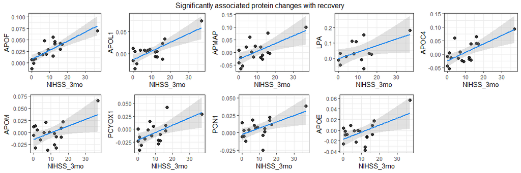

```r
ggplotRegression <- function (fit) {
  ggplot(fit$model, aes_string(x = names(fit$model)[2],
                             y = names(fit$model)[1])) +
     geom_point(size=2, alpha=0.8) +
     theme_bw() +
     stat_smooth(method = "lm", col = "Dodgerblue2", alpha=0.3)

}

r1 <- ggplotRegression(lm(APOF ~ NIHSS_3mo, data=lfc_df))
r2 <- ggplotRegression(lm(APOL1 ~ NIHSS_3mo, data=lfc_df))
r3 <- ggplotRegression(lm(APMAP ~ NIHSS_3mo, data=lfc_df))
r4 <- ggplotRegression(lm(LPA ~ NIHSS_3mo, data=lfc_df))
r5 <- ggplotRegression(lm(APOC4 ~ NIHSS_3mo, data=lfc_df))
r6 <- ggplotRegression(lm(APOM ~ NIHSS_3mo, data=lfc_df))
r7 <- ggplotRegression(lm(PCYOX1 ~ NIHSS_3mo, data=lfc_df))
r8 <- ggplotRegression(lm(PON1 ~ NIHSS_3mo, data=lfc_df))
r9 <- ggplotRegression(lm(APOE ~ NIHSS_3mo, data=lfc_df))
r10 <- ggplotRegression(lm(PPBP ~ NIHSS_3mo, data=lfc_df))

grid.arrange(r1, r2, r3, r4, r5, r6, r7, r8, r9,
             top = "Significantly associated protein changes with recovery",
             ncol = 5)
```

## Supplemental Figure 5.

Visualization of the linear regression of plasma lipid measures and stroke severity and recovery scores.

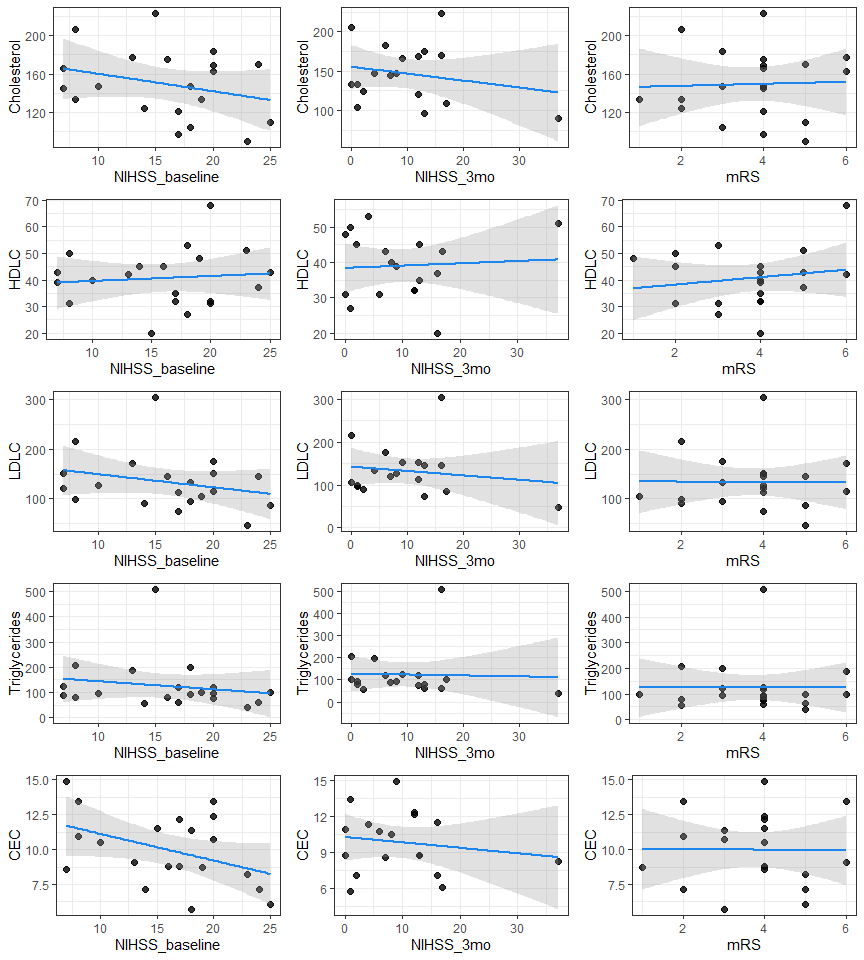

```r
ch1 <- ggplotRegression(lm(Cholesterol ~ NIHSS_baseline, data=lfc_df))
ch2 <- ggplotRegression(lm(Cholesterol ~ NIHSS_3mo, data=lfc_df))
ch3 <- ggplotRegression(lm(Cholesterol ~ mRS, data=lfc_df))
h1 <- ggplotRegression(lm(HDLC ~ NIHSS_baseline, data=lfc_df))
h2 <- ggplotRegression(lm(HDLC ~ NIHSS_3mo, data=lfc_df))
h3 <- ggplotRegression(lm(HDLC ~ mRS, data=lfc_df))
l1 <- ggplotRegression(lm(LDLC ~ NIHSS_baseline, data=lfc_df))
l2 <- ggplotRegression(lm(LDLC ~ NIHSS_3mo, data=lfc_df))
l3 <- ggplotRegression(lm(LDLC ~ mRS, data=lfc_df))
t1 <- ggplotRegression(lm(Triglycerides ~ NIHSS_baseline, data=lfc_df))
t2 <- ggplotRegression(lm(Triglycerides ~ NIHSS_3mo, data=lfc_df))
t3 <- ggplotRegression(lm(Triglycerides ~ mRS, data=lfc_df))
ce1 <- ggplotRegression(lm(CEC ~ NIHSS_baseline, data=lfc_df))
ce2 <- ggplotRegression(lm(CEC ~ NIHSS_3mo, data=lfc_df))
ce3 <- ggplotRegression(lm(CEC ~ mRS, data=lfc_df))

grid.arrange(ch1,ch2,ch3,h1,h2,h3,l1,l2,l3,t1,t2,t3,ce1,ce2,ce3, ncol = 3)
```

## Supplemental Table 6.

Table with statistics of linear regressions of plasma lipid measures and stroke severity and recovery scores.

```r
cec_b <- lm_out(lm(CEC ~ NIHSS_baseline, data = lfc_df))
cec_3 <- lm_out(lm(CEC ~ NIHSS_3mo, data = lfc_df))
cec_m <- lm_out(lm(CEC ~ mRS, data = lfc_df))

hdlc_b <- lm_out(lm(HDLC ~ NIHSS_baseline, data = lfc_df))
hdlc_3 <- lm_out(lm(HDLC ~ NIHSS_3mo, data = lfc_df))
hdlc_m <- lm_out(lm(HDLC ~ mRS, data = lfc_df))

ldlc_b <- lm_out(lm(LDLC ~ NIHSS_baseline, data = lfc_df))
ldlc_3 <- lm_out(lm(LDLC ~ NIHSS_3mo, data = lfc_df))
ldlc_m <- lm_out(lm(LDLC ~ mRS, data = lfc_df))

chol_b <- lm_out(lm(Cholesterol ~ NIHSS_baseline, data = lfc_df))
chol_3 <- lm_out(lm(Cholesterol  ~ NIHSS_3mo, data = lfc_df))
chol_m <- lm_out(lm(Cholesterol  ~ mRS, data = lfc_df))

trig_b <- lm_out(lm(Triglycerides ~ NIHSS_baseline, data = lfc_df))
trig_3 <- lm_out(lm(Triglycerides ~ NIHSS_3mo, data = lfc_df))
trig_m <- lm_out(lm(Triglycerides ~ mRS, data = lfc_df))


lm_lipids <- as.data.frame(rbind(cec_b, cec_3, cec_m,
                                 hdlc_b, hdlc_3, hdlc_m,
                                 ldlc_b, ldlc_3, ldlc_m,
                                 chol_b, chol_3, chol_m,
                                 trig_b, trig_3, trig_m))

row.names(lm_lipids) <- c("cec_b", "cec_3", "cec_m",
                          "hdlc_b", "hdlc_3", "hdlc_m",
                          "ldlc_b", "ldlc_3", "ldlc_m",
                          "chol_b", "chol_3", "chol_m",
                          "trig_b", "trig_3", "trig_m")
#write.csv(lm_lipids, file="lm_lipids.csv")

kable((lm_lipids)) %>%
  kable_styling() %>%
  scroll_box(width = "100%", height = "300px")
```

|  | i | se | r2 | p | f | df |
| --- | --- | --- | --- | --- | --- | --- |
| cec_b | 13.03154 | 1.6418388 | 0.1312226 | 0.0647695 | 3.8698151 | 18 |
| cec_3 | 10.27024 | 0.9166501 | -0.0359908 | 0.5313244 | 0.4094116 | 16 |
| cec_m | 10.04931 | 1.7968614 | -0.0554495 | 0.9665424 | 0.0018090 | 18 |
| hdlc_b | 37.58491 | 7.5632716 | -0.0452372 | 0.6783559 | 0.1776914 | 18 |
| hdlc_3 | 38.37018 | 3.2842553 | -0.0580929 | 0.7995816 | 0.0666419 | 16 |
| hdlc_m | 35.37778 | 7.4335169 | -0.0241061 | 0.4667848 | 0.5527644 | 18 |
| ldlc_b | 175.71924 | 38.2922736 | 0.0187504 | 0.2582403 | 1.3630654 | 18 |
| ldlc_3 | 142.23138 | 20.9505274 | -0.0362448 | 0.5333231 | 0.4053896 | 16 |
| ldlc_m | 134.70667 | 39.4337072 | -0.0554878 | 0.9732560 | 0.0011556 | 18 |
| chol_b | 178.18662 | 24.2827204 | 0.0308232 | 0.2214450 | 1.6042662 | 18 |
| chol_3 | 155.24378 | 13.1459087 | -0.0148308 | 0.3987975 | 0.7515610 | 16 |
| chol_m | 145.15556 | 25.1433825 | -0.0539416 | 0.8699886 | 0.0275640 | 18 |
| trig_b | 175.58765 | 70.1964478 | -0.0221870 | 0.4532869 | 0.5875964 | 18 |
| trig_3 | 126.78892 | 38.2253928 | -0.0611397 | 0.8879095 | 0.0205102 | 16 |
| trig_m | 124.64444 | 70.8288325 | -0.0555555 | 0.9993468 | 0.0000007 | 18 |

## Supplemental Table 7. Linear regression statistics for plasma lipid levels and HDL protein Log2FC

### Protein ~ CEC

```r
out_df <- data.frame()

for (i in lfc_df[,25:ncol(lfc_df)]){
  fit <- lm(i ~ CEC, data = lfc_df)
  out <- data.frame(lm_out(fit))
  out_df <- data.frame(rbind(out_df, out))
}

lm_CEC.Prot <- out_df
rownames(lm_CEC.Prot) <- rn[,1]
lm_CEC.Prot$p.adj <- p.adjust(lm_CEC.Prot$p, method = "BH")

kable(lm_CEC.Prot, caption="Model: protein FC ~ CEC") %>%
  kable_styling() %>%
  scroll_box(width = "100%", height = "300px")
```

Model: protein FC ~ CEC

|  | i | se | r2 | p | f | df | p.adj |
| --- | --- | --- | --- | --- | --- | --- | --- |
| SERPINA1 | 0.0779021 | 0.0391957 | 0.0494306 | 0.1755938 | 1.9880197 | 18 | 0.8039673 |
| ALB | 0.0699900 | 0.0538070 | 0.0135398 | 0.2762563 | 1.2607876 | 18 | 0.8510934 |
| AMBP | 0.0165648 | 0.0323453 | -0.0520875 | 0.8103052 | 0.0593347 | 18 | 0.9715988 |
| ANTXR2 | -0.0496082 | 0.0356342 | -0.0451033 | 0.6763825 | 0.1800216 | 18 | 0.9715988 |
| APMAP | 0.0038084 | 0.0413596 | -0.0554473 | 0.9661985 | 0.0018464 | 18 | 0.9715988 |
| LPA | 0.0394094 | 0.0801729 | -0.0756027 | 0.9014063 | 0.0159584 | 13 | 0.9715988 |
| APOA1 | 0.0092009 | 0.0161757 | -0.0348565 | 0.5559669 | 0.3600336 | 18 | 0.9715988 |
| APOA2 | -0.0096234 | 0.0337279 | -0.0553887 | 0.9580387 | 0.0028465 | 18 | 0.9715988 |
| APOA4 | 0.0241574 | 0.0386544 | -0.0227962 | 0.4575068 | 0.5765251 | 18 | 0.9559702 |
| APOB | -0.0262709 | 0.0454338 | -0.0375938 | 0.5835790 | 0.3115973 | 18 | 0.9715988 |
| APOC3 | -0.0241311 | 0.0264288 | -0.0218936 | 0.4512749 | 0.5929345 | 18 | 0.9559702 |
| APOC4 | 0.0773456 | 0.0326758 | 0.1771433 | 0.0367370 | 5.0902913 | 18 | 0.4653358 |
| APOD | 0.0029549 | 0.0150714 | -0.0554791 | 0.9715988 | 0.0013033 | 18 | 0.9715988 |
| APOE | 0.0125890 | 0.0187469 | -0.0146956 | 0.4057493 | 0.7248275 | 18 | 0.9559702 |
| APOF | 0.0427291 | 0.0239833 | -0.0141270 | 0.4024356 | 0.7353267 | 18 | 0.9559702 |
| APOL1 | -0.0014935 | 0.0221411 | -0.0462312 | 0.6934822 | 0.1604221 | 18 | 0.9715988 |
| APOM | 0.0014112 | 0.0220518 | -0.0552125 | 0.9398662 | 0.0058521 | 18 | 0.9715988 |
| CAMP | 0.0418872 | 0.0257649 | 0.0379505 | 0.2024987 | 1.7495045 | 18 | 0.8039673 |
| CLU | 0.0076901 | 0.0316581 | -0.0505627 | 0.7732624 | 0.0855460 | 18 | 0.9715988 |
| C3 | 0.0534084 | 0.0291147 | 0.0344501 | 0.2115703 | 1.6779057 | 18 | 0.8039673 |
| PPBP | 0.1638576 | 0.0431242 | 0.3242193 | 0.0051797 | 10.1156297 | 18 | 0.1968268 |
| AHSG | 0.0819470 | 0.0749594 | 0.0085807 | 0.2947942 | 1.1644439 | 18 | 0.8510934 |
| FGA | 0.0966391 | 0.0622115 | 0.1193409 | 0.0748733 | 3.5747504 | 18 | 0.7112967 |
| HPR | 0.0103599 | 0.0488062 | -0.0536973 | 0.8605806 | 0.0317440 | 18 | 0.9715988 |
| IHH | -0.0292633 | 0.0218049 | 0.0039287 | 0.3135607 | 1.0749401 | 18 | 0.8510934 |
| ITIH4 | -0.0259670 | 0.0713428 | -0.0567283 | 0.8565044 | 0.0337066 | 17 | 0.9715988 |
| LCAT | 0.0266037 | 0.0385518 | -0.0524089 | 0.8191635 | 0.0538189 | 18 | 0.9715988 |
| SELL | 0.0567286 | 0.0367219 | 0.0578860 | 0.1582331 | 2.1674104 | 18 | 0.8039673 |
| PCYOX1 | -0.0038018 | 0.0204652 | -0.0550794 | 0.9291828 | 0.0081226 | 18 | 0.9715988 |
| GPLD1 | -0.0155150 | 0.0381950 | -0.0451839 | 0.6775677 | 0.1786199 | 18 | 0.9715988 |
| PF4 | 0.1536059 | 0.0495389 | 0.2456271 | 0.0152621 | 7.1864823 | 18 | 0.2899802 |
| PLTP | -0.0348875 | 0.0220580 | 0.0349203 | 0.2103263 | 1.6874923 | 18 | 0.8039673 |
| PON1 | 0.0096549 | 0.0144388 | -0.0544844 | 0.8939372 | 0.0182849 | 18 | 0.9715988 |
| PON3 | -0.0008887 | 0.0200831 | -0.0512740 | 0.7896597 | 0.0733083 | 18 | 0.9715988 |
| RBP4 | 0.0229026 | 0.0415556 | -0.0480433 | 0.7236273 | 0.1290221 | 18 | 0.9715988 |
| SAA1 | 0.2625887 | 0.1340848 | 0.0260088 | 0.2454236 | 1.4539571 | 16 | 0.8478270 |
| SAA2 | 0.1767261 | 0.1171787 | -0.0256350 | 0.4779851 | 0.5251089 | 18 | 0.9559702 |
| TTR | 0.0590932 | 0.0407263 | 0.0507315 | 0.1727963 | 2.0154122 | 18 | 0.8039673 |

```r
#write.csv(lm_CEC.Prot, file="lm_CEC_prot.csv")
```

### Protein ~ HDLC

```r
out_df <- data.frame()

for (i in lfc_df[,25:ncol(lfc_df)]){
  fit <- lm(i ~ HDLC, data = lfc_df)
  out <- data.frame(lm_out(fit))
  out_df <- data.frame(rbind(out_df, out))
}

lm_HDLC.Prot <- out_df
rownames(lm_HDLC.Prot) <- rn[,1]
lm_HDLC.Prot$p.adj <- p.adjust(lm_HDLC.Prot$p, method = "BH")

kable(lm_HDLC.Prot, caption="Model: protein FC ~ HDLC") %>%
  kable_styling() %>%
  scroll_box(width = "100%", height = "300px")
```

Model: protein FC ~ HDLC

|  | i | se | r2 | p | f | df | p.adj |
| --- | --- | --- | --- | --- | --- | --- | --- |
| SERPINA1 | -0.0201788 | 0.0386085 | 0.0213724 | 0.2496919 | 1.4149449 | 18 | 0.3953455 |
| ALB | -0.0832703 | 0.0488755 | 0.1363653 | 0.0608202 | 4.0000430 | 18 | 0.3301674 |
| AMBP | -0.0475301 | 0.0282915 | 0.1459415 | 0.0540785 | 4.2467204 | 18 | 0.3301674 |
| ANTXR2 | -0.0871811 | 0.0323568 | 0.0856739 | 0.1127320 | 2.7803326 | 18 | 0.3301674 |
| APMAP | 0.0334864 | 0.0395729 | -0.0252407 | 0.4750565 | 0.5322340 | 18 | 0.6943134 |
| LPA | 0.0220041 | 0.0985482 | -0.0764023 | 0.9379984 | 0.0062892 | 13 | 0.9379984 |
| APOA1 | -0.0032976 | 0.0158418 | -0.0531924 | 0.8429757 | 0.0403888 | 18 | 0.9152308 |
| APOA2 | -0.0051558 | 0.0327387 | -0.0551234 | 0.9325205 | 0.0073730 | 18 | 0.9379984 |
| APOA4 | -0.0514782 | 0.0363519 | 0.0401805 | 0.1969421 | 1.7953895 | 18 | 0.3563715 |
| APOB | -0.0695093 | 0.0413081 | 0.0899085 | 0.1070780 | 2.8770225 | 18 | 0.3301674 |
| APOC3 | -0.0552428 | 0.0229503 | 0.1823442 | 0.0344204 | 5.2371626 | 18 | 0.3301674 |
| APOC4 | -0.0110141 | 0.0356933 | -0.0418125 | 0.6319377 | 0.2374469 | 18 | 0.8004544 |
| APOD | 0.0013342 | 0.0146224 | -0.0542070 | 0.8810760 | 0.0230265 | 18 | 0.9300247 |
| APOE | -0.0306107 | 0.0172926 | 0.0838992 | 0.1151904 | 2.7400757 | 18 | 0.3301674 |
| APOF | 0.0581788 | 0.0221353 | 0.0833746 | 0.1159275 | 2.7282053 | 18 | 0.3301674 |
| APOL1 | -0.0355506 | 0.0189285 | 0.1886539 | 0.0317955 | 5.4178724 | 18 | 0.3301674 |
| APOM | -0.0255403 | 0.0205053 | 0.0318811 | 0.2185129 | 1.6256888 | 18 | 0.3774314 |
| CAMP | -0.0271609 | 0.0246917 | 0.0624597 | 0.1496045 | 2.2657966 | 18 | 0.3511419 |
| CLU | -0.0525070 | 0.0281711 | 0.1173166 | 0.0767420 | 3.5252716 | 18 | 0.3301674 |
| C3 | -0.0207994 | 0.0280975 | 0.0458149 | 0.1836263 | 1.9122791 | 18 | 0.3511419 |
| PPBP | 0.0196052 | 0.0522512 | -0.0526922 | 0.8273727 | 0.0489605 | 18 | 0.9152308 |
| AHSG | -0.1314570 | 0.0675217 | 0.1464348 | 0.0537515 | 4.2595770 | 18 | 0.3301674 |
| FGA | -0.1048661 | 0.0626041 | 0.0537263 | 0.1665348 | 2.0787582 | 18 | 0.3511419 |
| HPR | -0.0411157 | 0.0462507 | -0.0040332 | 0.3492451 | 0.9236770 | 18 | 0.5308525 |
| IHH | -0.0388759 | 0.0203932 | 0.0755167 | 0.1275594 | 2.5520207 | 18 | 0.3301674 |
| ITIH4 | 0.0052287 | 0.0680526 | -0.0539213 | 0.7819492 | 0.0790747 | 17 | 0.9004263 |
| LCAT | -0.0390296 | 0.0348231 | 0.0888809 | 0.1084233 | 2.8534747 | 18 | 0.3301674 |
| SELL | 0.0187182 | 0.0375707 | -0.0464006 | 0.6961509 | 0.1574822 | 18 | 0.8266792 |
| PCYOX1 | -0.0308242 | 0.0188988 | 0.0452958 | 0.1848115 | 1.9014516 | 18 | 0.3511419 |
| GPLD1 | 0.0161327 | 0.0370593 | -0.0440413 | 0.6612358 | 0.1985134 | 18 | 0.8105471 |
| PF4 | -0.0043681 | 0.0564440 | -0.0391425 | 0.6004146 | 0.2843066 | 18 | 0.7965301 |
| PLTP | -0.0432881 | 0.0205887 | 0.1078619 | 0.0860956 | 3.2971517 | 18 | 0.3301674 |
| PON1 | -0.0081322 | 0.0134800 | 0.0247751 | 0.2390774 | 1.4826846 | 18 | 0.3949974 |
| PON3 | -0.0054182 | 0.0193898 | -0.0398012 | 0.6078783 | 0.2727238 | 18 | 0.7965301 |
| RBP4 | -0.0746266 | 0.0350776 | 0.2076371 | 0.0249909 | 5.9789112 | 18 | 0.3301674 |
| SAA1 | 0.2659861 | 0.1165678 | 0.0576632 | 0.1724136 | 2.0402600 | 16 | 0.3511419 |
| SAA2 | 0.1575315 | 0.1143744 | -0.0368077 | 0.5753851 | 0.3254819 | 18 | 0.7965301 |
| TTR | -0.0569407 | 0.0390545 | 0.0737535 | 0.1303292 | 2.5128980 | 18 | 0.3301674 |

```r
#write.csv(lm_HDLC.Prot, file="lm_HDLC_prot.csv")
```

### Protein ~ LDLC

```r
out_df <- data.frame()

for (i in lfc_df[,25:ncol(lfc_df)]){
  fit <- lm(i ~ LDLC, data = lfc_df)
  out <- data.frame(lm_out(fit))
  out_df <- data.frame(rbind(out_df, out))
}

lm_LDLC.Prot <- out_df
rownames(lm_LDLC.Prot) <- rn[,1]
lm_LDLC.Prot$p.adj <- p.adjust(lm_LDLC.Prot$p, method = "BH")

kable(lm_LDLC.Prot, caption="Model: protein FC ~ LDLC") %>%
  kable_styling() %>%
  scroll_box(width = "100%", height = "300px")
```

Model: protein FC ~ LDLC

|  | i | se | r2 | p | f | df | p.adj |
| --- | --- | --- | --- | --- | --- | --- | --- |
| SERPINA1 | 0.0356560 | 0.0262373 | -0.0428495 | 0.6451859 | 0.2193116 | 18 | 0.9681671 |
| ALB | 0.0356063 | 0.0350317 | -0.0237694 | 0.4643724 | 0.5588667 | 18 | 0.9681671 |
| AMBP | 0.0169871 | 0.0206034 | -0.0451582 | 0.6771894 | 0.1790666 | 18 | 0.9681671 |
| ANTXR2 | -0.0200022 | 0.0225684 | -0.0263643 | 0.4834766 | 0.5119458 | 18 | 0.9681671 |
| APMAP | -0.0209638 | 0.0255573 | 0.0132877 | 0.2771647 | 1.2558665 | 18 | 0.9681671 |
| LPA | 0.0481044 | 0.0785289 | -0.0720100 | 0.8109708 | 0.0595801 | 13 | 0.9681671 |
| APOA1 | 0.0059977 | 0.0103200 | -0.0312943 | 0.5234407 | 0.4234507 | 18 | 0.9681671 |
| APOA2 | -0.0126770 | 0.0215221 | -0.0521593 | 0.8122461 | 0.0581017 | 18 | 0.9681671 |
| APOA4 | -0.0105100 | 0.0250465 | -0.0513811 | 0.7922495 | 0.0714686 | 18 | 0.9681671 |
| APOB | 0.0416785 | 0.0271245 | 0.0945414 | 0.1012185 | 2.9838427 | 18 | 0.6718986 |
| APOC3 | -0.0014635 | 0.0171502 | -0.0535663 | 0.8557976 | 0.0339860 | 18 | 0.9681671 |
| APOC4 | 0.0087796 | 0.0236400 | -0.0544875 | 0.8940917 | 0.0182314 | 18 | 0.9681671 |
| APOD | -0.0106196 | 0.0089371 | 0.0913140 | 0.1052652 | 2.9093140 | 18 | 0.6718986 |
| APOE | 0.0067822 | 0.0119685 | -0.0125879 | 0.3936519 | 0.7638037 | 18 | 0.9681671 |
| APOF | 0.0221217 | 0.0156365 | -0.0554349 | 0.9643253 | 0.0020569 | 18 | 0.9681671 |
| APOL1 | 0.0220569 | 0.0136934 | 0.0202252 | 0.2533916 | 1.3922109 | 18 | 0.9681671 |
| APOM | 0.0066617 | 0.0139857 | -0.0391979 | 0.6010351 | 0.2833319 | 18 | 0.9681671 |
| CAMP | 0.0283302 | 0.0165164 | 0.0320580 | 0.2180269 | 1.6292750 | 18 | 0.9681671 |
| CLU | 0.0003206 | 0.0202762 | -0.0551220 | 0.9324118 | 0.0073969 | 18 | 0.9681671 |
| C3 | 0.0344130 | 0.0189315 | 0.0004631 | 0.3285017 | 1.0088032 | 18 | 0.9681671 |
| PPBP | 0.0897848 | 0.0309932 | 0.1453785 | 0.0544540 | 4.2320649 | 18 | 0.6718986 |
| AHSG | 0.0517620 | 0.0478757 | 0.0098256 | 0.2900046 | 1.1885380 | 18 | 0.9681671 |
| FGA | 0.0106171 | 0.0429359 | -0.0270283 | 0.4885641 | 0.4999773 | 18 | 0.9681671 |
| HPR | -0.0436825 | 0.0289760 | 0.0906722 | 0.1060892 | 2.8945542 | 18 | 0.6718986 |
| IHH | -0.0041576 | 0.0143225 | -0.0522010 | 0.8133821 | 0.0573865 | 18 | 0.9681671 |
| ITIH4 | -0.0065644 | 0.0453032 | -0.0572237 | 0.8744659 | 0.0257243 | 17 | 0.9681671 |
| LCAT | 0.0218790 | 0.0246543 | -0.0537982 | 0.8643839 | 0.0300175 | 18 | 0.9681671 |
| SELL | 0.0096709 | 0.0248034 | -0.0523308 | 0.8169688 | 0.0551590 | 18 | 0.9681671 |
| PCYOX1 | -0.0033631 | 0.0130697 | -0.0535681 | 0.8558633 | 0.0339547 | 18 | 0.9681671 |
| GPLD1 | -0.0462463 | 0.0214956 | 0.1894973 | 0.0314594 | 5.4422410 | 18 | 0.6718986 |
| PF4 | 0.0924692 | 0.0332422 | 0.1683331 | 0.0410029 | 4.8456857 | 18 | 0.6718986 |
| PLTP | -0.0137679 | 0.0146445 | -0.0414964 | 0.6280196 | 0.2429826 | 18 | 0.9681671 |
| PON1 | 0.0033247 | 0.0091629 | -0.0397360 | 0.6071315 | 0.2738687 | 18 | 0.9681671 |
| PON3 | -0.0004125 | 0.0128027 | -0.0460157 | 0.6901271 | 0.1641632 | 18 | 0.9681671 |
| RBP4 | 0.0265429 | 0.0262499 | -0.0238831 | 0.4651847 | 0.5568060 | 18 | 0.9681671 |
| SAA1 | 0.1450677 | 0.0812280 | -0.0439621 | 0.6013416 | 0.2841166 | 16 | 0.9681671 |
| SAA2 | 0.0971948 | 0.0759688 | -0.0554595 | 0.9681671 | 0.0016375 | 18 | 0.9681671 |
| TTR | 0.0232381 | 0.0269577 | -0.0183148 | 0.4277679 | 0.6582766 | 18 | 0.9681671 |

```r
#write.csv(lm_LDLC.Prot, file="lm_LDLC_prot.csv")
```

### Protein ~ Cholesterol

```r
out_df <- data.frame()

for (i in lfc_df[,25:ncol(lfc_df)]){
  fit <- lm(i ~ Cholesterol, data = lfc_df)
  out <- data.frame(lm_out(fit))
  out_df <- data.frame(rbind(out_df, out))
}

lm_Chol.Prot <- out_df
rownames(lm_Chol.Prot) <- rn[,1]
lm_Chol.Prot$p.adj <- p.adjust(lm_Chol.Prot$p, method = "BH")

kable(lm_Chol.Prot, caption="Model: protein FC ~ Cholesterol") %>%
  kable_styling() %>%
  scroll_box(width = "100%", height = "300px")
```

Model: protein FC ~ Cholesterol

|  | i | se | r2 | p | f | df | p.adj |
| --- | --- | --- | --- | --- | --- | --- | --- |
| SERPINA1 | 0.0309864 | 0.0438915 | -0.0541171 | 0.8772047 | 0.0245633 | 18 | 0.9511123 |
| ALB | 0.0339686 | 0.0589340 | -0.0465438 | 0.6984293 | 0.1549974 | 18 | 0.9511123 |
| AMBP | 0.0121426 | 0.0344432 | -0.0550147 | 0.9245350 | 0.0092274 | 18 | 0.9511123 |
| ANTXR2 | -0.0195548 | 0.0378991 | -0.0454572 | 0.6816283 | 0.1738670 | 18 | 0.9511123 |
| APMAP | -0.0161707 | 0.0436683 | -0.0404928 | 0.6159262 | 0.2605784 | 18 | 0.9511123 |
| LPA | 0.0266968 | 0.1064127 | -0.0768572 | 0.9779298 | 0.0007953 | 13 | 0.9779298 |
| APOA1 | 0.0113707 | 0.0171442 | -0.0280408 | 0.4964888 | 0.4817567 | 18 | 0.9511123 |
| APOA2 | -0.0176353 | 0.0357905 | -0.0509773 | 0.7826549 | 0.0784111 | 18 | 0.9511123 |
| APOA4 | -0.0324890 | 0.0411967 | -0.0273949 | 0.4914097 | 0.4933759 | 18 | 0.9511123 |
| APOB | 0.0580168 | 0.0465384 | 0.0372473 | 0.2042865 | 1.7350779 | 18 | 0.9511123 |
| APOC3 | -0.0157060 | 0.0284313 | -0.0458432 | 0.6874720 | 0.1671596 | 18 | 0.9511123 |
| APOC4 | 0.0206517 | 0.0391905 | -0.0467767 | 0.7021790 | 0.1509578 | 18 | 0.9511123 |
| APOD | -0.0192057 | 0.0150567 | 0.0684163 | 0.1390963 | 2.3953771 | 18 | 0.9511123 |
| APOE | 0.0122269 | 0.0200002 | -0.0213392 | 0.4475104 | 0.6030270 | 18 | 0.9511123 |
| APOF | 0.0338146 | 0.0258815 | -0.0444245 | 0.6666035 | 0.1918362 | 18 | 0.9511123 |
| APOL1 | 0.0214057 | 0.0233945 | -0.0329491 | 0.5381191 | 0.3939366 | 18 | 0.9511123 |
| APOM | 0.0110104 | 0.0232950 | -0.0413575 | 0.6263154 | 0.2454154 | 18 | 0.9511123 |
| CAMP | 0.0237802 | 0.0284692 | -0.0387599 | 0.5961656 | 0.2910406 | 18 | 0.9511123 |
| CLU | 0.0020880 | 0.0337346 | -0.0549346 | 0.9191572 | 0.0105944 | 18 | 0.9511123 |
| C3 | 0.0516383 | 0.0312543 | 0.0160072 | 0.2675481 | 1.3090852 | 18 | 0.9511123 |
| PPBP | 0.1543161 | 0.0488934 | 0.2317773 | 0.0183025 | 6.7324102 | 18 | 0.3477483 |
| AHSG | 0.0678416 | 0.0807587 | -0.0176691 | 0.4237170 | 0.6701154 | 18 | 0.9511123 |
| FGA | 0.0347716 | 0.0713135 | -0.0233703 | 0.4615379 | 0.5661044 | 18 | 0.9511123 |
| HPR | -0.0857394 | 0.0474123 | 0.1206325 | 0.0737044 | 3.6064398 | 18 | 0.9335889 |
| IHH | -0.0153616 | 0.0237899 | -0.0485544 | 0.7328530 | 0.1201857 | 18 | 0.9511123 |
| ITIH4 | 0.0254078 | 0.0743213 | -0.0412809 | 0.5994668 | 0.2864021 | 17 | 0.9511123 |
| LCAT | 0.0104952 | 0.0410171 | -0.0535283 | 0.8544414 | 0.0346362 | 18 | 0.9511123 |
| SELL | 0.0452826 | 0.0401240 | 0.0053155 | 0.3078178 | 1.1015341 | 18 | 0.9511123 |
| PCYOX1 | -0.0076837 | 0.0217613 | -0.0549838 | 0.9224162 | 0.0097546 | 18 | 0.9511123 |
| GPLD1 | -0.0613655 | 0.0380036 | 0.0849363 | 0.1137472 | 2.7635823 | 18 | 0.9511123 |
| PF4 | 0.1613506 | 0.0528181 | 0.2416294 | 0.0160876 | 7.0537140 | 18 | 0.3477483 |
| PLTP | -0.0287797 | 0.0239624 | -0.0071916 | 0.3648297 | 0.8643349 | 18 | 0.9511123 |
| PON1 | -0.0059185 | 0.0150005 | -0.0065007 | 0.3613444 | 0.8772841 | 18 | 0.9511123 |
| PON3 | -0.0102774 | 0.0211029 | -0.0265072 | 0.4845641 | 0.5093693 | 18 | 0.9511123 |
| RBP4 | 0.0191487 | 0.0442715 | -0.0519363 | 0.8062871 | 0.0619309 | 18 | 0.9511123 |
| SAA1 | 0.2108644 | 0.1328598 | -0.0198253 | 0.4252376 | 0.6695211 | 16 | 0.9511123 |
| SAA2 | 0.0827745 | 0.1263789 | -0.0550367 | 0.9260830 | 0.0088515 | 18 | 0.9511123 |
| TTR | 0.0303569 | 0.0451851 | -0.0333622 | 0.5418967 | 0.3865829 | 18 | 0.9511123 |

```r
#write.csv(lm_Chol.Prot, file="lm_Chol_prot.csv")
```

### Protein ~ Triglycerides

```r
out_df <- data.frame()

for (i in lfc_df[,25:ncol(lfc_df)]){
  fit <- lm(i ~ Triglycerides, data = lfc_df)
  out <- data.frame(lm_out(fit))
  out_df <- data.frame(rbind(out_df, out))
}

lm_Tri.Prot <- out_df
rownames(lm_Tri.Prot) <- rn[,1]
lm_Tri.Prot$p.adj <- p.adjust(lm_Tri.Prot$p, method = "BH")

kable(lm_Tri.Prot, caption="Model: protein FC ~ Triglycerides") %>%
  kable_styling() %>%
  scroll_box(width = "100%", height = "300px")
```

Model: protein FC ~ Triglycerides

|  | i | se | r2 | p | f | df | p.adj |
| --- | --- | --- | --- | --- | --- | --- | --- |
| SERPINA1 | 0.0294655 | 0.0161079 | -0.0458212 | 0.6871355 | 0.1675416 | 18 | 0.9915227 |
| ALB | 0.0180462 | 0.0217153 | -0.0466624 | 0.7003322 | 0.1529397 | 18 | 0.9915227 |
| AMBP | 0.0090616 | 0.0126936 | -0.0555439 | 0.9889268 | 0.0001980 | 18 | 0.9915227 |
| ANTXR2 | -0.0305318 | 0.0139685 | -0.0461625 | 0.6924082 | 0.1616141 | 18 | 0.9915227 |
| APMAP | -0.0165170 | 0.0147919 | 0.1205552 | 0.0737739 | 3.6045393 | 18 | 0.6133293 |
| LPA | 0.0780910 | 0.0524074 | 0.0004454 | 0.3341126 | 1.0062379 | 13 | 0.9915227 |
| APOA1 | 0.0021315 | 0.0063618 | -0.0427717 | 0.6441700 | 0.2206708 | 18 | 0.9915227 |
| APOA2 | -0.0092046 | 0.0132096 | -0.0545965 | 0.8996121 | 0.0163696 | 18 | 0.9915227 |
| APOA4 | -0.0066410 | 0.0153695 | -0.0533822 | 0.8493417 | 0.0371381 | 18 | 0.9915227 |
| APOB | 0.0177875 | 0.0169778 | 0.0561378 | 0.1616676 | 2.1300566 | 18 | 0.9915227 |
| APOC3 | -0.0030451 | 0.0105162 | -0.0540056 | 0.8725695 | 0.0264704 | 18 | 0.9915227 |
| APOC4 | -0.0006567 | 0.0143688 | -0.0365370 | 0.5726152 | 0.3302673 | 18 | 0.9915227 |
| APOD | -0.0053435 | 0.0052773 | 0.1569617 | 0.0472102 | 4.5375282 | 18 | 0.6133293 |
| APOE | -0.0016916 | 0.0074827 | -0.0531026 | 0.8400577 | 0.0419264 | 18 | 0.9915227 |
| APOF | 0.0221746 | 0.0095849 | -0.0551790 | 0.9370047 | 0.0064235 | 18 | 0.9915227 |
| APOL1 | 0.0137767 | 0.0084805 | 0.0001372 | 0.3299519 | 1.0026076 | 18 | 0.9915227 |
| APOM | -0.0005936 | 0.0086406 | -0.0553828 | 0.9573037 | 0.0029472 | 18 | 0.9915227 |
| CAMP | 0.0229094 | 0.0096919 | 0.1131831 | 0.0807012 | 3.4249413 | 18 | 0.6133293 |
| CLU | -0.0096693 | 0.0121761 | -0.0123744 | 0.3924547 | 0.7677595 | 18 | 0.9915227 |
| C3 | 0.0173666 | 0.0119258 | -0.0553573 | 0.9542696 | 0.0033815 | 18 | 0.9915227 |
| PPBP | 0.0490938 | 0.0203898 | 0.0158416 | 0.2681224 | 1.3058358 | 18 | 0.9915227 |
| AHSG | 0.0159183 | 0.0300730 | -0.0395193 | 0.6046608 | 0.2776789 | 18 | 0.9915227 |
| FGA | -0.0195974 | 0.0266775 | -0.0549504 | 0.9201883 | 0.0103249 | 18 | 0.9915227 |
| HPR | -0.0253704 | 0.0172963 | 0.1379170 | 0.0596752 | 4.0396411 | 18 | 0.6133293 |
| IHH | -0.0039960 | 0.0087373 | -0.0418695 | 0.6326498 | 0.2364493 | 18 | 0.9915227 |
| ITIH4 | -0.0209425 | 0.0280072 | -0.0512458 | 0.7305929 | 0.1225423 | 17 | 0.9915227 |
| LCAT | 0.0176433 | 0.0151269 | -0.0555220 | 0.9811797 | 0.0005722 | 18 | 0.9915227 |
| SELL | -0.0070348 | 0.0148454 | -0.0030272 | 0.3444626 | 0.9426560 | 18 | 0.9915227 |
| PCYOX1 | -0.0056590 | 0.0080200 | -0.0555487 | 0.9915227 | 0.0001161 | 18 | 0.9915227 |
| GPLD1 | -0.0317976 | 0.0115850 | 0.3736102 | 0.0024908 | 12.3325484 | 18 | 0.0946486 |
| PF4 | 0.0456621 | 0.0220862 | 0.0231932 | 0.2439466 | 1.4511349 | 18 | 0.9915227 |
| PLTP | -0.0116262 | 0.0089351 | -0.0315909 | 0.5260204 | 0.4181532 | 18 | 0.9915227 |
| PON1 | 0.0057842 | 0.0056288 | -0.0439537 | 0.6600238 | 0.2000402 | 18 | 0.9915227 |
| PON3 | 0.0034655 | 0.0078797 | -0.0542577 | 0.8833205 | 0.0221588 | 18 | 0.9915227 |
| RBP4 | 0.0145279 | 0.0162366 | -0.0422719 | 0.6377302 | 0.2294078 | 18 | 0.9915227 |
| SAA1 | 0.1358450 | 0.0504026 | -0.0233998 | 0.4457159 | 0.6112988 | 16 | 0.9915227 |
| SAA2 | 0.1155952 | 0.0461366 | -0.0357637 | 0.5648403 | 0.3439516 | 18 | 0.9915227 |
| TTR | 0.0074240 | 0.0167737 | -0.0489912 | 0.7410375 | 0.1126409 | 18 | 0.9915227 |

```r
#write.csv(lm_Tri.Prot, file="lm_Tri_prot.csv")
```

## Supplemental Figure 6. CEC distributions of stroke tPA status

**Distribution of cholesterol efflux capacity at 96 h post stroke with and without tPA treatment**

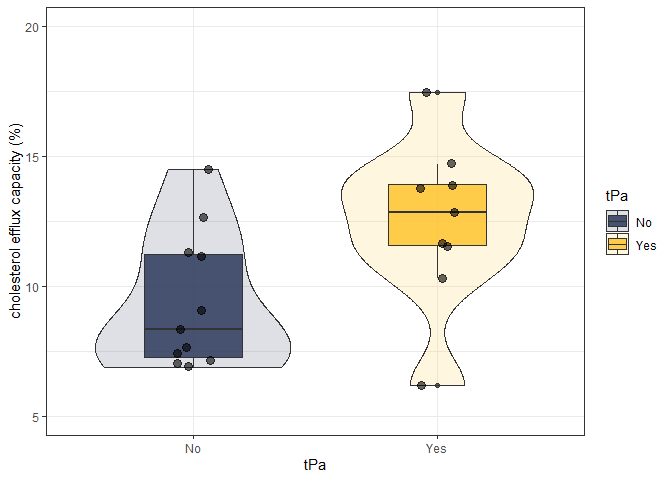

```r
cols <- c("No"="#202f52", "Yes" = "goldenrod1")

ggplot(PS96, aes(x = factor(tPa), y = PS96$CEC, fill = tPa)) +
    geom_violin(alpha=0.15, width=0.8) +
    geom_boxplot(width=0.4, alpha = 0.8) +
    geom_jitter(fill = "black", size = 3, shape = 21,
                position = position_jitter(0.075), alpha=0.6) +
    scale_fill_manual(values=cols) +
    scale_x_discrete(limits=c("No", "Yes")) +
    labs(x="tPa", y="cholesterol efflux capacity (%)") +
    theme_bw() +
    expand_limits(y=c(5,20))
```

**Distribution of cholesterol efflux capacity at 24 h post stroke with and without tPA treatment**

*(Figure not included in manuscript)*

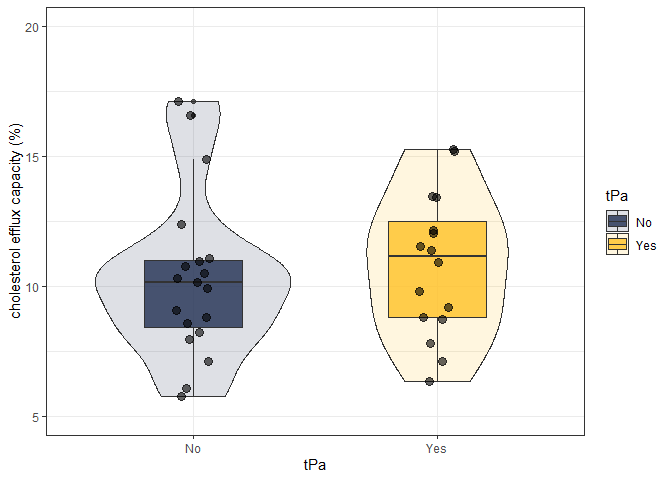

```r
cols <- c("No"="#202f52", "Yes" = "goldenrod1")

ggplot(S24, aes(x = factor(tPa), y = S24$CEC, fill = tPa)) +
    geom_violin(alpha=0.15, width=0.8) +
    geom_boxplot(width=0.4, alpha = 0.8) +
    geom_jitter(fill = "black", size = 3, shape = 21,
                position = position_jitter(0.075), alpha=0.6) +
    scale_fill_manual(values=cols) +
    scale_x_discrete(limits=c("No", "Yes")) +
    labs(x="tPa", y="cholesterol efflux capacity (%)") +
    theme_bw() +
    expand_limits(y=c(5,20))
```

## Supplemental Table 8. T-test statistics for plasma lipid levels by stroke tPA status

**T-test for 24 h post stroke cholesterol efflux capacity with and without tPA**

```r
#I am too lazy to format the output:
t.test(S24$CEC ~ S24$tPa)
```

```
##
##  Welch Two Sample t-test
##
## data:  S24$CEC by S24$tPa
## t = -0.50385, df = 32.952, p-value = 0.6177
## alternative hypothesis: true difference in means is not equal to 0
## 95 percent confidence interval:
##  -2.521311  1.520420
## sample estimates:
##  mean in group No mean in group Yes
##          10.31823          10.81868
```

**T-test for 96 h post stroke cholesterol efflux capacity with and without tPA**

```r
t.test(PS96$CEC ~ PS96$tPa)
```

```
##
##  Welch Two Sample t-test
##
## data:  PS96$CEC by PS96$tPa
## t = -2.3625, df = 15.604, p-value = 0.03151
## alternative hypothesis: true difference in means is not equal to 0
## 95 percent confidence interval:
##  -5.9112956 -0.3138944
## sample estimates:
##  mean in group No mean in group Yes
##          9.374977         12.487572
```

# 8. Additional info for reviewers

## APOA1 differences between groups

APOA1 is the major protein component of HDL particles. Therefore it was of interest to reviewers to know whether APOA1 showed a trend between our sample groups. Although not significant, APOA1 trends slightly higher in both stroke time points, inverse of the plasma HDL-C levels.

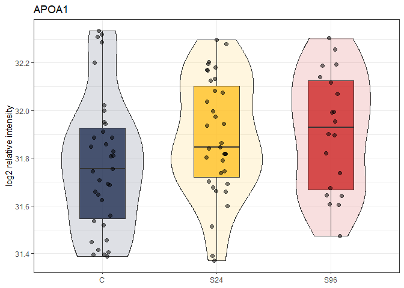

```r
allViolinplot(logAll, logAll$APOA1) +
  ggtitle("APOA1")
```

## Influence of outlier NIHSS on protein & recovery correlations

Since proteins are found to be associated with NIHSS recovery scores, we re-analyzed their relationship after removal of the individual with a very high NIHSS score (=37). The protein APOF still is significantly correlated after removal of the outlier, and after multiple testing correction.

**Statistics without outlier for model: NIHSS_3mo ~ NIHSS_baseline + Protein LFC**

```r
#dataset without the outlier individual
no_out <- data.frame(subset(lfc_df, NIHSS_3mo!=37))

out_df <- data.frame()

for (i in no_out[,25:ncol(no_out)]){
  fit <- lm(NIHSS_3mo ~ NIHSS_baseline + i, data = no_out)
  out <- data.frame(lm_out(fit))
  out_df <- data.frame(rbind(out_df, out))
}

olm_Prot.base <- out_df
rn <- data.frame(colnames(lfc_df[,25:ncol(no_out)]))
rownames(olm_Prot.base) <- rn[,1]
olm_Prot.base$p.adj <- p.adjust(olm_Prot.base$p, method = "BH")

kable(olm_Prot.base) %>%
  kable_styling() %>%
  scroll_box(width = "100%", height = "300px")
```

|  | i | se | r2 | p | f | df | p.adj |
| --- | --- | --- | --- | --- | --- | --- | --- |
| SERPINA1 | 0.8144147 | 4.163289 | 0.0809889 | 0.2174211 | 1.705009 | 14 | 0.2235052 |
| ALB | 0.5539283 | 3.836684 | 0.2110991 | 0.0746816 | 3.140691 | 14 | 0.2235052 |
| AMBP | 0.8680136 | 4.120343 | 0.0878042 | 0.2063824 | 1.770047 | 14 | 0.2235052 |
| ANTXR2 | -0.4904576 | 3.779554 | 0.2623291 | 0.0466761 | 3.844945 | 14 | 0.2235052 |
| APMAP | 2.3133828 | 4.082918 | 0.1691456 | 0.1073324 | 2.628643 | 14 | 0.2235052 |
| LPA | -2.7107679 | 5.016232 | 0.2451942 | 0.1143096 | 2.786642 | 9 | 0.2235052 |
| APOA1 | 1.2727777 | 4.506484 | 0.0797137 | 0.2195417 | 1.692947 | 14 | 0.2235052 |
| APOA2 | 1.1188579 | 4.477085 | 0.0781307 | 0.2221989 | 1.678019 | 14 | 0.2235052 |
| APOA4 | 0.9239649 | 4.158255 | 0.0773938 | 0.2234451 | 1.671089 | 14 | 0.2235052 |
| APOB | 0.8423450 | 4.189520 | 0.0786209 | 0.2213731 | 1.682637 | 14 | 0.2235052 |
| APOC3 | 1.4946210 | 4.524750 | 0.0833480 | 0.2135443 | 1.727412 | 14 | 0.2235052 |
| APOC4 | 4.5943333 | 4.675745 | 0.1908274 | 0.0891959 | 2.886642 | 14 | 0.2235052 |
| APOD | 0.6394007 | 4.076051 | 0.1139508 | 0.1683686 | 2.028844 | 14 | 0.2235052 |
| APOE | 0.9421442 | 4.267120 | 0.0773584 | 0.2235052 | 1.670756 | 14 | 0.2235052 |
| APOF | -3.3333485 | 2.521519 | 0.6927753 | 0.0001014 | 19.039571 | 14 | 0.0038551 |
| APOL1 | 1.4677398 | 3.749809 | 0.2481330 | 0.0533388 | 3.640180 | 14 | 0.2235052 |
| APOM | 0.8796850 | 4.140807 | 0.0805077 | 0.2182193 | 1.700453 | 14 | 0.2235052 |
| CAMP | 0.9913720 | 4.140878 | 0.0807411 | 0.2178318 | 1.702663 | 14 | 0.2235052 |
| CLU | 0.9233404 | 4.133208 | 0.0807599 | 0.2178005 | 1.702841 | 14 | 0.2235052 |
| C3 | 0.3717694 | 4.118828 | 0.1153067 | 0.1665734 | 2.042682 | 14 | 0.2235052 |
| PPBP | 1.8781474 | 4.110813 | 0.1387306 | 0.1380478 | 2.288615 | 14 | 0.2235052 |
| AHSG | -0.0105591 | 3.668521 | 0.2873763 | 0.0366504 | 4.226120 | 14 | 0.2235052 |
| FGA | 0.1593853 | 4.382672 | 0.0937358 | 0.1971696 | 1.827448 | 14 | 0.2235052 |
| HPR | 0.6078341 | 4.205270 | 0.0869776 | 0.2076951 | 1.762107 | 14 | 0.2235052 |
| IHH | 1.5312190 | 4.156768 | 0.1089198 | 0.1751757 | 1.977868 | 14 | 0.2235052 |
| ITIH4 | 2.7590971 | 5.049204 | 0.1826453 | 0.1063426 | 2.675943 | 13 | 0.2235052 |
| LCAT | 0.9306476 | 4.145314 | 0.0773667 | 0.2234910 | 1.670834 | 14 | 0.2235052 |
| SELL | 1.0736540 | 4.160416 | 0.0823612 | 0.2151586 | 1.718027 | 14 | 0.2235052 |
| PCYOX1 | 2.6143496 | 3.699334 | 0.2980753 | 0.0329678 | 4.397234 | 14 | 0.2235052 |
| GPLD1 | -0.2142649 | 4.024293 | 0.1725021 | 0.1043337 | 2.667698 | 14 | 0.2235052 |
| PF4 | 1.7603363 | 4.326166 | 0.0995311 | 0.1885113 | 1.884260 | 14 | 0.2235052 |
| PLTP | 1.3861492 | 4.228634 | 0.0908367 | 0.2016274 | 1.799299 | 14 | 0.2235052 |
| PON1 | 0.7386214 | 4.011571 | 0.1361138 | 0.1410107 | 2.260479 | 14 | 0.2235052 |
| PON3 | 0.5411645 | 4.084948 | 0.1156547 | 0.1661153 | 2.046240 | 14 | 0.2235052 |
| RBP4 | 1.5519329 | 3.810622 | 0.2262034 | 0.0652295 | 3.338634 | 14 | 0.2235052 |
| SAA1 | -2.9595088 | 5.369377 | 0.1582030 | 0.1411118 | 2.315544 | 12 | 0.2235052 |
| SAA2 | 1.4434337 | 3.991002 | 0.1538817 | 0.1219198 | 2.454942 | 14 | 0.2235052 |
| TTR | 0.9657528 | 3.991743 | 0.1425617 | 0.1338063 | 2.330117 | 14 | 0.2235052 |

**Statistics without outlier for model: NIHSS_3mo ~ NIHSS_baseline + tPA + Protein LFC**

```r
out_df <- data.frame()

for (i in no_out[,25:ncol(no_out)]){
  fit <- lm(NIHSS_3mo ~ NIHSS_baseline + i + tPa, data = no_out)
  out <- data.frame(lm_out(fit))
  out_df <- data.frame(rbind(out_df, out))
}

olm_Prot.base <- out_df
rn <- data.frame(colnames(lfc_df[,25:ncol(no_out)]))
rownames(olm_Prot.base) <- rn[,1]
olm_Prot.base$p.adj <- p.adjust(olm_Prot.base$p, method = "BH")

kable(olm_Prot.base) %>%
  kable_styling() %>%
  scroll_box(width = "100%", height = "300px")
```

|  | i | se | r2 | p | f | df | p.adj |
| --- | --- | --- | --- | --- | --- | --- | --- |
| SERPINA1 | 1.1611163 | 4.464745 | 0.0168314 | 0.3875221 | 1.091304 | 13 | 0.3997044 |
| ALB | -0.0615344 | 4.198236 | 0.1626123 | 0.1586143 | 2.035680 | 13 | 0.3997044 |
| AMBP | 0.9809250 | 4.535403 | 0.0180550 | 0.3849668 | 1.098064 | 13 | 0.3997044 |
| ANTXR2 | -0.2929500 | 4.090548 | 0.2073063 | 0.1153354 | 2.394781 | 13 | 0.3997044 |
| APMAP | 2.7137104 | 4.401286 | 0.1122511 | 0.2212869 | 1.674372 | 13 | 0.3997044 |
| LPA | -3.0196796 | 4.326625 | 0.4391587 | 0.0558434 | 3.871130 | 8 | 0.3997044 |
| APOA1 | 1.5085328 | 4.781126 | 0.0128478 | 0.3959191 | 1.069413 | 13 | 0.3997044 |
| APOA2 | 1.3804323 | 4.763326 | 0.0115617 | 0.3986553 | 1.062384 | 13 | 0.3997044 |
| APOA4 | 1.2317363 | 4.474806 | 0.0112491 | 0.3993221 | 1.060678 | 13 | 0.3997044 |
| APOB | 1.1738418 | 4.471922 | 0.0145438 | 0.3923296 | 1.078712 | 13 | 0.3997044 |
| APOC3 | 1.7575707 | 4.822147 | 0.0168739 | 0.3874332 | 1.091539 | 13 | 0.3997044 |
| APOC4 | 6.1070616 | 5.189360 | 0.1627832 | 0.1584279 | 2.036980 | 13 | 0.3997044 |
| APOD | 1.0964344 | 4.367067 | 0.0567413 | 0.3099432 | 1.320824 | 13 | 0.3997044 |
| APOE | 1.2612422 | 4.601103 | 0.0110701 | 0.3997044 | 1.059702 | 13 | 0.3997044 |
| APOF | -4.4405590 | 2.673525 | 0.6995848 | 0.0002819 | 13.419873 | 13 | 0.0107127 |
| APOL1 | 1.7004439 | 4.044498 | 0.1929546 | 0.1280765 | 2.275135 | 13 | 0.3997044 |
| APOM | 1.1760332 | 4.475752 | 0.0138330 | 0.3938314 | 1.074811 | 13 | 0.3997044 |
| CAMP | 1.3601375 | 4.478451 | 0.0160713 | 0.3891152 | 1.087114 | 13 | 0.3997044 |
| CLU | 1.1918348 | 4.472946 | 0.0133243 | 0.3949084 | 1.072023 | 13 | 0.3997044 |
| C3 | 0.4089940 | 4.543170 | 0.0472962 | 0.3272323 | 1.264769 | 13 | 0.3997044 |
| PPBP | 1.8297837 | 4.371577 | 0.0726613 | 0.2822813 | 1.417892 | 13 | 0.3997044 |
| AHSG | -1.1046025 | 4.012901 | 0.2634698 | 0.0747339 | 2.907827 | 13 | 0.3997044 |
| FGA | 0.4954864 | 4.615849 | 0.0340870 | 0.3525216 | 1.188213 | 13 | 0.3997044 |
| HPR | 0.7059121 | 4.857755 | 0.0169048 | 0.3873686 | 1.091709 | 13 | 0.3997044 |
| IHH | 1.7870760 | 4.467451 | 0.0437753 | 0.3338462 | 1.244156 | 13 | 0.3997044 |
| ITIH4 | 3.6680923 | 5.721650 | 0.1255557 | 0.2163271 | 1.717917 | 12 | 0.3997044 |
| LCAT | 1.2520097 | 4.467496 | 0.0114693 | 0.3988522 | 1.061880 | 13 | 0.3997044 |
| SELL | 1.3791919 | 4.484490 | 0.0163140 | 0.3886060 | 1.088451 | 13 | 0.3997044 |
| PCYOX1 | 2.5459895 | 3.958682 | 0.2443703 | 0.0869995 | 2.724798 | 13 | 0.3997044 |
| GPLD1 | 0.2931842 | 4.265244 | 0.1250618 | 0.2038282 | 1.762335 | 13 | 0.3997044 |
| PF4 | 1.8104755 | 4.559238 | 0.0305584 | 0.3594975 | 1.168116 | 13 | 0.3997044 |
| PLTP | 1.5535706 | 4.508899 | 0.0227981 | 0.3751673 | 1.124427 | 13 | 0.3997044 |
| PON1 | 0.9806576 | 4.336050 | 0.0724076 | 0.2827077 | 1.416319 | 13 | 0.3997044 |
| PON3 | 0.9278551 | 4.385091 | 0.0553638 | 0.3124237 | 1.312579 | 13 | 0.3997044 |
| RBP4 | 1.1008838 | 4.074769 | 0.1776615 | 0.1428356 | 2.152236 | 13 | 0.3997044 |
| SAA1 | -3.8299588 | 6.725735 | 0.0861916 | 0.2839599 | 1.440166 | 11 | 0.3997044 |
| SAA2 | 1.5482505 | 4.296471 | 0.0893798 | 0.2551932 | 1.523481 | 13 | 0.3997044 |
| TTR | 0.8328318 | 4.336121 | 0.0773619 | 0.2744642 | 1.447193 | 13 | 0.3997044 |

… I hope you found this document helpful! Sorry for any terrible syntax or poor commenting - feel free to reach out with comments or questions!

-Deanna